# Data preprocessing of gut microbiota cohorts

Author

Mariam Rahali Masbouri

Published

April 9, 2026

In this first section, the relevant datasets are imported from the dysbiotic cohorts (that is, those pertaining to IBD, IBS, CRC, and CDI) as well as the healthy cohorts from the Human Microbiome Project (HMPv13 and HMPv35), NIBIOHN and MORINAGA cohorts, and a “diet intervention” cohort as well. The datasets are available at these following links:

- For **dysbiotic cohorts** (in `01-dysbiotic-cohorts.qmd`):
  - IBD cohort: https://ibdmdb.org/results
  - IBS cohort: https://data.mendeley.com/datasets/29n2z5r5ph/3
  - CRC cohort: https://www.nature.com/articles/s41591-019-0458-7
  - CDI cohort: https://github.com/grp-bork/cdifficile_Ferretti_2022/tree/main/data/CDI
- For **healthy cohorts** (in `02-healthy-cohorts.qmd`):
  - HMPv13 and HMPv35: https://github.com/twbattaglia/MicrobeDS/tree/master/data
  - NIBIOHN and MORINAGA cohorts: https://link.springer.com/article/10.1186/s12866-021-02215-0
  - Diet intervention cohort: https://pubmed.ncbi.nlm.nih.gov/36079725/

Supplementary cohorts will also be used in the analyses, and they will be imported in the third section (see `03-supplementary-cohorts.qmd`):

Other available datasets: - Available in `curatedMetagenomicData` package

- HallAB_2017 (IBD, healthy)
- IaniroG_2022 (IBD, CDI, healthy)
- LiJ_2014 (IBD, healthy)
- NielsenHB_2014 (IBD, healthy)
- FengQ_2015 (CRC, healthy)
- GuptaA_2019 (CRC, healthy)
- HanniganGD_2017 (CRC, healthy)
- ThomasAM_2018a (CRC, healthy)
- ThomasAM_2018b (CRC, healthy)
- ThomasAM_2019_c (CRC, healthy)
- VogtmannE_2016 (CRC, healthy)
- WirbelJ_2018 (CRC, healthy)
- YuJ_2015 (CRC, healthy)
- VincentC_2016 (CDI, healthy)
- Available using `MGnifyR` package

> TODO: To complete

The final output will be a MAE (MultiAssayExperiment) object, containing data that has been cleaned for the downstream analyses.

# Dysbiotic cohorts

In this section, we will first import the relevant datasets from the dysbiotic cohorts (that is, those pertaining to IBD, IBS, CRC, and CDI), and then perform several descriptive analyses for each of those datasets. The analyses will include: data cleaning, taxonomic aggregation (if necessary) and rarefaction.

We will transform each dataset into a `phyloseq` object, before merging them into a `MultiAssayExperiment` object in the last section. For this we need:

- abundance data, a matrix of relative abundance with samples as rows and features (taxa) as columns.
- taxonomy data, a data frame with features (taxa) as rows and taxonomic levels as columns.
- samples data, a data frame with samples as rows and metadata variables as columns.

> TODO: Create dictionaries for metadata variables for each dataset, to keep track of the meaning of each variable and the values they can take, previous and new name, and if it is kept for further analysis or not.

## IBD dataset (Lloyd-Price et al. 2019)

The inflammatory bowel disease (IBD) dataset was obtained from the [IBDMDB](https://ibdmdb.org/), with the results published in Lloyd-Price et al. (2019). The authors of the Science paper did not provide information to which study name the IBD dataset comes from, so the HMP2 study was chosen, which seems like a reasonable choice since it is the most recent study on this page.

Stool samples were initially collected from 132 participants at multiple time points. Specifically, samples were collected at baseline (that is after the initial colonoscopy, which was used to stratify participants into healthy controls, Crohn’s disease (CD) patients, and ulcerative colitis (UC) patients), and then every 2 weeks for 1 years.

Metagenomics (MGX) were performed on 1638 stool samples; DNA was quantified, normalized, and used to prepare sequencing libraries with the Nextera XT kit. Libraries were pooled, quality-checked, and sequenced on an Illumina HiSeq platform to generate ~10 million paired-end reads per sample. Raw sequencing data was then demultiplexed and converted to standard file formats (BAM and FASTQ files) using the Picard suite.

For the analyses, we have the following datasets at our disposal:

- `hmp2_metadata.csv`: contains the metadata for the samples.

From Metagenomics (MGX) and products sections, we have the following file available:

- `taxonomic_profiles.biom.gz`: contains the taxonomic profiles and **relative abundance metagenomics data** for **stool samples**, in BIOM format.

### Importing raw data

In the chunks below, we import the metadata and taxonomic profile for the IBD dataset.

```r
# Importing the metadata

metadata <- read_csv(file.path(data_dir(), "01-raw-data/01-IBD", "hmp2_metadata_2018-08-20.csv"), col_types = cols(.default = "c"))

# Importing the taxonomic profiles

data <- read_biom(file.path(data_dir(), "01-raw-data/01-IBD", "taxonomic_profiles.biom"))
```

We document the number of samples and feature in the original dataset.

```r
n_samples <- nrow(metadata)
n_features <- ncol(data)
```

### Cleaning taxonomic annotations

For abundance data, we need to filter the taxonomic profiles to keep only the bacterial species relevant for our analyses, and to remove the taxonomic levels from the taxonomic names by keeping only the last available level.

```r
df <- data |> biom_data() |> as.matrix() |> t() |> as.data.frame()
abundance <- df |> select(contains("k__Bacteria"))

names(abundance) <- str_extract(names(abundance), "[^|]+$")

# df |> pivot_longer(everything(), names_to = "feature", values_to = "rel_ab") |>
#   filter(rel_ab == 1, feature != "k__Bacteria") |>
#   gt(caption = "Features with relative abundance of 1")
```

For taxonomy data, we need to extract the taxonomic levels and names from the taxonomic profiles, and to keep only the last available level for each feature, saved as `taxon_names`, with a letter indicating the taxonomic level between parentheses (e.g., “g” for genus, “f” for family, etc.). Additionally, we also filter the dataset to only keep the “Bacteria” kingdom, since we are only interested in bacterial taxa for our analyses.

```r
taxonomy <-
  tibble(full_name = names(df)) |>
  mutate(
    kingdom = str_extract(full_name, "k__[^|]+"),
    phylum = str_extract(full_name, "p__[^|]+"),
    class = str_extract(full_name, "c__[^|]+"),
    order = str_extract(full_name, "o__[^|]+"),
    family = str_extract(full_name, "f__[^|]+"),
    genus = str_extract(full_name, "g__[^|]+"),
    species = str_extract(full_name, "s__[^|]+")
  ) |>
  mutate(
    taxon = coalesce(
      species, genus, family, order, class, phylum, kingdom
    )
  ) |>
  mutate(
    taxon_name = coalesce(
      str_remove(species, "s__"),
      str_c(str_remove(genus, "g__"), " (g)"),
      str_c(str_remove(family, "f__"), " (f)"),
      str_c(str_remove(order, "o__"), " (o)"),
      str_c(str_remove(class, "c__"), " (c)"),
      str_c(str_remove(phylum, "p__"), " (p)"),
      str_c(str_remove(kingdom, "k__"), " (k)")
    )
  ) |>
  filter(kingdom == "k__Bacteria") |>
  select(-full_name)
```

**Note**

In the supplementary code provided, the authors filtered out taxa with `_unclassified` annotation. Also, they are also `_nonname` taxa, but they did not filter those out. I filter out both `_unclassified` and `_noname` taxa, but I am not sure if this is the right choice. *Should we filter out both `_unclassified` and `_noname` taxa, or only `_unclassified` taxa?*

We document below how many features have `_unclassified` or `_noname` annotation at each taxonomic level.

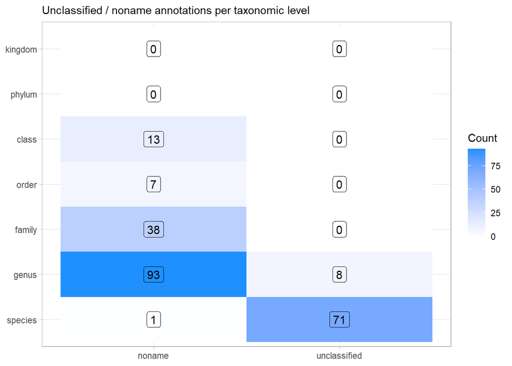

```r
taxonomy |>
  summarise(across(c(kingdom, phylum, class, order, family, genus, species), list(
    unclassified = ~ sum(str_detect(., "_unclassified"), na.rm = TRUE),
    noname = ~ sum(str_detect(., "_noname"), na.rm = TRUE)
  ))) |>
  pivot_longer(everything(),
               names_to = c("level", "type"),
               names_sep = "_(?=unclassified|noname)",
               values_to = "n") |>
  mutate(level = factor(level, levels = c("kingdom", "phylum", "class", "order", "family", "genus", "species"))) |>
  ggplot() +
  aes(x = type, y = fct_rev(level), fill = n) +
  geom_tile() +
  geom_label(aes(label = n), size = 4) +
  scale_fill_gradient(low = "white", high = "dodgerblue") +
  labs(x = NULL, y = NULL, fill = "Count",
       subtitle = "Unclassified / noname annotations per taxonomic level")
```

For taxa samples, several taxa have the same taxonomic annotation, so we need to aggregate the abundance data by taxonomic annotation, and to keep only one row for each taxon in the taxonomy data.

The duplicates are documented below, with the taxonomic annotation and the number of features with this annotation.

```r
taxonomy |> group_by(taxon_name) |> summarise(n = n()) |> filter(n > 1) |>
  gt(caption = "Taxonomic annotation with duplicates") |>
  tab_options(
    container.height = px(400)
  )
```

Taxonomic annotation with duplicates

| taxon_name | n |
| --- | --- |
| Abiotrophia_defectiva | 2 |
| Acidaminococcus_fermentans | 2 |
| Acidaminococcus_intestini | 2 |
| Acidaminococcus_sp_BV3L6 | 2 |
| Acidaminococcus_sp_HPA0509 | 2 |
| Acinetobacter_lwoffii | 2 |
| Acinetobacter_ursingii | 2 |
| Actinobaculum_schaalii | 2 |
| Actinomyces_europaeus | 2 |
| Actinomyces_graevenitzii | 2 |
| Actinomyces_odontolyticus | 2 |
| Actinomyces_turicensis | 2 |
| Actinomyces_urogenitalis | 2 |
| Adlercreutzia_equolifaciens | 2 |
| Aerococcus_viridans | 2 |
| Aeromonas_hydrophila | 2 |
| Aggregatibacter_aphrophilus | 2 |
| Aggregatibacter_segnis | 2 |
| Akkermansia_muciniphila | 2 |
| Alistipes_finegoldii | 2 |
| Alistipes_indistinctus | 2 |
| Alistipes_onderdonkii | 2 |
| Alistipes_putredinis | 2 |
| Alistipes_senegalensis | 2 |
| Alistipes_shahii | 2 |
| Alistipes_sp_AP11 | 2 |
| Alistipes_sp_HGB5 | 2 |
| Alloprevotella_rava | 2 |
| Alloprevotella_tannerae | 2 |
| Alloscardovia_omnicolens | 2 |

[output cut: 402 more lines]

Since abundance data is in relative scale, we can simply sum the relative abundance of features with the same taxonomic annotation to get the relative abundance of the taxon.

```r
abundance <-
  abundance |>
  t() |>
  as.data.frame() |>
  bind_cols(taxonomy |> select(taxon)) |>
  group_by(taxon) |>
  summarise(across(everything(), sum)) |>
  column_to_rownames("taxon") |>
  t() |>
  as.data.frame()
```

We also need to filter the taxonomy data to keep only one row for each taxon, and to set the taxon names as row names.

```r
taxonomy <-
  taxonomy |>
  distinct(taxon, .keep_all = TRUE) |>
  column_to_rownames("taxon")

taxonomy |> glimpse()
```

```
Rows: 809
Columns: 8
$ kingdom    <chr> "k__Bacteria", "k__Bacteria", "k__Bacteria", "k__Bacteria",…
$ phylum     <chr> NA, "p__Acidobacteria", "p__Acidobacteria", "p__Acidobacter…
$ class      <chr> NA, NA, "c__Acidobacteriia", "c__Acidobacteriia", "c__Acido…
$ order      <chr> NA, NA, NA, "o__Acidobacteriales", "o__Acidobacteriales", "…
$ family     <chr> NA, NA, NA, NA, "f__Acidobacteriaceae", "f__Acidobacteriace…
$ genus      <chr> NA, NA, NA, NA, NA, "g__Granulicella", "g__Granulicella", "…
$ species    <chr> NA, NA, NA, NA, NA, NA, "s__Granulicella_unclassified", NA,…
$ taxon_name <chr> "Bacteria (k)", "Acidobacteria (p)", "Acidobacteriia (c)", …
```

Since the IBD dataset contains higher level taxonomic annotations in addition to species level annotations, we can also create a `phyloseq` object with only species level annotations, by filtering the taxonomy data to keep only species level annotations, and modify the abundance data accordingly.

Additionally, we also filter out species for which `_unclassified` or `_noname` annotation is present.

```r
taxonomy <-
  taxonomy |>
  rownames_to_column("taxon") |>
  filter(!is.na(species)) |>
  column_to_rownames("taxon") |>
  filter(!str_detect(species, "_unclassified|_noname"))
```

### Documenting abundance distribution

```r
abundance <-
  abundance |>
  t() |>
  as.data.frame() |>
  rownames_to_column("taxon") |>
  filter(taxon %in% rownames(taxonomy)) |>
  column_to_rownames("taxon") |>
  mutate(across(everything(), as.numeric)) |>
  t() |>
  as.data.frame()
```

We check if samples rows sum to 1.

```r
row_sums <- rowSums(abundance)

if (all(row_sums == 1)) {
  cat("All samples rows sum to 1.\n")
} else {
  cat("Not all samples rows sum to 1.\n")
}
```

```
Not all samples rows sum to 1.
```

```r
row_sums |> summary()
```

```
   Min. 1st Qu.  Median    Mean 3rd Qu.    Max.
  0.000   1.802   1.888   1.832   1.941   2.000
```

We renormalize the abundance data to make sure that all samples rows sum to 1 and discard samples for which the sum of relative abundance is 0 (i.e., samples for which we do not have any bacterial species annotation after filtering out unclassified and noname species).

```r
dropped <- rownames(abundance)[rowSums(abundance) == 0]
cat("Dropped samples:\n"); print(dropped)
```

```
Dropped samples:
```

```
[1] "CSM7KOOR"    "MSM6J2HB"    "PSM6XBSU_TR" "PSM6XBTD"    "PSM7J129"
[6] "PSM7J1AW"    "PSM7J1BH"    "PSMA266C"
```

```r
abundance <- abundance[rowSums(abundance) != 0, ] |> (\(x) x / rowSums(x))()

rowSums(abundance) |> summary()
```

```
   Min. 1st Qu.  Median    Mean 3rd Qu.    Max.
      1       1       1       1       1       1
```

We check if there are any singletons (i.e., taxa that are present in only one sample) in the dataset, and if so, we document them by showing the taxonomic annotation and the number of samples with this annotation.

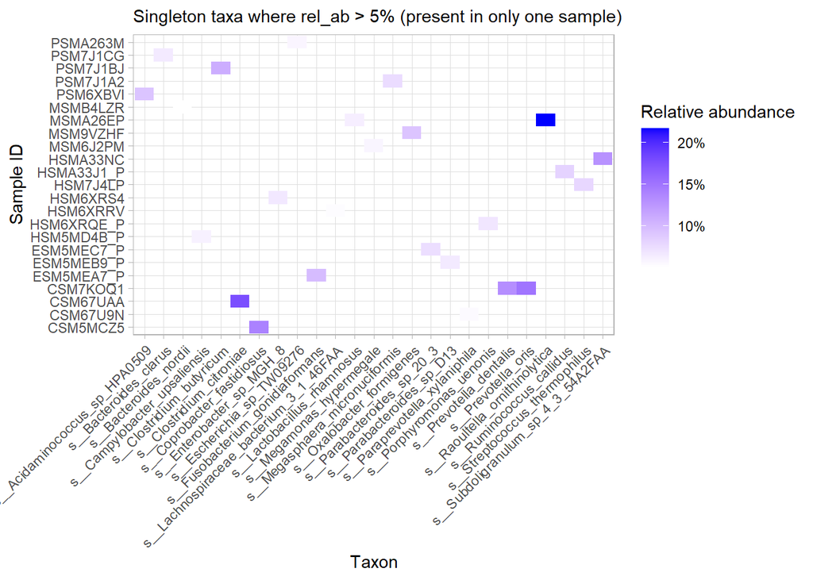

```r
abundance |>
  rownames_to_column("sample_id") |>
  pivot_longer(-sample_id, names_to = "taxon", values_to = "rel_ab") |>
  filter(rel_ab > 0.05) |>
  group_by(taxon) |>
  mutate(singleton = ifelse(n() == 1, "Singleton", "Non-singleton")) |>
  ungroup() |>
  filter(singleton == "Singleton") |>
  ggplot() +
  aes(x = taxon, y = sample_id, fill = rel_ab) +
  geom_tile() +
  scale_fill_gradient(low = "white", high = "blue", labels = scales::label_percent(accuracy = 1)) +
  labs(x = "Taxon", y = "Sample ID", fill = "Relative abundance",
       subtitle = "Singleton taxa where rel_ab > 5% (present in only one sample)") +
  theme(
    axis.text.x = element_text(angle = 45, hjust = 1)
  )
```

**Note**

We also document the distribution of the number of taxa per sample, as well as the mean relative abundance across samples over all taxa.

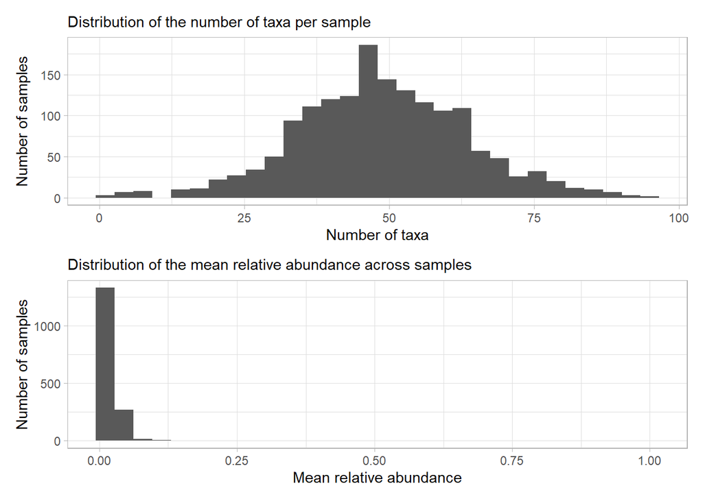

```r
abundance |>
  rownames_to_column("sample_id") |>
  pivot_longer(-sample_id, names_to = "taxon", values_to = "rel_ab") |>
  filter(rel_ab > 0) |>
  group_by(sample_id) |>
  summarise(n_taxa = n()) |>
  ggplot() +
  aes(x = n_taxa) +
  geom_histogram(bins = 30) +
  labs(x = "Number of taxa", y = "Number of samples",
       subtitle = "Distribution of the number of taxa per sample") +

abundance |>
  rownames_to_column("sample_id") |>
  pivot_longer(-sample_id, names_to = "taxon", values_to = "rel_ab") |>
  filter(rel_ab > 0) |>
  group_by(sample_id) |>
  summarise(mean_rel_ab = mean(rel_ab)) |>
  ggplot() +
  aes(x = mean_rel_ab) +
  geom_histogram(bins = 30) +
  labs(x = "Mean relative abundance", y = "Number of samples",
       subtitle = "Distribution of the mean relative abundance across samples") +

  plot_layout(nrow = 2)
```

Below, we check if there are any samples with a taxon with relative abundance of 1, and if so, we document them by showing the sample ID and the taxonomic annotation of the taxon with relative abundance of 1.

```r
abundance |>
  rownames_to_column("sample_id") |>
  pivot_longer(-sample_id, names_to = "taxon", values_to = "rel_ab") |>
  filter(rel_ab == 1) |>
  gt(caption = "Samples with a taxon with relative abundance of 1")
```

Samples with a taxon with relative abundance of 1

| sample_id | taxon | rel_ab |
| --- | --- | --- |
| HSM7J4LH | s__Faecalibacterium_prausnitzii | 1 |

**Warning**

A sample has a taxon with relative abundance of 1. This means that this sample has only one taxon with non-zero relative abundance. However, this taxon was not identified above (before the renormalization), so this is likely due the renormalization step.

### Documenting available metadata

For samples data, we need to filter the metadata to keep only the samples for which we have metagenomics data, and to set the sample IDs as row names. Additionally, since not all covariates in the metadata are relevant for our analyses, we also select only a subset of the metadata variables to keep in the samples data.

We document (some) of the original metadata variables in the plots below.

```r
# we filter out columns with only NA values

metadata_filtered <- metadata |> filter(data_type == "metagenomics") |> select(where(~!all(is.na(.x))))
samples <- metadata |> clean_names() |> filter(data_type == "metagenomics") |> select(where(~!all(is.na(.x))))
```

**Age at diagnosis**

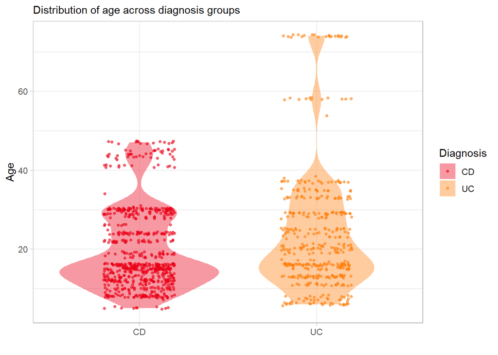

```r
samples |>
  filter(!is.na(age_at_diagnosis)) |>
  ggplot() +
  aes(x = diagnosis, y = age_at_diagnosis |> as.numeric(), fill = diagnosis, color = diagnosis) +
  geom_violin(alpha = 0.4, color = NA) +
  geom_point(position = position_jitter(width = 0.2), size = 1, alpha = 0.6) +
  scale_fill_manual(values = c("nonIBD" = "#0078B9", "CD" = "#EA0017", "UC" = "#FF7F0E")) +
  scale_color_manual(values = c("nonIBD" = "#0078B9", "CD" = "#EA0017", "UC" = "#FF7F0E")) +
  labs(x = "", y = "Age", fill = "Diagnosis", color = "Diagnosis",
       subtitle = "Distribution of age across diagnosis groups")
```

**Education level**

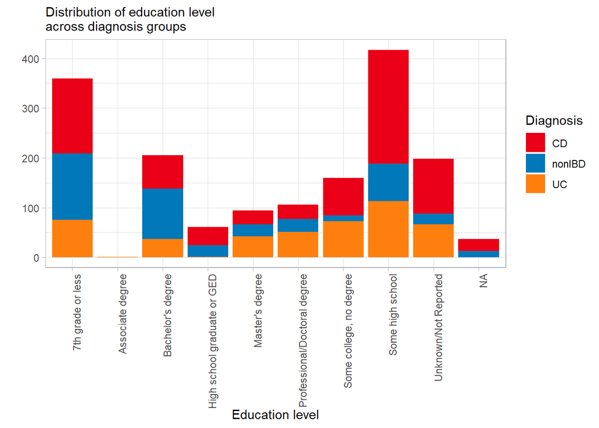

```r
samples |>
  ggplot() +
  aes(x = education_level, fill = diagnosis) +
  geom_bar(position = "stack") +
  scale_fill_manual(values = c("nonIBD" = "#0078B9", "CD" = "#EA0017", "UC" = "#FF7F0E")) +
  labs(y = "", x = "Education level", fill = "Diagnosis",
       subtitle = "Distribution of education level \nacross diagnosis groups") +
  theme(axis.text.x = element_text(angle = 90, hjust = 1))
```

**Occupation**

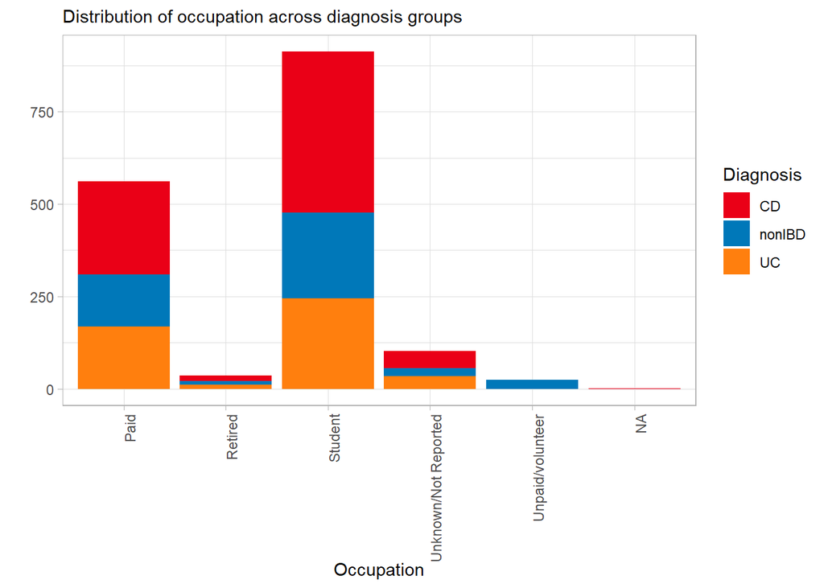

```r
samples |>
  ggplot() +
  aes(x = occupation, fill = diagnosis) +
  geom_bar(position = "stack") +
  scale_fill_manual(values = c("nonIBD" = "#0078B9", "CD" = "#EA0017", "UC" = "#FF7F0E")) +
  labs(y = "", x = "Occupation", fill = "Diagnosis",
       subtitle = "Distribution of occupation across diagnosis groups") +
  theme(axis.text.x = element_text(angle = 90, hjust = 1))
```

**Diagnosis**

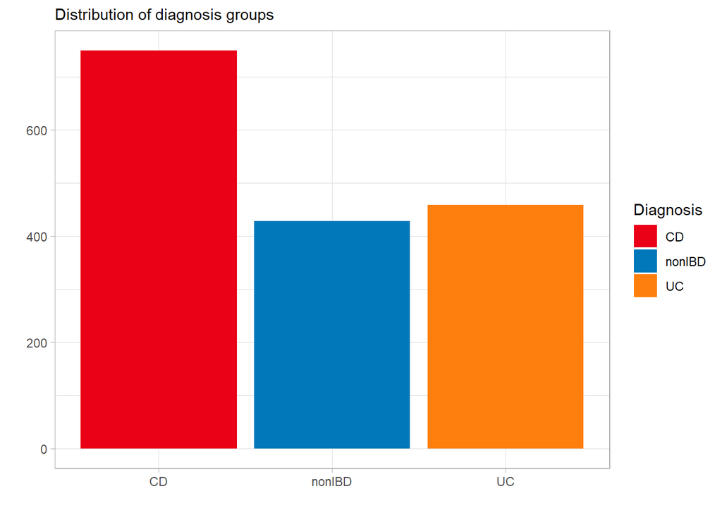

```r
samples |>
  ggplot() +
  aes(x = diagnosis, fill = diagnosis) +
  geom_bar(position = "stack") +
  scale_fill_manual(values = c("nonIBD" = "#0078B9", "CD" = "#EA0017", "UC" = "#FF7F0E")) +
  labs(y = "", x = "", fill = "Diagnosis",
       subtitle = "Distribution of diagnosis groups")
```

**Note**

There is no age data for the healthy group, since healthy participants were not diagnosed with IBD, so they do not have an age at diagnosis.

```r
samples <-
  metadata |>
  select("External ID", "Participant ID", "data_type", "week_num", "visit_num", "IntervalName", "diagnosis") |>
  clean_names() |>
  filter(data_type == "metagenomics") |>
  column_to_rownames("external_id")

samples |> glimpse()
```

```
Rows: 1,638
Columns: 6
$ participant_id <chr> "C3001", "C3001", "C3001", "C3001", "C3001", "C3001", "…
$ data_type      <chr> "metagenomics", "metagenomics", "metagenomics", "metage…
$ week_num       <chr> "0.0", "2.0", "4.0", "6.0", "8.0", "12.0", "14.0", "16.…
$ visit_num      <chr> "4", "5", "6", "7", "8", "11", "12", "13", "14", "15", …
$ interval_name  <chr> "Stool Collection #1", "Stool Collection #2", "Stool Co…
$ diagnosis      <chr> "CD", "CD", "CD", "CD", "CD", "CD", "CD", "CD", "CD", "…
```

We also filter out the dropped samples (for which the sum of relative abundance is 0) from the samples data.

```r
samples <-
  samples |>
  rownames_to_column("sample_id") |>
  filter(!sample_id %in% dropped) |>
  column_to_rownames("sample_id")
```

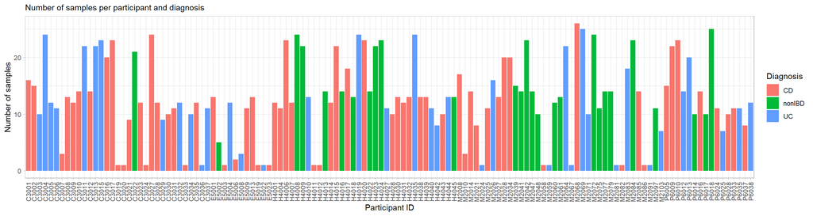

```r
samples |>
  rownames_to_column("sample_id") |>
  select(sample_id, participant_id, visit_num, week_num, interval_name, diagnosis) |>
  group_by(visit_num, participant_id) |>
  mutate(total_samples = n()) |>
  ggplot() +
  aes(x = participant_id, fill = diagnosis) +
  geom_bar() +
  labs(x = "Participant ID", y = "Number of samples", fill = "Diagnosis",
       subtitle = "Number of samples per participant and diagnosis") +
  theme(axis.text.x = element_text(angle = 90, vjust = 0.5, hjust = 1))
```

#### Creating a dictionary for metadata variables

We create a dictionary for the metadata variables, to keep track of the meaning of each variable and the values they can take, previous and new name, and if it is kept for further analysis or not.

```r
IBD_dictionary <-
  tibble(
    original_variable = metadata_filtered |> names(),
    new_variable = metadata_filtered |> clean_names() |> names(),
    description = c(
      "Project name",
      "External ID of the sample",
      "Participant ID",
      "Site and sub-collection identifier",
      "Type of data (e.g., metagenomics, metabolomics)",
      "Week number of sample collection",
      "Date sample was received",
      "Number of days since previous sample",
      "Visit number of sample collection",
      "Associated research project name",
      "PDO number (project/delivery order)",
      "GSSR IDs associated with the sample",
      "Sequencing product used",
      "Library construction set identifier",
      "Aggregated sequencing lanes",
      "Work request ID",
      "Number of lanes included in aggregation",
      "Total raw reads",
      "Reads passing quality filters",
      "Reads failing QC",
      "Reads mapping to human genome",
      "Interval name (e.g., baseline, week 2)",
      "Sequence order of the interval",
      "Project-specific sample ID",
      "Name of collection site",
      "Age at IBD diagnosis (years)",
      "Highest education level attained",
      "Participant occupation",
      "Whole blood received at Broad Institute",
      "Serum tube 1 received at CSMC",
      "Serum tubes 2–4 received at MGH",
      "Flora sample received at MGH",
      "RNA/DNA sample received at Broad Institute",
      "ECP sample received at Washington University",
      "Age at consent (years)",
      "Diagnosis group (e.g., nonIBD, CD, UC)",
      "Frequency of sugary soft drinks, tea, or coffee",
      "Frequency of diet drinks with artificial sweeteners",
      "Frequency of fruit juice consumption",
      "Frequency of water consumption",
      "Frequency of alcohol consumption",
      "Frequency of probiotic foods (yogurt, kefir, sauerkraut)",
      "Frequency of dairy consumption",
      "Probiotic supplement use",
      "Frequency of fruit consumption (no juice)",
      "Frequency of vegetable consumption",
      "Medications received in the past 2 weeks",
      "Frequency of bean/legume consumption",
      "Frequency of whole grain consumption",
      "Frequency of refined starch consumption",
      "Frequency of egg consumption",
      "Frequency of processed meat consumption",
      "Frequency of red meat consumption",
      "Frequency of white meat consumption",
      "Frequency of shellfish consumption",
      "Frequency of fish consumption",
      "Frequency of sweets consumption",
      "Antibiotic use in past 2 weeks",
      "Chemotherapy in past 2 weeks",
      "Immunosuppressant use in past 2 weeks",
      "Colonoscopy or procedure in past 2 weeks",
      "Oral contrast use in past 2 weeks",
      "Diarrhea in past 2 weeks",
      "Hospitalization in past 2 weeks",
      "History of bowel surgery",
      "Frequency of unsweetened tea or coffee",
      "Fecal calprotectin level (ng/mL)",
      "Presence of uveitis (extraintestinal manifestation)",
      "Presence of erythema nodosum",
      "Presence of aphthous ulcers",
      "Presence of pyoderma gangrenosum",
      "Presence of anal fissure",
      "Presence of new fistula",
      "Presence of abscess",
      "Whether HBI was completed",
      "HBI: general wellbeing score",
      "HBI: abdominal pain score",
      "HBI: number of liquid or soft stools in past 24 hours",
      "HBI: abdominal mass score",
      "HBI: arthralgia score",
      "Harvey-Bradshaw Index (HBI) total score",
      "Hispanic or Latino origin",
      "History of breast cancer",
      "History of cholangiocarcinoma",
      "History of colon or rectal cancer",
      "History of Hodgkin's lymphoma",
      "History of liver cancer",
      "History of lung cancer",
      "History of lymphoma (NOS)",
      "History of non-Hodgkin's lymphoma",
      "History of ovarian cancer",
      "History of prostate cancer",
      "History of celiac disease",
      "History of chronic bronchitis",
      "History of dermatitis herpetiformis",
      "History of familial Mediterranean fever",
      "History of Graves' disease",
      "History of Guillain-Barré syndrome",
      "History of Hashimoto's thyroiditis",
      "History of idiopathic pulmonary fibrosis",
      "History of idiopathic thrombocytopenic purpura",
      "History of irritable bowel syndrome",
      "History of alopecia areata",
      "History of multiple sclerosis",
      "History of myasthenia gravis",
      "History of myocarditis",
      "History of neuropathy",
      "History of pericarditis",
      "History of pemphigus vulgaris",
      "History of pernicious anemia",
      "History of polymyositis or dermatomyositis",
      "History of primary biliary cirrhosis",
      "History of primary sclerosing cholangitis",
      "History of ankylosing spondylitis",
      "History of psoriasis",
      "History of rheumatoid arthritis",
      "History of sarcoidosis",
      "History of scleroderma / systemic sclerosis",
      "History of Sjögren's syndrome",
      "History of systemic lupus erythematosus",
      "History of temporal arteritis",
      "History of thyroid disease (uncertain diagnosis)",
      "History of type I (juvenile) diabetes",
      "History of vitiligo",
      "History of arthritis (uncertain diagnosis)",
      "History of Wegener's granulomatosis",
      "History of asthma",
      "History of autoimmune hemolytic anemia",
      "History of autoimmune hepatitis",
      "History of Behçet's syndrome",
      "Whether patient signed informed consent",
      "Whether subject withdrew from the study",
      "Whether subject was terminated by investigator",
      "Reason for withdrawal or termination",
      "Partial endoscopy performed",
      "Baseline Montreal classification location",
      "Explanation for 'other' responses",
      "Self-reported race",
      "Presence of arthralgias (joint pain)",
      "Presence of pyoderma gangrenosum (follow-up)",
      "Presence of erythema nodosum (follow-up)",
      "Presence of uveitis (follow-up)",
      "Whether SCCAI was completed",
      "SCCAI: bowel frequency during the day",
      "SCCAI: bowel frequency during the night",
      "SCCAI: urgency of defecation",
      "SCCAI: blood in the stool",
      "SCCAI: general well-being in past 24 hours",
      "Simple Clinical Colitis Activity Index (SCCAI) total score",
      "Partial endoscopy performed (follow-up)",
      "Biological sex",
      "Specified race (free text)",
      "Whether stool sample was collected",
      "Tube A collected for DNA/RNA analysis",
      "Tube A collected for metabolomics",
      "Tube A collected for storage",
      "Tube A collected for viromics",
      "Tube B collected for fecal calprotectin",
      "Fecal calprotectin measurement",
      "Tube B collected for proteomics",
      "Viromics sample received at Baylor",
      "Fecal calprotectin sample received at MGH",
      "Proteomics sample received at LBNL",
      "Stool sample ID for tube A (EtOH)",
      "Sample ID for tube B (no preservative)",
      "Tubes A and B received at Broad Institute"
    ),
    removed = c(
      TRUE, FALSE, FALSE, TRUE, TRUE, FALSE, TRUE, TRUE, FALSE, TRUE, TRUE, TRUE,
      TRUE, TRUE, TRUE, TRUE, TRUE, TRUE, TRUE, TRUE, TRUE, FALSE, TRUE, TRUE,
      TRUE, TRUE, TRUE, TRUE, TRUE, TRUE, TRUE, TRUE, TRUE, TRUE, TRUE, FALSE,
      TRUE, TRUE, TRUE, TRUE, TRUE, TRUE, TRUE, TRUE, TRUE, TRUE, TRUE, TRUE,
      TRUE, TRUE, TRUE, TRUE, TRUE, TRUE, TRUE, TRUE, TRUE, TRUE, TRUE, TRUE,
      TRUE, TRUE, TRUE, TRUE, TRUE, TRUE, TRUE, TRUE, TRUE, TRUE, TRUE, TRUE,
      TRUE, TRUE, TRUE, TRUE, TRUE, TRUE, TRUE, TRUE, TRUE, TRUE, TRUE, TRUE,
      TRUE, TRUE, TRUE, TRUE, TRUE, TRUE, TRUE, TRUE, TRUE, TRUE, TRUE, TRUE,
      TRUE, TRUE, TRUE, TRUE, TRUE, TRUE, TRUE, TRUE, TRUE, TRUE, TRUE, TRUE,
      TRUE, TRUE, TRUE, TRUE, TRUE, TRUE, TRUE, TRUE, TRUE, TRUE, TRUE, TRUE,
      TRUE, TRUE, TRUE, TRUE, TRUE, TRUE, TRUE, TRUE, TRUE, TRUE, TRUE, TRUE,
      TRUE, TRUE, TRUE, TRUE, TRUE, TRUE, TRUE, TRUE, TRUE, TRUE, TRUE, TRUE,
      TRUE, TRUE, TRUE, TRUE, TRUE, TRUE, TRUE, TRUE, TRUE, TRUE, TRUE, TRUE,
      TRUE, TRUE, TRUE, TRUE, TRUE, TRUE, TRUE, TRUE, TRUE, TRUE
    )
  ) |>
  mutate(new_variable = case_when(
    new_variable == "external_id" ~ "uid",
    new_variable == "participant_id" ~ "pid",
    TRUE ~ new_variable
  ))

IBD_dictionary |> gt(caption = "Dictionary for the metadata variables in the IBD dataset") |>
  tab_options(container.height = px(800))
```

Dictionary for the metadata variables in the IBD dataset

| original_variable | new_variable | description | removed |
| --- | --- | --- | --- |
| Project | project | Project name | TRUE |
| External ID | uid | External ID of the sample | FALSE |
| Participant ID | pid | Participant ID | FALSE |
| site_sub_coll | site_sub_coll | Site and sub-collection identifier | TRUE |
| data_type | data_type | Type of data (e.g., metagenomics, metabolomics) | TRUE |
| week_num | week_num | Week number of sample collection | FALSE |
| date_of_receipt | date_of_receipt | Date sample was received | TRUE |
| interval_days | interval_days | Number of days since previous sample | TRUE |
| visit_num | visit_num | Visit number of sample collection | FALSE |
| Research Project | research_project | Associated research project name | TRUE |
| PDO Number | pdo_number | PDO number (project/delivery order) | TRUE |
| GSSR IDs | gssr_i_ds | GSSR IDs associated with the sample | TRUE |
| Product | product | Sequencing product used | TRUE |
| LCSET | lcset | Library construction set identifier | TRUE |
| Aggregated Lanes | aggregated_lanes | Aggregated sequencing lanes | TRUE |
| WR ID | wr_id | Work request ID | TRUE |
| # Lanes in Aggregation | number_lanes_in_aggregation | Number of lanes included in aggregation | TRUE |
| reads_raw | reads_raw | Total raw reads | TRUE |
| reads_filtered | reads_filtered | Reads passing quality filters | TRUE |
| reads_qc_fail | reads_qc_fail | Reads failing QC | TRUE |
| reads_human | reads_human | Reads mapping to human genome | TRUE |
| IntervalName | interval_name | Interval name (e.g., baseline, week 2) | FALSE |
| IntervalSequence | interval_sequence | Sequence order of the interval | TRUE |
| ProjectSpecificID | project_specific_id | Project-specific sample ID | TRUE |
| site_name | site_name | Name of collection site | TRUE |
| Age at diagnosis | age_at_diagnosis | Age at IBD diagnosis (years) | TRUE |
| Education Level | education_level | Highest education level attained | TRUE |
| Occupation | occupation | Participant occupation | TRUE |
| Whole blood received at Broad: | whole_blood_received_at_broad | Whole blood received at Broad Institute | TRUE |
| Serum tube #1 received at CSMC: | serum_tube_number_1_received_at_csmc | Serum tube 1 received at CSMC | TRUE |

[output cut: 136 more lines]

```r
samples <-
  samples |>
  rownames_to_column("sample_id") |>
  dplyr::rename(uid = sample_id, pid = participant_id) |>
  column_to_rownames("uid")

samples |> glimpse()
```

```
Rows: 1,630
Columns: 6
$ pid           <chr> "C3001", "C3001", "C3001", "C3001", "C3001", "C3001", "C…
$ data_type     <chr> "metagenomics", "metagenomics", "metagenomics", "metagen…
$ week_num      <chr> "0.0", "2.0", "4.0", "6.0", "8.0", "12.0", "14.0", "16.0…
$ visit_num     <chr> "4", "5", "6", "7", "8", "11", "12", "13", "14", "15", "…
$ interval_name <chr> "Stool Collection #1", "Stool Collection #2", "Stool Col…
$ diagnosis     <chr> "CD", "CD", "CD", "CD", "CD", "CD", "CD", "CD", "CD", "C…
```

### Saving cleaned data into a `phyloseq` object

Finally, we can create the `phyloseq` object using the `otu_table`, `tax_table`, and `sample_data` functions from the `phyloseq` package.

```r
ps_ibd <- phyloseq(
  otu_table(as.matrix(abundance), taxa_are_rows = FALSE),
  tax_table(as.matrix(taxonomy)),
  sample_data(samples)
)

ps_ibd
```

```
phyloseq-class experiment-level object
otu_table()   OTU Table:         [ 432 taxa and 1630 samples ]
sample_data() Sample Data:       [ 1630 samples by 6 sample variables ]
tax_table()   Taxonomy Table:    [ 432 taxa by 8 taxonomic ranks ]
```

## IBS dataset (Mars et al., 2020)

The irritable bowel syndrome (IBS) dataset in Mars et al. (2020) was obtained from [Mendeley data](https://data.mendeley.com/datasets/29n2z5r5ph/3) plateform.

For the analyses, we have the following datasets at our disposal:

- `metagenomics.xlsx`: contains the **metagenomics count data** and metadata for biopsy samples, in CSV format. This correspond to the file “Supplementary data I Microbiome data tables stool and biopsy.xlsx” in the plateform (version 3 from 2020-03-11).

### Importing raw data

In the chunk below, we import the metadata and abundance data for the IBS dataset.

```r
data_biopsy <- readxl::read_excel(file.path(data_dir(), "01-raw-data/02-IBS", "metagenomics.xlsx"), sheet = 2)
metadata <- readxl::read_excel(file.path(data_dir(), "01-raw-data/02-IBS", "metagenomics.xlsx"), sheet = 5)
```

We first document the number of samples and features in the original dataset.

```r
n_samples <- nrow(metadata)
n_features <- ncol(data_biopsy) - 1 # we remove the first column
```

### Cleaning taxonomic annotations

We then transform the abundance data into a `phyloseq` object in the next steps, but before that, we need to perform some data cleaning. For this, we need to filter the abundance data to keep only bacterial species, and to remove the taxonomic levels from the taxonomic names by keeping only the last available level.

```r
abundance <- data_biopsy |> filter(str_detect(`#OTU ID`, "k__Bacteria"))
```

For taxonomy data, we need to extract the taxonomic levels and names from the taxonomic profiles (OTU column in `data_biopsy`), and to keep only the last available level for each feature, saved as `taxon_names`, with a letter indicating the taxonomic level between parentheses (e.g., “g” for genus, “f” for family, etc.).

```r
taxonomy <-
  tibble(full_name = abundance$`#OTU ID`) |>
  mutate(
    kingdom = str_extract(full_name, "k__[^;]+"),
    phylum = str_extract(full_name, "p__[^;]+"),
    class = str_extract(full_name, "c__[^;]+"),
    order = str_extract(full_name, "o__[^;]+"),
    family = str_extract(full_name, "f__[^;]+"),
    genus = str_extract(full_name, "g__[^;]+"),
    species = str_extract(full_name, "s__[^;]+")
  ) |>
    mutate(
    taxon = coalesce(
      species, genus, family, order, class, phylum, kingdom
    )
  ) |>
  mutate(
    across(c(species, genus, family, order, class, phylum, kingdom),
           ~ str_remove_all(., "\\[|\\]")),
    taxon_name = coalesce(
      str_remove(species, "s__"),
      str_c(str_remove(genus, "g__"), " (g)"),
      str_c(str_remove(family, "f__"), " (f)"),
      str_c(str_remove(order, "o__"), " (o)"),
      str_c(str_remove(class, "c__"), " (c)"),
      str_c(str_remove(phylum, "p__"), " (p)"),
      str_c(str_remove(kingdom, "k__"), " (k)")
    )
  ) |>
  select(-full_name)
```

We check if there are any missing species annotations.

```r
cat("There are", nrow(taxonomy |> filter(is.na(species)) == "TRUE"), "features without species annotation.\n")
```

```
There are 0 features without species annotation.
```

We additionally check if there are any duplicated taxonomic annotations, and if so, we document them by showing the taxonomic annotation and the number of features with this annotation. The duplicates will be merged in taxonomy, as well as in abundance data.

```r
taxonomy |>
  group_by(taxon_name) |>
  summarise(n = n()) |>
  filter(n > 1) |>
  gt(caption = "Taxonomic annotation with duplicates")
```

Taxonomic annotation with duplicates

| taxon_name | n |
| --- | --- |
| Anaerococcus_prevotii | 2 |
| Blautia_obeum | 2 |
| Cellulomonas_flavigena | 2 |
| Corynebacterium_aurimucosum | 2 |
| Corynebacterium_variabile | 2 |
| Fusobacterium_nucleatum | 3 |
| Oxalobacter_formigenes | 2 |
| Rothia_dentocariosa | 2 |
| Sutterella_wadsworthensis | 2 |

To merge duplicates in abundance, we can simply sum the counts of features with the same taxonomic annotation to get the count of the taxon.

```r
abundance <-
  abundance |>
  bind_cols(taxonomy |> select(taxon)) |>
  group_by(taxon) |>
  summarise(across(-`#OTU ID`, sum)) |>
  column_to_rownames("taxon")

abundance |> head() |> select(1:5)
```

```
                              7541v1 7541v2 7542v1 7544v1 7544v2
s__Abiotrophia_defectiva           0      0      0      0      0
s__Acidaminococcus_fermentans      0      0      0      0      0
s__Acidaminococcus_intestini       0      0      0      0      0
s__Acidovorax_ebreus               0      0      0      0      0
s__Acidovorax_sp._RAC01            0      0      0      0      0
s__Acinetobacter_baumannii         0      0      0      0      0
```

### Documenting abundance distribution

We check if there are any singletons (i.e., taxa that are present in only one sample) in the dataset, and if so, we document them by showing the taxonomic annotation and the number of samples with this annotation.

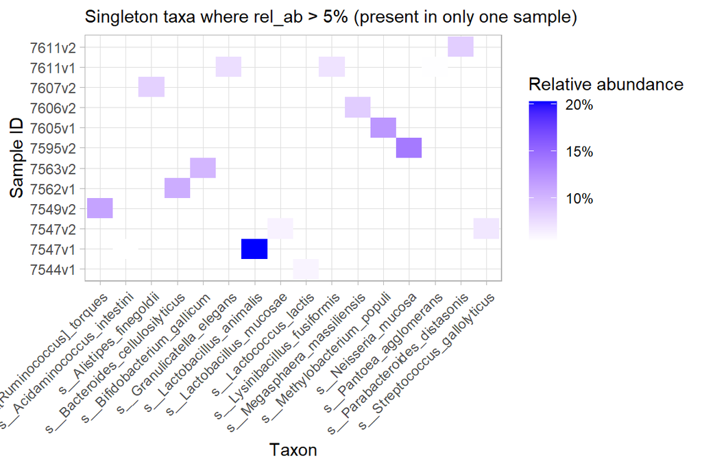

```r
abundance |>
  rownames_to_column("taxon") |>
  pivot_longer(-taxon, names_to = "sample_id", values_to = "counts") |>
  group_by(sample_id) |>
  mutate(rel_ab = counts / sum(counts)) |>
  ungroup() |>
  select(-counts) |>
  filter(rel_ab > 0.05) |>
  group_by(taxon) |>
  mutate(singleton = ifelse(n() == 1, "Singleton", "Non-singleton")) |>
  ungroup() |>
  filter(singleton == "Singleton") |>
  ggplot() +
  aes(x = taxon, y = sample_id, fill = rel_ab) +
  geom_tile() +
  scale_fill_gradient(low = "white", high = "blue", labels = scales::label_percent(accuracy = 1)) +
  labs(x = "Taxon", y = "Sample ID", fill = "Relative abundance",
       subtitle = "Singleton taxa where rel_ab > 5% (present in only one sample)") +
  theme(
    axis.text.x = element_text(angle = 45, hjust = 1)
  )
```

We also document the distribution of the number of taxa per sample, as well as the mean counts across samples over all taxa.

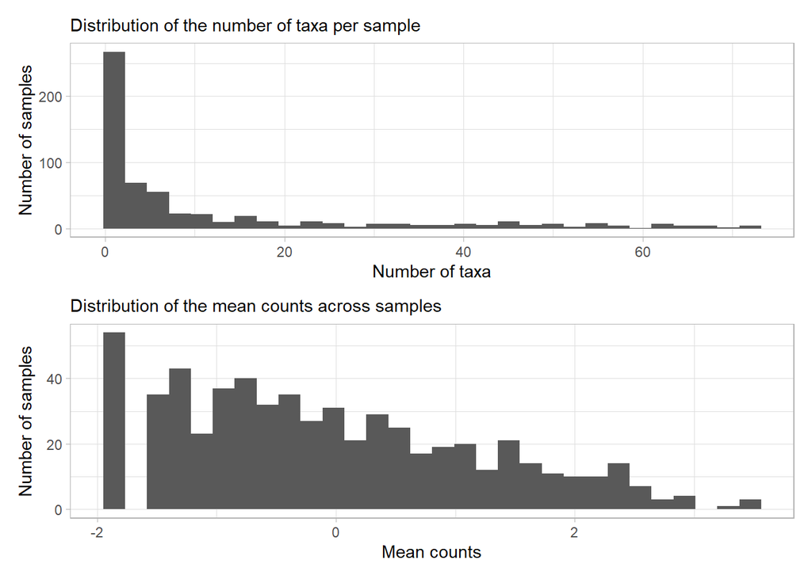

```r
abundance |>
  rownames_to_column("sample_id") |>
  pivot_longer(-sample_id, names_to = "taxon", values_to = "count") |>
  group_by(sample_id) |>
  mutate(rel_ab = count / sum(count)) |>
  ungroup() |>
  filter(rel_ab > 0) |>
  group_by(sample_id) |>
  summarise(n_taxa = n()) |>
  ggplot() +
  aes(x = n_taxa) +
  geom_histogram(bins = 30) +
  labs(x = "Number of taxa", y = "Number of samples",
       subtitle = "Distribution of the number of taxa per sample") +

abundance |>
  rownames_to_column("sample_id") |>
  pivot_longer(-sample_id, names_to = "taxon", values_to = "count") |>
  group_by(sample_id) |>
  summarise(mean_count = mean(count)) |>
  ggplot() +
  aes(x = mean_count |> log10()) +
  geom_histogram(bins = 30) +
  labs(x = "Mean counts", y = "Number of samples",
       subtitle = "Distribution of the mean counts across samples") +

  plot_layout(nrow = 2)
```

We filter duplicates in taxonomy to keep only one row for each taxon, and to set the taxon names as row names.

```r
taxonomy <-
  taxonomy |>
  distinct(taxon, .keep_all = TRUE) |>
  column_to_rownames("taxon")

taxonomy |> glimpse()
```

```
Rows: 598
Columns: 8
$ kingdom    <chr> "k__Bacteria", "k__Bacteria", "k__Bacteria", "k__Bacteria",…
$ phylum     <chr> NA, "p__Actinobacteria", "p__Actinobacteria", "p__Actinobac…
$ class      <chr> NA, "c__Actinobacteria", "c__Actinobacteria", "c__Actinobac…
$ order      <chr> NA, "o__Actinomycetales", "o__Actinomycetales", "o__Actinom…
$ family     <chr> NA, "f__Actinomycetaceae", "f__Actinomycetaceae", "f__Actin…
$ genus      <chr> NA, "g__Actinobaculum", "g__Actinomyces", "g__Actinomyces",…
$ species    <chr> "s__bacterium_LF-3", "s__Actinobaculum_sp._oral_taxon_183",…
$ taxon_name <chr> "bacterium_LF-3", "Actinobaculum_sp._oral_taxon_183", "Acti…
```

### Documenting available metadata

For sample (metadata) data, we will only keep relevant metadata variables for our analyses, and we set the sample IDs as row names. We document the original metadata variables below.

```r
samples <- metadata |> clean_names()
```

**Age**

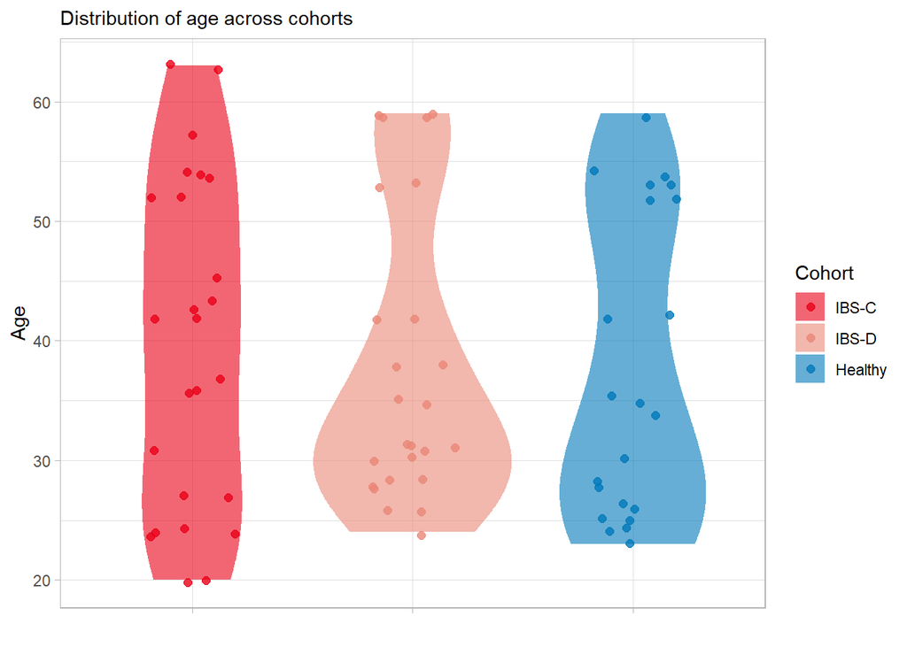

```r
samples |>
  ggplot() +
  aes(x = cohort, y = age, color = cohort, fill = cohort) +
  geom_violin(alpha = 0.6, color = NA) +
  geom_point(position = position_jitter(width = 0.2), size = 2, alpha = 0.8) +
  scale_color_manual(
    values = c("H" = "#0078B9", "C" = "#EA0017", "D" = "#EA8777"),
    labels = c("H" = "Healthy", "C" = "IBS-C", "D" = "IBS-D")
    ) +
  scale_fill_manual(
    values = c("H" = "#0078B9", "C" = "#EA0017", "D" = "#EA8777"),
    labels = c("H" = "Healthy", "C" = "IBS-C", "D" = "IBS-D")
    ) +
  labs(x = "", y = "Age", color = "Cohort", fill = "Cohort",
       subtitle = "Distribution of age across cohorts") +
  theme(
    axis.text.x = element_blank()
  )
```

**BMI**

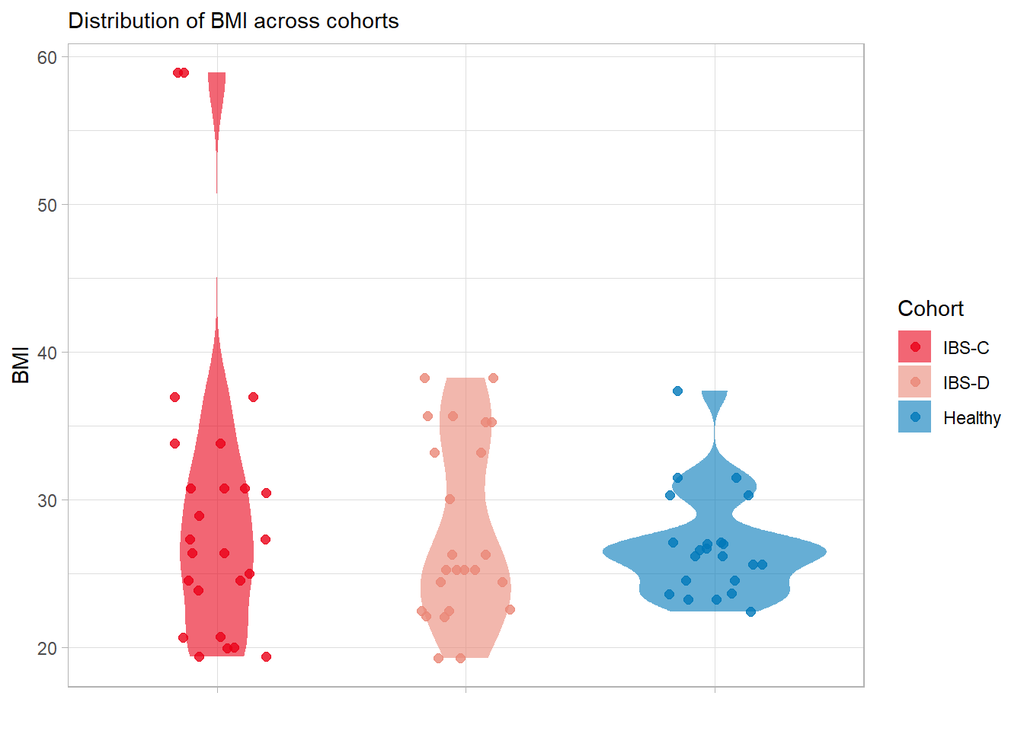

```r
samples |>
  ggplot() +
  aes(x = cohort, y = bmi, color = cohort, fill = cohort) +
  geom_violin(alpha = 0.6, color = NA) +
  geom_point(position = position_jitter(width = 0.2), size = 2, alpha = 0.8) +
  scale_color_manual(
    values = c("H" = "#0078B9", "C" = "#EA0017", "D" = "#EA8777"),
    labels = c("H" = "Healthy", "C" = "IBS-C", "D" = "IBS-D")
    ) +
  scale_fill_manual(
    values = c("H" = "#0078B9", "C" = "#EA0017", "D" = "#EA8777"),
    labels = c("H" = "Healthy", "C" = "IBS-C", "D" = "IBS-D")
    ) +
  labs(x = "", y = "BMI", color = "Cohort", fill = "Cohort",
       subtitle = "Distribution of BMI across cohorts") +
  theme(
    axis.text.x = element_blank()
  )
```

**Gender**

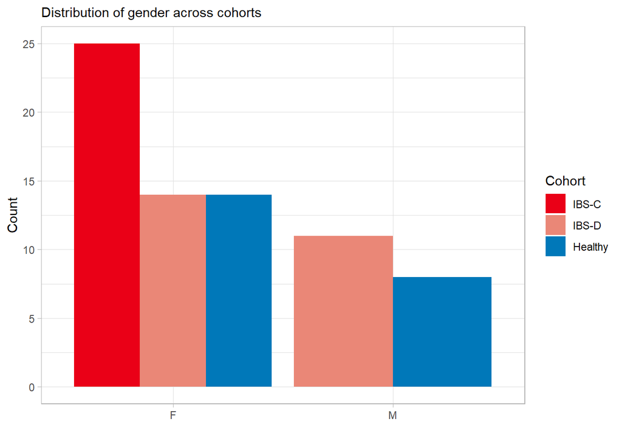

```r
samples |>
  ggplot() +
  aes(x = gender, fill = cohort) +
  geom_bar(position = "dodge") +
  scale_fill_manual(
    values = c("H" = "#0078B9", "C" = "#EA0017", "D" = "#EA8777"),
    labels = c("H" = "Healthy", "C" = "IBS-C", "D" = "IBS-D")
    ) +
  labs(x = "", y = "Count", color = "Cohort", fill = "Cohort",
       subtitle = "Distribution of gender across cohorts")
```

**Cohort**

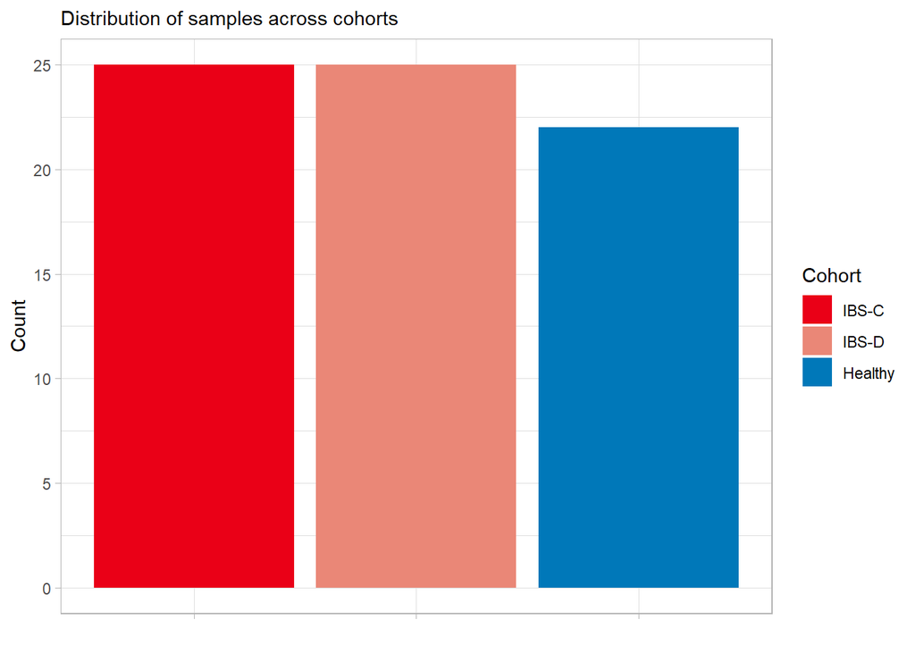

```r
samples |>
  ggplot() +
  aes(x = cohort, fill = cohort) +
  geom_bar(position = "dodge") +
  scale_fill_manual(
    values = c("H" = "#0078B9", "C" = "#EA0017", "D" = "#EA8777"),
    labels = c("H" = "Healthy", "C" = "IBS-C", "D" = "IBS-D")
    ) +
  labs(x = "", y = "Count", color = "Cohort", fill = "Cohort",
       subtitle = "Distribution of samples across cohorts") +
   theme(
    axis.text.x = element_blank()
  )
```

```r
samples <-
  metadata |>
  clean_names() |>
  mutate(group = ifelse(cohort %in% c("C", "D"), "IBS", cohort),
         group = group |> factor()) |>
  mutate(time = str_replace_all(timepoint, c("1st" = "1", "2nd" = "2")),
         time = time |> factor())
```

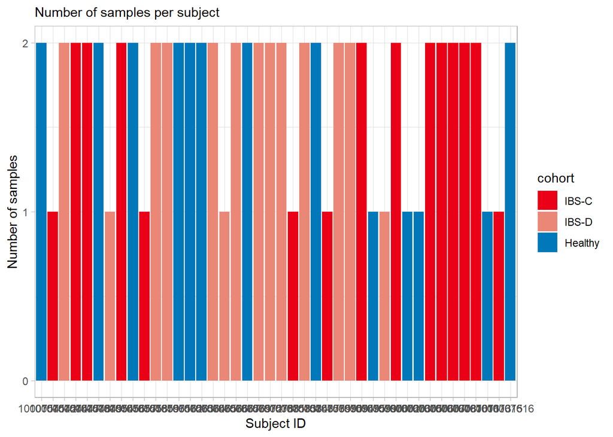

```r
samples |>
  group_by(study_id, cohort) |>
  summarize(n_samples = n()) |>
  ungroup() |>
  ggplot() +
  aes(x = study_id |> factor(), y = n_samples, fill = cohort) +
  geom_bar(stat = "identity") +
  scale_fill_manual(
    values = c("H" = "#0078B9", "C" = "#EA0017", "D" = "#EA8777"),
    labels = c("H" = "Healthy", "C" = "IBS-C", "D" = "IBS-D")
    ) +
  scale_y_continuous(breaks = scales::breaks_width(1)) +
  labs(x = "Subject ID", y = "Number of samples",
       subtitle = "Number of samples per subject")
```

#### Creating a dictionary for metadata variables

We construct below a dictionary to keep track of the metadata variables, their meaning, the values they can take, and if they are kept for further analyses or not.

```r
dictionary_ibs <-
  tibble(
  orginal_variables = metadata |> names(),
  new_variables = c("uid", "pid", "time", "id_on_tube", "group", "age", "bmi", "gender"),
  description =
  c("Unique identifier for each sample",
    "Participant ID",
    "Time points of the sample collection, originally encoded as '1st' and '2nd', renamed '1' and '2'",
    "ID on tube",
    "Cohort to which the sample belongs, with three levels: 'H' for healthy controls, 'D' for IBS patients with predominantly diarrhea stool form, and 'C' for IBS patients with predominantly constipation stool form. For analyses, 'C' and 'D' levels will be merged into a single level 'IBS'.",
    "Age of the participant at the time of sample collection",
    "Body mass index (BMI) of the participant at the time of sample collection (calculated as weight in kg divided by height in m squared)",
    "Self-declared gender, with two levels male (M) and female (F)"
    ),
  removed =
  c(FALSE, FALSE, FALSE, TRUE, FALSE, TRUE, TRUE, TRUE)
  )

dictionary_ibs |> gt(caption = "Dictionary of metadata variables for the IBS dataset")
```

Dictionary of metadata variables for the IBS dataset

| orginal_variables | new_variables | description | removed |
| --- | --- | --- | --- |
| SampleID | uid | Unique identifier for each sample | FALSE |
| study_id | pid | Participant ID | FALSE |
| Timepoint | time | Time points of the sample collection, originally encoded as '1st' and '2nd', renamed '1' and '2' | FALSE |
| ID on tube | id_on_tube | ID on tube | TRUE |
| Cohort | group | Cohort to which the sample belongs, with three levels: 'H' for healthy controls, 'D' for IBS patients with predominantly diarrhea stool form, and 'C' for IBS patients with predominantly constipation s… | FALSE |
| Age | age | Age of the participant at the time of sample collection | TRUE |
| BMI | bmi | Body mass index (BMI) of the participant at the time of sample collection (calculated as weight in kg divided by height in m squared) | TRUE |
| Gender | gender | Self-declared gender, with two levels male (M) and female (F) | TRUE |

```r
samples <-
  samples |>
  select(sample_id, study_id, time, cohort, group) |>
  dplyr::rename(
    uid = sample_id,
    pid = study_id
  ) |>
  column_to_rownames("uid")

samples |> glimpse()
```

```
Rows: 72
Columns: 4
$ pid    <dbl> 10007541, 10007541, 10007542, 10007544, 10007544, 10007547, 100…
$ time   <fct> 1, 2, 1, 1, 2, 1, 2, 1, 2, 1, 2, 1, 1, 2, 1, 2, 1, 1, 2, 1, 2, …
$ cohort <chr> "H", "H", "C", "D", "D", "C", "C", "C", "C", "H", "H", "D", "C"…
$ group  <fct> H, H, IBS, IBS, IBS, IBS, IBS, IBS, IBS, H, H, IBS, IBS, IBS, H…
```

### Saving cleaned data into a `phyloseq` object

Finally, we can create the `phyloseq` object using the `otu_table`, `tax_table`, and `sample_data` functions from the `phyloseq` package.

```r
ps_ibs <- phyloseq(
  otu_table(as.matrix(abundance), taxa_are_rows = TRUE),
  tax_table(as.matrix(taxonomy)),
  sample_data(samples)
)

ps_ibs
```

```
phyloseq-class experiment-level object
otu_table()   OTU Table:         [ 598 taxa and 72 samples ]
sample_data() Sample Data:       [ 72 samples by 4 sample variables ]
tax_table()   Taxonomy Table:    [ 598 taxa by 8 taxonomic ranks ]
```

## CRC dataset (Yachida et al., 2019)

The colorectal cancer (CRC) dataset in Yashida et al. (2019) was obtained from the DDBJ Sequence Read Archive (DRA) under the names DRA006684 and DRA008156; however, those are raw sequencing data, and the authors mentioned having used only processed datasets.

Processed datasets seems to be available as [Supplementary Tables](https://www.nature.com/articles/s41591-019-0458-7#Sec23), therefore these will be used for the subsequent analyses.

Stool samples were collected after bowel prep and stored on dry ice. DNA was extracted using bead-beating with a GNOME kit, quality-checked by TapeStation, and stored at −80°C. Sequencing libraries were prepared with the Nextera XT kit and verified for quality before paired-end whole-genome shotgun sequencing on an Illumina HiSeq 2500, generating 150 bp reads with a target output of 5 Gb per sample.

- normal (no remarkable colonoscopic findings) and a few polyps (up to two small (<5 mm) polyps) were classified as “Healthy”;
- multiple polypoid adenomas with low-grade dysplasia and polypoid adenoma(s) with high-grade dysplasia were classified as “MP”;
- stage 0 CRC was classified as “Stage_0”;
- stage I CRC and stage II CRC were classified as “Stage_I_II”;
- stage III CRC and stage IV CRC were classified as “Stage_III_IV”.
- the remaining group was normal with a history of colorectal surgery, and was classified as “HS”.

We have the following datasets at our disposal:

- `41591_2019_458_MOESM3_ESM.xlsx`: contains the processed datasets for **stool samples**, in Excel format, which contains participants metadata and **metagenomics relative abundance data**. This correspond to the file “Supplementary data 3.xlsx” in the article (version 1 from 2019-11-28).

### Importing raw data

We import those datasets in the chunks below.

```r
data <- read_xlsx(file.path(data_dir(), "01-raw-data/03-CRC", "41591_2019_458_MOESM3_ESM.xlsx"), skip = 3, sheet = 13)

metadata <- read_xlsx(file.path(data_dir(), "01-raw-data/03-CRC", "41591_2019_458_MOESM3_ESM.xlsx"), skip = 2, sheet = 4)
```

We first document the number of samples and features in the original dataset.

```r
n_samples <- nrow(metadata)
n_features <- ncol(data) - 1 # we remove the first column
```

As in the previous datasets, we need to perform some data cleaning before creating the `phyloseq` object. For abundance data, we need to filter the dataset to keep only bacterial species.

First, we notice that the number of samples in metadata and abundance data do not match, so we need to filter the abundance data to keep only samples for which we have metadata.

```r
abundance <- data |> select(any_of(metadata$Subject_ID))
```

Now, we see that we have 616samples in metadata, and 615 samples in abundance data, so there is still a mismatch between the two datasets. We document this below.

```r
setdiff(metadata$Subject_ID, colnames(abundance))
```

```
[1] "00001"
```

**Note**

After checking manually, we see that this sample is present in the metadata, but not in the abundance data, so we can simply filter it out from the metadata.

```r
metadata <- metadata |> filter(!Subject_ID %in% setdiff(metadata$Subject_ID, colnames(abundance)))
```

### Creating a taxonomic annotation table

We create the taxonomy data in the next few steps.

**Note**

We see here that we do not have the complete taxonomy lineage for the features in the abundance data, but only the last available taxonomic level (e.g., species). This will make it difficult to filter the dataset to keep only bacterial species, since we do not have the taxonomic annotation for the kingdom level. *Can we assume that all species are bacteria and go ahead with the analyses?*

We first create the taxonomy table by extracting the taxonomic annotation from the feature names in the abundance data, and by keeping only the last available level for each feature, saved as `taxon_names`.

```r
taxonomy <-
  tibble(full_name =  data[1] |> pull()) |>
  filter(!str_detect(full_name, "-1")) |>
  mutate(
    taxon_name = full_name,
    kingdom = "k_Bacteria",
    phylum = NA,
    class = NA,
    order = NA,
    family = NA,
    genus = str_c("g_", word(taxon_name, 1)),
    species = case_when(
      word(taxon_name, 2) == "sp." ~ NA,
      is.na(word(taxon_name, 2)) ~ NA,
      TRUE ~ str_c("s_", word(taxon_name, 2)),
    ),
    taxon = taxon_name
  ) |>
  select(kingdom, phylum, class, order, family, genus, species, taxon_name, taxon)
```

We check if there are duplicates in taxa species, and document them below.

```r
cat("There are", nrow(taxonomy |> group_by(taxon_name) |> summarise(n = n()) |> filter(n > 1)),
    "duplicated taxonomic annotations.\n")
```

```
There are 0 duplicated taxonomic annotations.
```

No duplicates are found in the taxonomic annotation, so we can keep all features in the abundance data, and we can simply set the taxonomic annotation as row names for the taxonomy data.

```r
taxonomy <- taxonomy |> column_to_rownames("taxon")

taxonomy |> glimpse()
```

```
Rows: 837
Columns: 8
$ kingdom    <chr> "k_Bacteria", "k_Bacteria", "k_Bacteria", "k_Bacteria", "k_…
$ phylum     <lgl> NA, NA, NA, NA, NA, NA, NA, NA, NA, NA, NA, NA, NA, NA, NA,…
$ class      <lgl> NA, NA, NA, NA, NA, NA, NA, NA, NA, NA, NA, NA, NA, NA, NA,…
$ order      <lgl> NA, NA, NA, NA, NA, NA, NA, NA, NA, NA, NA, NA, NA, NA, NA,…
$ family     <lgl> NA, NA, NA, NA, NA, NA, NA, NA, NA, NA, NA, NA, NA, NA, NA,…
$ genus      <chr> "g_Brucella", "g_Vibrio", "g_Aggregatibacter", "g_Polymorph…
$ species    <chr> "s_pinnipedialis", NA, "s_actinomycetemcomitans", "s_gilvum…
$ taxon_name <chr> "Brucella pinnipedialis", "Vibrio sp. EJY3", "Aggregatibact…
```

For abundance data, we only need to set the taxonomic annotation as row names and filter the dataset to keep only taxa with taxonomic annotation in the taxonomy data.

```r
abundance <- data |> column_to_rownames(var = names(data)[1])

abundance <- abundance |> filter(rownames(abundance) %in% rownames(taxonomy))
```

### Documenting available metadata

For sample (metadata) data, we only keep relevant metadata variables for our analyses, and we set the sample IDs as row names.

We first document the original metadata variables, and then we select the relevant ones for our analyses.

```r
samples <- metadata |> clean_names()
```

**Age**

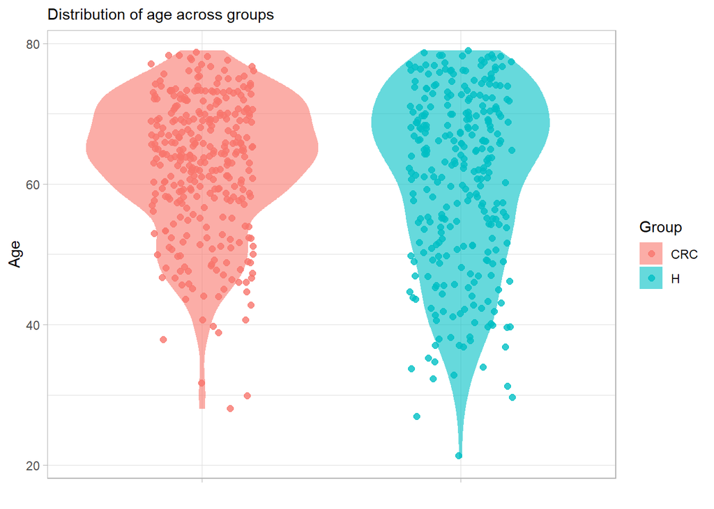

```r
samples |>
  mutate(cohort = case_when(
    group == "Healthy" ~ "H",
    group %in% c("MP", "Stage_0", "Stage_I_II", "Stage_III_IV") ~ "CRC",
    group == "HS" ~ "H"
  )) |>
  ggplot() +
  aes(x = cohort, y = age, color = cohort, fill = cohort) +
  geom_violin(alpha = 0.6, color = NA) +
  geom_point(position = position_jitter(width = 0.2), size = 2, alpha = 0.8) +
  labs(x = "", y = "Age", color = "Group", fill = "Group",
       subtitle = "Distribution of age across groups") +
  theme(
    axis.text.x = element_blank()
  )
```

**BMI**

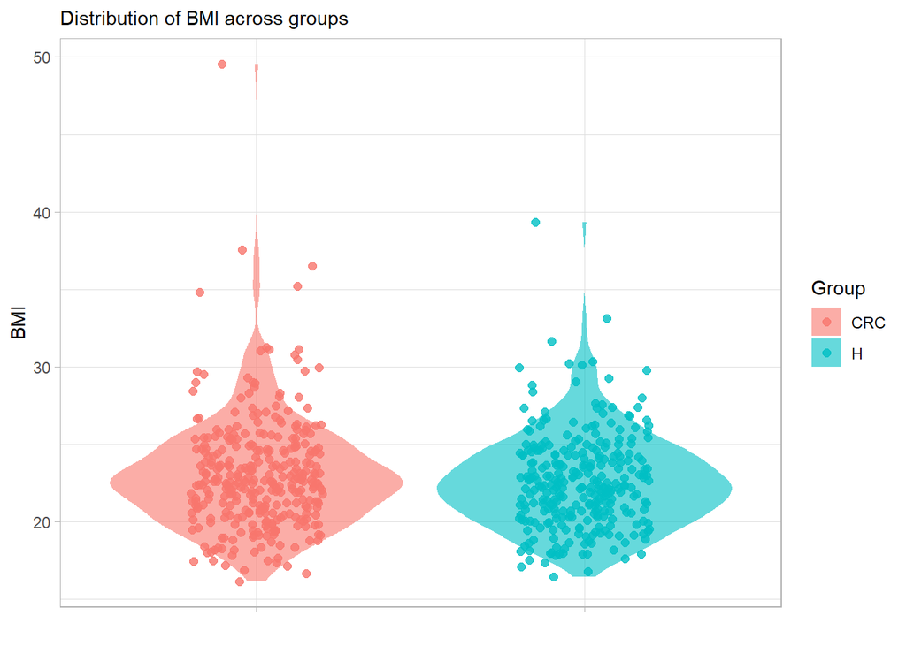

```r
samples |>
  mutate(cohort = case_when(
    group == "Healthy" ~ "H",
    group %in% c("MP", "Stage_0", "Stage_I_II", "Stage_III_IV") ~ "CRC",
    group == "HS" ~ "H"
  )) |>
  mutate(
    bmi = case_when(
      bmi == "NA" ~ NA_real_,
      TRUE ~ as.numeric(bmi)
    )
  ) |>
  ggplot() +
  aes(x = cohort, y = bmi, color = cohort, fill = cohort) +
  geom_violin(alpha = 0.6, color = NA) +
  geom_point(position = position_jitter(width = 0.2), size = 2, alpha = 0.8) +
  labs(x = "", y = "BMI", color = "Group", fill = "Group",
       subtitle = "Distribution of BMI across groups") +
  theme(
    axis.text.x = element_blank()
  )
```

**Gender**

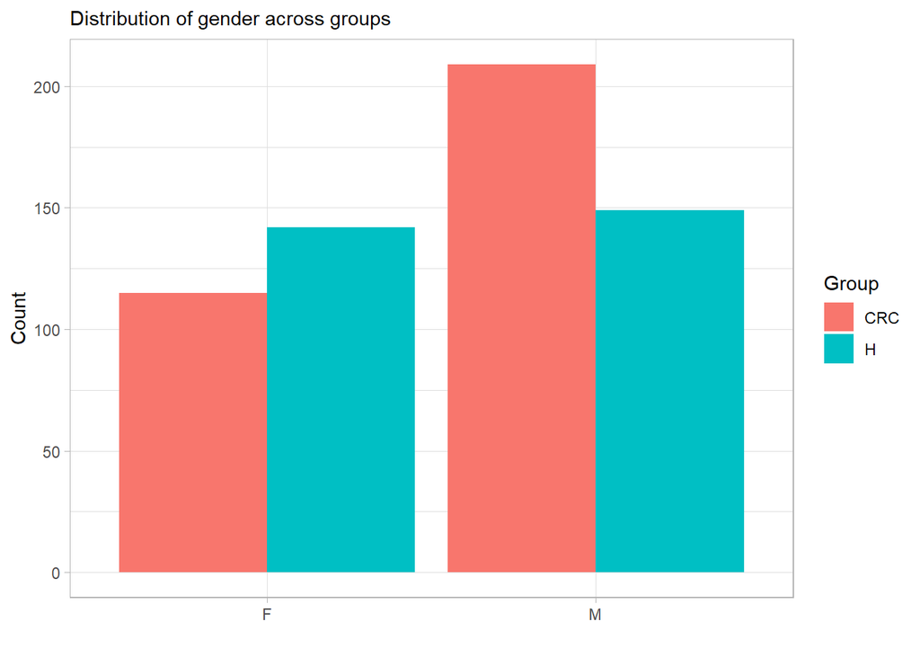

```r
samples |>
   mutate(cohort = case_when(
    group == "Healthy" ~ "H",
    group %in% c("MP", "Stage_0", "Stage_I_II", "Stage_III_IV") ~ "CRC",
    group == "HS" ~ "H"
  )) |>
  ggplot() +
  aes(x = gender, fill = cohort) +
  geom_bar(position = "dodge") +
  labs(x = "", y = "Count",fill = "Group",
       subtitle = "Distribution of gender across groups")
```

**Group**

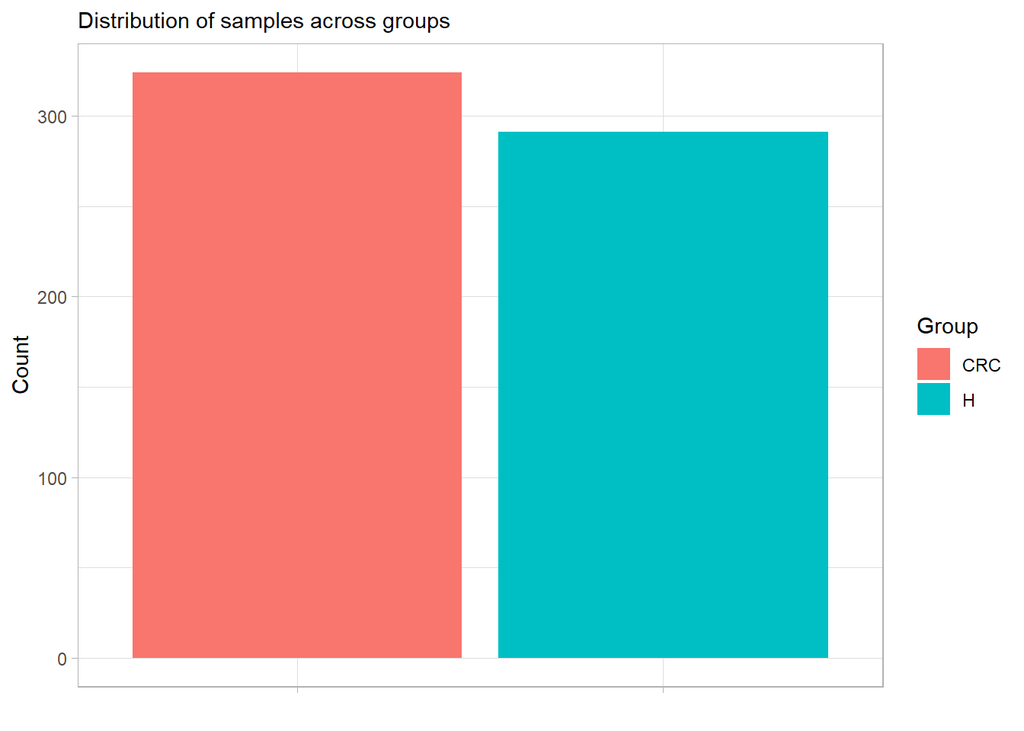

```r
  samples |>
   mutate(cohort = case_when(
    group == "Healthy" ~ "H",
    group %in% c("MP", "Stage_0", "Stage_I_II", "Stage_III_IV") ~ "CRC",
    group == "HS" ~ "H"
  )) |>
  ggplot() +
  aes(x = cohort, fill = cohort) +
  geom_bar(position = "dodge") +
  labs(x = "", y = "Count", fill = "Group",
       subtitle = "Distribution of samples across groups") +
  theme(
    axis.text.x = element_blank()
  )
```

We document the different levels of the variable `Group` below.

```r
metadata |>
  clean_names() |>
  select(subject_id, group) |>
  group_by(group) |>
  summarise(n = n()) |>
  gt(caption = "Health status of samples")
```

Health status of samples

| group | n |
| --- | --- |
| HS | 40 |
| Healthy | 251 |
| MP | 67 |
| Stage_0 | 73 |
| Stage_III_IV | 73 |
| Stage_I_II | 111 |

The selected variables are:

- `Subject_ID`: the sample ID, which will be set as row names.
- `Group`: the health status of the samples.

We filter the metadata to keep only the selected variables, set the sample IDs as row names, and document all the variables in a dictionary, documenting the original variable name, the new variable name, the description of the variable, the values it can take, and if it is kept for further analyses or not.

```r
samples <-
  metadata |>
  clean_names() |>
  select(subject_id, group) |>
  column_to_rownames("subject_id") |>
  mutate(group = group |> as.factor()) |>
  mutate(cohort = case_when(
    group == "Healthy" ~ "H",
    group %in% c("MP", "Stage_0", "Stage_I_II", "Stage_III_IV") ~ "CRC",
    group == "HS" ~ NA_character_
  ))
```

We filter samples for which we do not have a clear health status (i.e., samples with “HS” group).

```r
samples <- samples |> filter(!is.na(cohort))

samples |> glimpse()
```

```
Rows: 575
Columns: 2
$ group  <fct> Stage_I_II, Healthy, Healthy, Healthy, Healthy, Stage_0, Health…
$ cohort <chr> "CRC", "H", "H", "H", "H", "CRC", "H", "H", "H", "H", "H", "CRC…
```

We also filter abundance data to keep only samples for which we have a clear health status in the metadata.

```r
abundance <- abundance |> select(any_of(rownames(samples)))

abundance |> head() |> select(1:5)
```

```
                                      10021 10023        10025 10029 10031
Brucella pinnipedialis                    0     0 0.000000e+00     0     0
Vibrio sp. EJY3                           0     0 0.000000e+00     0     0
Aggregatibacter actinomycetemcomitans     0     0 0.000000e+00     0     0
Polymorphum gilvum                        0     0 0.000000e+00     0     0
Streptococcus pyogenes                    0     0 0.000000e+00     0     0
Prevotella pallens                        0     0 1.097468e-05     0     0
```

#### Creating a dictionary for metadata variables

> TODO: add dictionnary

### Documenting abundance distribution

We check if there are any singletons (i.e., taxa that are present in only one sample) in the dataset, and if so, we document them by showing the taxonomic annotation and the number of samples with this annotation.

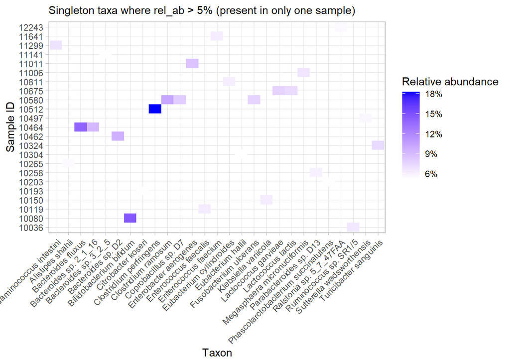

```r
abundance |>
  rownames_to_column("taxon") |>
  pivot_longer(-taxon, names_to = "sample_id", values_to = "rel_ab") |>
  filter(rel_ab > 0.05) |>
  group_by(taxon) |>
  mutate(singleton = ifelse(n() == 1, "Singleton", "Non-singleton")) |>
  ungroup() |>
  filter(singleton == "Singleton") |>
  ggplot() +
  aes(x = taxon, y = sample_id, fill = rel_ab) +
  geom_tile() +
  scale_fill_gradient(low = "white", high = "blue", labels = scales::label_percent(accuracy = 1)) +
  labs(x = "Taxon", y = "Sample ID", fill = "Relative abundance",
       subtitle = "Singleton taxa where rel_ab > 5% (present in only one sample)") +
  theme(
    axis.text.x = element_text(angle = 45, hjust = 1)
  )
```

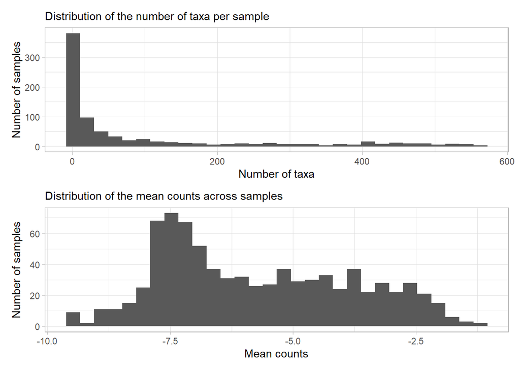

```r
abundance |>
  rownames_to_column("sample_id") |>
  pivot_longer(-sample_id, names_to = "taxon", values_to = "count") |>
  group_by(sample_id) |>
  mutate(rel_ab = count / sum(count)) |>
  ungroup() |>
  filter(rel_ab > 0) |>
  group_by(sample_id) |>
  summarise(n_taxa = n()) |>
  ggplot() +
  aes(x = n_taxa) +
  geom_histogram(bins = 30) +
  labs(x = "Number of taxa", y = "Number of samples",
       subtitle = "Distribution of the number of taxa per sample") +

abundance |>
  rownames_to_column("sample_id") |>
  pivot_longer(-sample_id, names_to = "taxon", values_to = "count") |>
  group_by(sample_id) |>
  summarise(mean_count = mean(count)) |>
  ggplot() +
  aes(x = mean_count |> log10()) +
  geom_histogram(bins = 30) +
  labs(x = "Mean counts", y = "Number of samples",
       subtitle = "Distribution of the mean counts across samples") +

  plot_layout(nrow = 2)
```

### Saving cleaned data into a `phyloseq` object

Finally, we can create the `phyloseq` object using the `otu_table`, `tax_table`, and `sample_data` functions from the `phyloseq` package.

```r
ps_crc <- phyloseq(
  otu_table(as.matrix(abundance), taxa_are_rows = TRUE),
  tax_table(as.matrix(taxonomy)),
  sample_data(samples)
)

ps_crc
```

```
phyloseq-class experiment-level object
otu_table()   OTU Table:         [ 837 taxa and 575 samples ]
sample_data() Sample Data:       [ 575 samples by 2 sample variables ]
tax_table()   Taxonomy Table:    [ 837 taxa by 8 taxonomic ranks ]
```

## CDI dataset (Ferretti et al., 2023)

For the analysis, we have the following datasets at our disposal:

- `CDI_mergedControl_samples.csv`: contains metadata for both control and CDI samples, in CSV format.
- `mOTU20_profiles_filteredCDI.csv`: contains abundance count data for stool samples, in CSV format.
- `motus_taxonomy.csv`: contains the taxonomic annotation for the features in the abundance data, in CSV format.

### Importing raw data

In the chunks below, we will import the metadata, abundance data, and taxonomic annotation for the CDI dataset.

```r
metadata <- read_csv(file.path(data_dir(), "01-raw-data/04-CDI", "CDI_mergedControl_samples.csv"))
abundance <- read_csv(file.path(data_dir(), "01-raw-data/04-CDI", "mOTU20_profiles_filteredCDI.csv"))
taxonomy <- read_csv(file.path(data_dir(), "01-raw-data/04-CDI", "motus_taxonomy.csv"))
```

**Note**

Interestingly, this dataset contains samples from different study (and thus different sequencing protocols).

#### Documenting the substudies protocols from which the samples were obtained

We document below the number of samples in each of the different studies included in the dataset.

```r
metadata |>
  janitor::clean_names() |>
  group_by(study) |>
  summarise(n = n()) |>
  gt(caption = "Number of samples per study")
```

Number of samples per study

| study | n |
| --- | --- |
| Kim_2020_CDI | 87 |
| Kumar_2017 | 13 |
| Langdon_2021_RCDI | 141 |
| Monaghan_2019_India | 93 |
| PRJNA420371_Alabama | 26 |
| Podlesny_2020_FMT_RCDI | 16 |
| Smillie_2018 | 26 |
| Stewart_2019 | 24 |
| Vincent_2016 | 96 |
| Watson_2021_FMT_RCDI | 12 |

Below, we document the study protocol for each of the studies included in the dataset, by looking at the original articles associated with each of the studies.

- [Kim et al., 2020 (Nature scientific reports)](https://www.nature.com/articles/s41598-020-74090-0): through July 2016 to June 2018, individuals diagnosed with CDI at Hanyang University Seoul Hospital were screened, and CDI patients who could provide over 50 g of faeces sample from CDI diagnosed stool sample were enrolled in the study.
- [Kumar et al., 2017 (Nature njp biofilms and microbiome)](https://www.nature.com/articles/s41522-017-0020-7): to complete

> TODO: complete this section

**Note**

We see here that we do not have the complete taxonomy lineage for the features in the abundance data, but only the last available taxonomic level (e.g., species). This will make it difficult to filter the dataset to keep only bacterial species, since we do not have the taxonomic annotation for the kingdom level. *Can we assume that all species are bacteria and go ahead with the analyses?*

### Creating a taxonomic annotation

First, we need to filter taxonomy data to merge taxon with the same taxonomic annotation, and to keep only one row for each taxon, with the taxonomic annotation as row names. Additionally, we fill the taxonomic levels based on the taxonomic annotation.

```r
taxonomy <-
  taxonomy |>
  mutate(
    taxon_name = coalesce(
      str_remove(mOTU_name, "\\[.*\\]")),
    kingdom = "k_Bacteria",
    phylum = NA,
    class = NA,
    order = NA,
    family = NA,
    genus = str_c("g_", word(taxon_name, 1)),
    species = case_when(
      word(taxon_name, 2) == "sp." ~ NA,
      is.na(word(taxon_name, 2)) ~ NA,
      TRUE ~ str_c("s_", word(taxon_name, 2))
    ),
    taxon = str_c(taxon_name)
  ) |>
  select(kingdom, phylum, class, order, family, genus, species, taxon, taxon_name)
```

We now filter the abundance data by first replacing the feature names in the abundance data with the taxonomic annotation from the taxonomy data, and then summing the counts of features with the same taxonomic annotation to get the count of the taxon.

```r
abundance <-
  abundance |>
  filter(X1 != "-1") |>
  column_to_rownames(var = names(abundance)[1]) |>
  as.data.frame() |>
  bind_cols(taxonomy |> select(taxon_name)) |>
  group_by(taxon_name) |>
  summarise(across(everything(), sum)) |>
  column_to_rownames("taxon_name") |>
  as.data.frame()
```

We filter the taxonomy data to keep only one row for each taxon, and to set the taxon names as row names.

```r
taxonomy <-
  taxonomy |>
  distinct(taxon_name, .keep_all = TRUE) |>
  column_to_rownames("taxon")

taxonomy |> glimpse()
```

```
Rows: 5,033
Columns: 8
$ kingdom    <chr> "k_Bacteria", "k_Bacteria", "k_Bacteria", "k_Bacteria", "k_…
$ phylum     <lgl> NA, NA, NA, NA, NA, NA, NA, NA, NA, NA, NA, NA, NA, NA, NA,…
$ class      <lgl> NA, NA, NA, NA, NA, NA, NA, NA, NA, NA, NA, NA, NA, NA, NA,…
$ order      <lgl> NA, NA, NA, NA, NA, NA, NA, NA, NA, NA, NA, NA, NA, NA, NA,…
$ family     <lgl> NA, NA, NA, NA, NA, NA, NA, NA, NA, NA, NA, NA, NA, NA, NA,…
$ genus      <chr> "g_Abiotrophia", "g_Acaricomes", "g_Acaryochloris", "g_Acet…
$ species    <chr> "s_defectiva", "s_phytoseiuli", "s_marina", "s_cellulolytic…
$ taxon_name <chr> "Abiotrophia defectiva ", "Acaricomes phytoseiuli ", "Acary…
```

### Documenting available metadata

We document the metadata variables to select the relevant ones for our analyses.

**Age group**

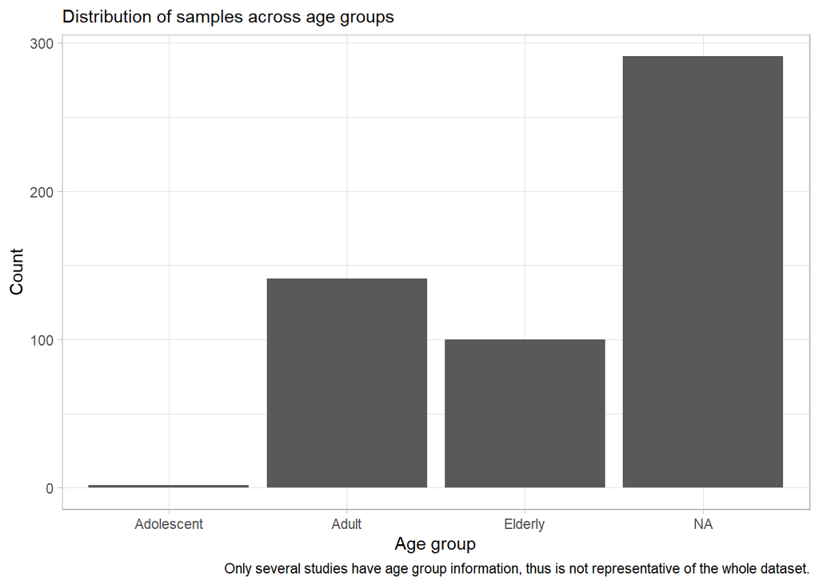

```r
metadata |>
  clean_names() |>
  ggplot() +
  aes(x = age_group) +
  geom_bar() +
  labs(x = "Age group", y = "Count", fill = "Age group",
       subtitle = "Distribution of samples across age groups",
       caption = "Only several studies have age group information, thus is not representative of the whole dataset.")
```

**Geography**

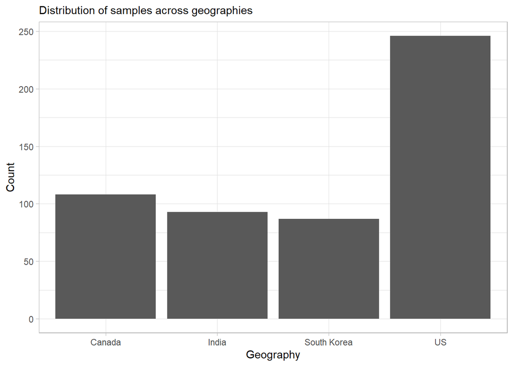

```r
metadata |>
  clean_names() |>
  ggplot() +
  aes(x = geography) +
  geom_bar() +
  labs(x = "Geography", y = "Count", fill = "Geography",
       subtitle = "Distribution of samples across geographies")
```

**Antibiotics**

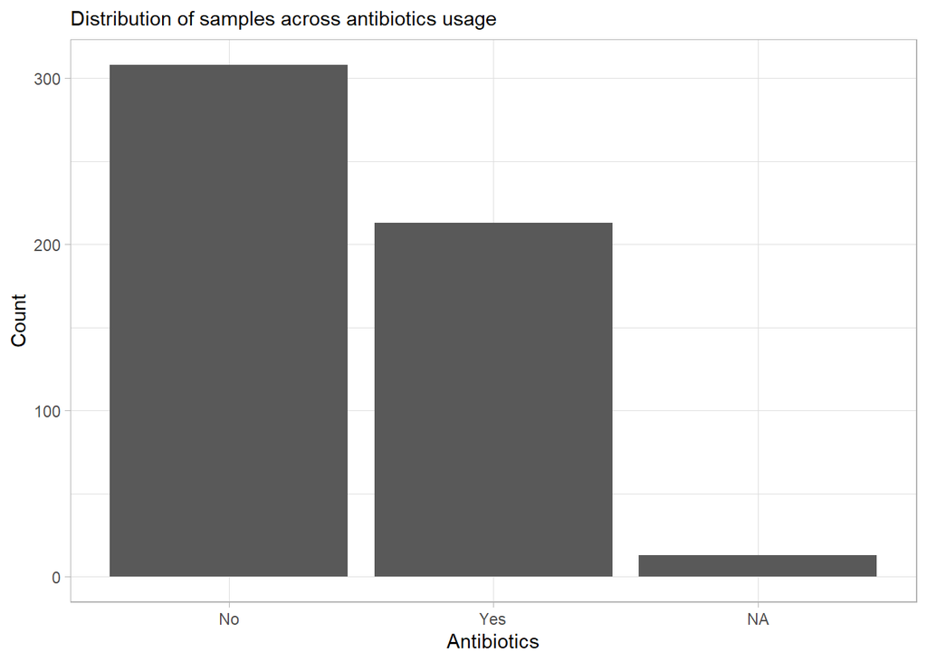

```r
metadata |>
  clean_names() |>
  ggplot() +
  aes(x = abx) +
  geom_bar() +
  labs(x = "Antibiotics", y = "Count", fill = "Antibiotics",
       subtitle = "Distribution of samples across antibiotics usage")
```

**CDI diagnosis**

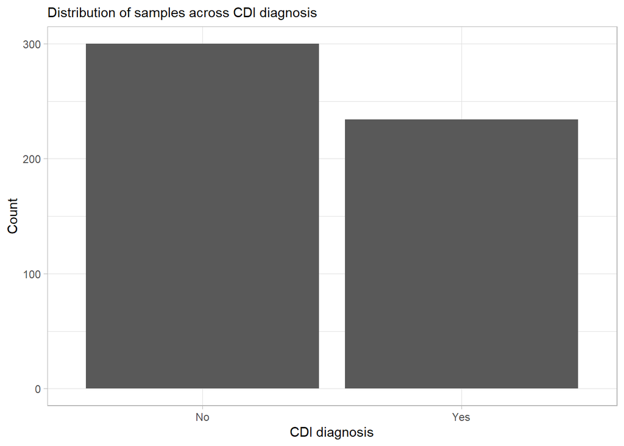

```r
metadata |>
  clean_names() |>
  ggplot() +
  aes(x = cdi) +
  geom_bar() +
  labs(x = "CDI diagnosis", y = "Count", fill = "CDI diagnosis",
       subtitle = "Distribution of samples across CDI diagnosis")
```

**C.difficile presence**

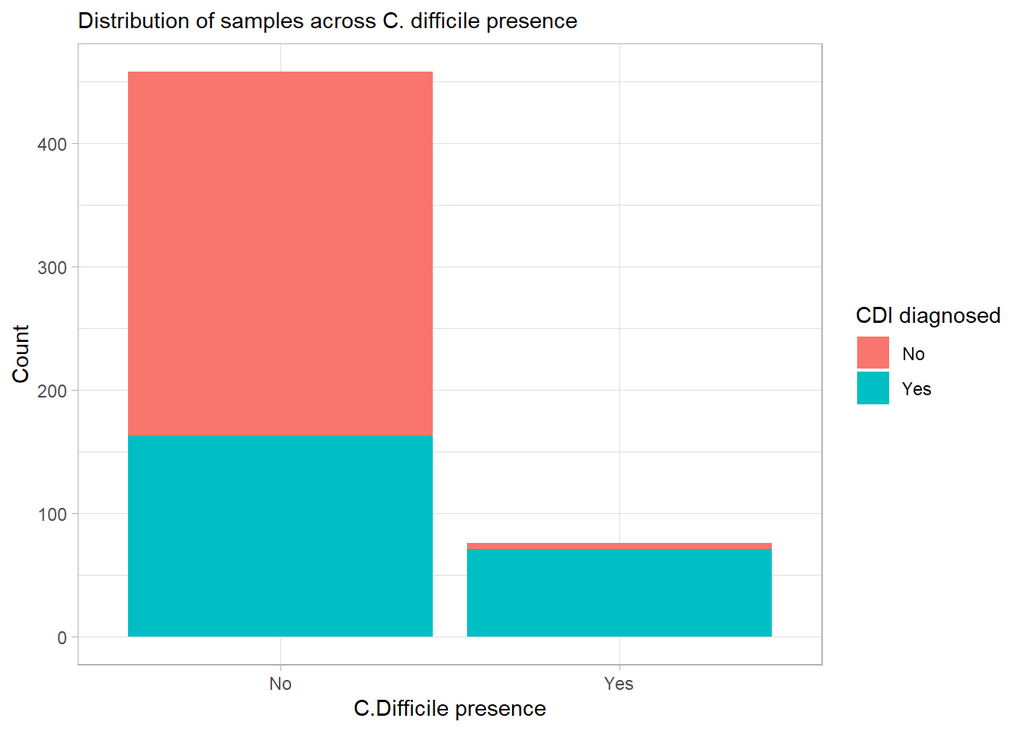

```r
metadata |>
  clean_names() |>
  ggplot() +
  aes(x = cdiff, fill = cdi) +
  geom_bar() +
  labs(x = "C.Difficile presence", y = "Count", fill = "CDI diagnosed",
       subtitle = "Distribution of samples across C. difficile presence")
```

#### Documenting raw metadata variables in a dictionary

> TO DO: Create a dictionary to document original variable names, new variable names, description of the variables, values they can take, and if they are kept for further analyses or not.

We will now filter the metadata to keep only relevant variables for our analyses, and to set the sample IDs as row names. The selected variables are:

- `Samples`: the sample ID, which will be set as row names.
- `Gut_sample_type`: the type of the sample, here only “stool” samples are available.
- `Status`: the health status of the sample, with two levels: “Healthy” and “Diseased”.
- `subject_disease_status`: gives further information about the health status of the samples.

```r
samples <-
  metadata |>
  clean_names() |>
  select(samples, gut_sample_type, status, subject_disease_status) |>
  column_to_rownames("samples")
```

#### Filtering disease status to keep only CDI samples

We document the variable `subject_disease_status` to see how many samples have been diagnosed with other gut-related diseases.

```r
samples |>
  group_by(status) |>
  summarise(n = n()) |>
  gt(caption = "Number of healthy and diseased samples")
```

Number of healthy and diseased samples

| status | n |
| --- | --- |
| Diseased | 348 |
| Healthy | 186 |

```r
samples |>
  group_by(status, subject_disease_status) |>
  summarise(n = n()) |>
  gt(caption = "Health status of healthy and diseased samples")
```

Health status of healthy and diseased samples

| subject_disease_status | n |
| --- | --- |
| Diseased |  |
| Asymptomatically colonized admitted for Gangrene | 1 |
| Asymptomatically colonized admitted for cellulitis | 1 |
| Asymptomatically colonized admitted for pneumonia | 1 |
| Asymptomatically colonized with c. difficile, admitted to the hospital for osteoarthritis | 1 |
| CDI | 202 |
| Diarrhea | 54 |
| hospitalized patient with no specific diagnosis | 88 |
| Healthy |  |
| CTR | 186 |

**Warning**

Based on the documentation of the variable `subject_disease_status`, we see that all of the “Healthy” samples are control and none of them have a gut-related disease. However, among “Diseased” samples, only 202 among the 348 diseased samples have been diagnosed with CDI. *Do we keep all the “Diseased” samples for our analyses, or do we only keep the 202 samples diagnosed with CDI?*.

**Note**

I could have also kept some other diseased samples, such as those “Asymptotically colonized”, but there are only four of them.

```r
# samples <- samples |> filter(subject_disease_status == "CDI" | subject_disease_status == "CTR")
```

We filter the abundance data to keep only the samples for which we have the corresponding filtered metadata.

```r
# abundance <- abundance |>
#   select(any_of(rownames(samples)))
```

### Rarefaction and filtering of low-abundance taxa

We will then rarefy the CDI dataset, so that all samples have the same sequencing depth, and filter out low-abundance taxa. We will use the `rrarefy` function from the `vegan` package to perform rarefaction.

First, we separate the dataset into two groups: “healthy” and “diseased” so that rarefaction (and prevalence filtering) is performed separately for the two groups, to avoid biasing the results by removing more samples from one group than the other.

```r
tmp <-
  abundance |>
  rownames_to_column("taxon") |>
  pivot_longer(-taxon, names_to = "sample_id", values_to = "count") |>
  left_join(
    samples |> rownames_to_column("sample_id") |> select(sample_id, status),
    by = join_by(sample_id)
  )
```

```r
tmp_healthy <- tmp |> filter(status == "Healthy")
tmp_diseased <- tmp |> filter(status == "Diseased")
```

We show the distribution of sequencing depth across samples, to choose a rarefaction depth.

**Note**

Note that a classical rarefaction threshold would be to simply take the median depth, but in this case, we choose to take the median depth divided by 2, to keep more samples in the dataset.

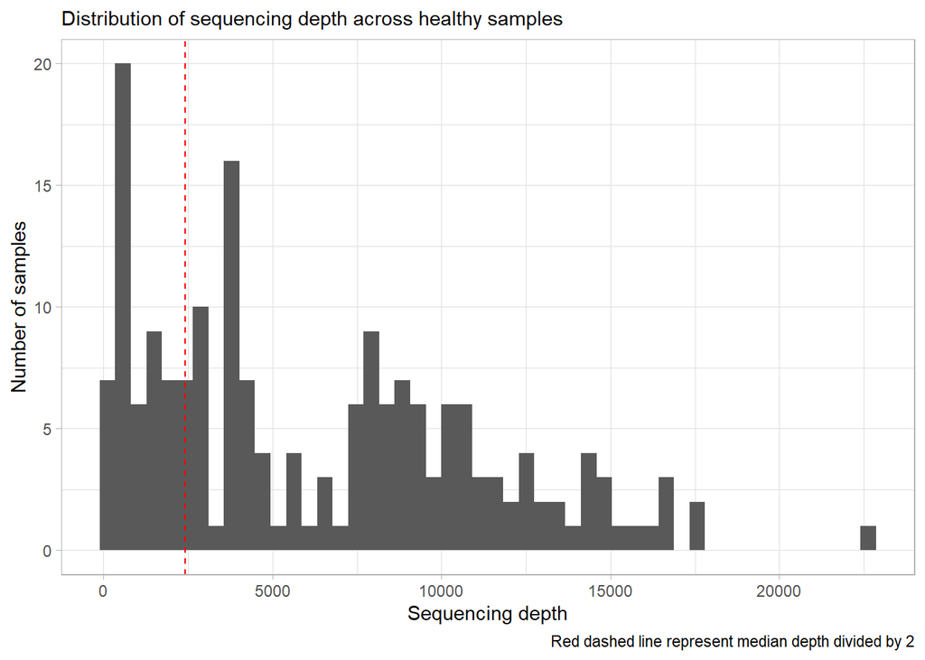

```r
tmp_healthy |>
  group_by(sample_id) |>
  summarise(depth = sum(count)) |>
  ggplot(aes(x = depth)) +
  geom_histogram(bins = 50) +
  geom_vline(aes(xintercept = median(depth)/2), color = "red", linetype = "dashed") +
  labs(x = "Sequencing depth", y = "Number of samples", caption = "Red dashed line represent median depth divided by 2",
       subtitle = "Distribution of sequencing depth across healthy samples")
```

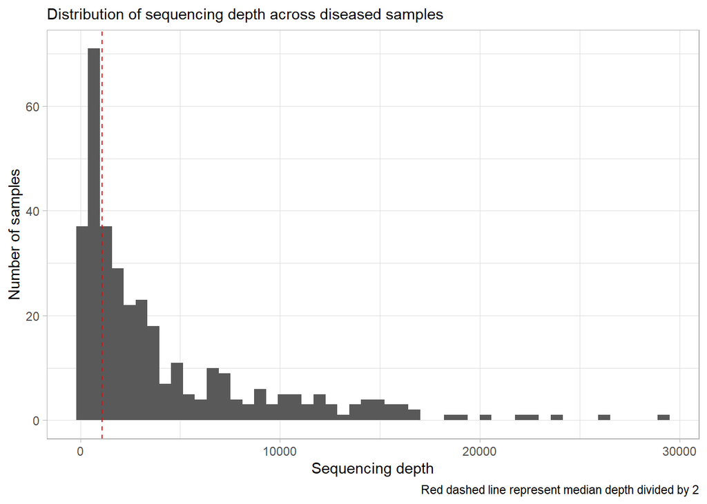

```r
tmp_diseased |>
  group_by(sample_id) |>
  summarise(depth = sum(count)) |>
  ggplot(aes(x = depth)) +
  geom_histogram(bins = 50) +
  geom_vline(aes(xintercept = median(depth)/2), color = "red", linetype = "dashed") +
  labs(x = "Sequencing depth", y = "Number of samples", caption = "Red dashed line represent median depth divided by 2",
       subtitle = "Distribution of sequencing depth across diseased samples")
```

We will rarefy at a depth of median(depth)/2; this is done in the chucks below, where we also filters out samples with depth < median(depth)/2.

```r
# for healthy samples

tmp_depth <- tmp_healthy |>
  group_by(sample_id) |>
  summarise(depth = sum(count), .groups = "drop")

min_depth <- median(tmp_depth$depth) / 2 |> round()

samples_to_keep <- tmp_depth |>
  filter(depth >= min_depth) |>
  pull(sample_id)

cat("Removing", sum(tmp_depth$depth < min_depth), "samples below depth", round(min_depth))
```

```
Removing 54 samples below depth 2421
```

```r
tmp_rarefied_healthy <- tmp_healthy |>
    filter(sample_id %in% samples_to_keep) |>
    select(sample_id, taxon, count) |>
    pivot_wider(names_from = taxon, values_from = count, values_fill = 0) |>
    column_to_rownames("sample_id") |>
    rrarefy(sample = min_depth) |>
    as.data.frame() |>
    rownames_to_column("sample_id") |>
    pivot_longer(-sample_id, names_to = "taxon", values_to = "count") |>
    group_by(sample_id) |>
    mutate(rel_ab = count / sum(count)) |>
    ungroup()
```

```r
# for diseased samples

tmp_depth <- tmp_diseased |>
  group_by(sample_id) |>
  summarise(depth = sum(count), .groups = "drop")

min_depth <- median(tmp_depth$depth) / 2 |> round()

samples_to_keep <- tmp_depth |>
  filter(depth >= min_depth) |>
  pull(sample_id)

cat("Removing", sum(tmp_depth$depth < min_depth), "samples below depth", round(min_depth))
```

```
Removing 114 samples below depth 1085
```

```r
tmp_rarefied_diseased <- tmp_diseased |>
    filter(sample_id %in% samples_to_keep) |>
    select(sample_id, taxon, count) |>
    pivot_wider(names_from = taxon, values_from = count, values_fill = 0) |>
    column_to_rownames("sample_id") |>
    rrarefy(sample = min_depth) |>
    as.data.frame() |>
    rownames_to_column("sample_id") |>
    pivot_longer(-sample_id, names_to = "taxon", values_to = "count") |>
    group_by(sample_id) |>
    mutate(rel_ab = count / sum(count)) |>
    ungroup()
```

We convert the rarefied data back to wide format, and we merge the healthy and diseased datasets back together. Additionally, we filter the abundance data to only keep taxa for which the total count across samples is greater than 0, to remove taxa that are not present in any sample after rarefaction.

```r
abundance <- bind_rows(tmp_rarefied_healthy, tmp_rarefied_diseased) |>
  select(sample_id, taxon, count) |>
  pivot_wider(names_from = taxon, values_from = count, values_fill = 0) |>
  column_to_rownames("sample_id") |>
  as.data.frame() |>
  select(where(~ sum(.) > 0))

abundance |> head() |> select(1:5)
```

```
             Abiotrophia defectiva  Acholeplasma sp. CAG:878
SAMN16678993                      0                         0
SAMN16678997                      0                         0
SAMN16679015                      0                         0
SAMN17918336                      0                         0
SAMN17918360                      0                         0
SAMEA6104885                      0                         0
             Achromobacter insuavis/xylosoxidans  Acidaminococcus fermentans
SAMN16678993                                    0                           0
SAMN16678997                                    0                           0
SAMN16679015                                    0                           0
SAMN17918336                                    0                           0
SAMN17918360                                    0                           0
SAMEA6104885                                    0                           0
             Acidaminococcus intestini
SAMN16678993                          0
SAMN16678997                          0
SAMN16679015                          0
SAMN17918336                          0
SAMN17918360                          0
SAMEA6104885                          0
```

Since several samples have been removed after rarefaction, we also need to filter the metadata to keep only the samples for which we have abundance data after rarefaction.

> TODO: Document the taxa for which there are no more counts after rarefaction, and check for other datasets as well.

```r
samples <- samples |> filter(rownames(samples) %in% rownames(abundance))
```

We also filter the taxonomy table to keep only taxa for which we have abundance data after rarefaction.

```r
taxonomy <- taxonomy |> filter(rownames(taxonomy) %in% colnames(abundance))
```

### Saving cleaned data into a `phyloseq` object

We finally create the `phyloseq` object using the `otu_table`, `tax_table`, and `sample_data` functions from the `phyloseq` package.

```r
ps_cdi <- phyloseq(
  otu_table(as.matrix(abundance), taxa_are_rows = FALSE),
  tax_table(as.matrix(taxonomy)),
  sample_data(samples)
)

ps_cdi
```

```
phyloseq-class experiment-level object
otu_table()   OTU Table:         [ 874 taxa and 366 samples ]
sample_data() Sample Data:       [ 366 samples by 3 sample variables ]
tax_table()   Taxonomy Table:    [ 874 taxa by 8 taxonomic ranks ]
```

# Alternative analysis for dysbiotic cohorts

In this section, we will first import the relevant datasets from the dysbiotic cohorts (that is, those pertaining to IBD, IBS, CRC, and CDI), and then perform several descriptive analyses for each of those datasets. The analyses will include: data cleaning, taxonomic aggregation (if necessary) and rarefaction.

We will transform each dataset into a `phyloseq` object, before merging them into a `MultiAssayExperiment` object in the last section. For this we need:

- abundance data, a matrix of relative abundance with samples as rows and features (taxa) as columns.
- taxonomy data, a data frame with features (taxa) as rows and taxonomic levels as columns.
- samples data, a data frame with samples as rows and metadata variables as columns.

> TODO: Create dictionaries for metadata variables for each dataset, to keep track of the meaning of each variable and the values they can take, previous and new name, and if it is kept for further analysis or not.

## IBD dataset (Lloyd-Price et al. 2019)

The inflammatory bowel disease (IBD) dataset was obtained from the [IBDMDB](https://ibdmdb.org/), with the results published in Lloyd-Price et al. (2019). The authors of the Science paper did not provide information to which study name the IBD dataset comes from, so the HMP2 study was chosen, which seems like a reasonable choice since it is the most recent study on this page.

Stool samples were initially collected from 132 participants at multiple time points. Specifically, samples were collected at baseline (that is after the initial colonoscopy, which was used to stratify participants into healthy controls, Crohn’s disease (CD) patients, and ulcerative colitis (UC) patients), and then every 2 weeks for 1 years.

Metagenomics (MGX) were performed on 1638 stool samples; DNA was quantified, normalized, and used to prepare sequencing libraries with the Nextera XT kit. Libraries were pooled, quality-checked, and sequenced on an Illumina HiSeq platform to generate ~10 million paired-end reads per sample. Raw sequencing data was then demultiplexed and converted to standard file formats (BAM and FASTQ files) using the Picard suite.

### Importing raw data

In the chunks below, we import the metadata and species count data for the IBD dataset.

> TODO: Document the names of the files they imported in their analysis

```r
metadata <- read_tsv(file.path(data_dir(), "01-raw-data/01bis-IBD", "metadata.tsv"))
abundance <- read_tsv(file.path(data_dir(), "01-raw-data/01bis-IBD", "species.counts.tsv"))
```

There are 382 samples and 42872 features in the original dataset.

#### Reorganizing the taxonomy in the abundance data and creating a taxonomy table

```r
abundance <- abundance |> column_to_rownames("Sample")
```

```r
taxonomy <-
  tibble(full_name = names(abundance)) |>
  mutate(
    domain = str_extract(full_name, "d__[^;]+"),
    phylum = str_extract(full_name, "p__[^;]+"),
    class = str_extract(full_name, "c__[^;]+"),
    order = str_extract(full_name, "o__[^;]+"),
    family = str_extract(full_name, "f__[^;]+"),
    genus = str_extract(full_name, "g__[^;]+"),
    species = str_extract(full_name, "s__[^;]+")
  ) |>
  mutate(
    taxon = coalesce(
      species, genus, family, order, class, phylum, domain
    )
  ) |>
  mutate(
    taxon_name = coalesce(
      str_remove(species, "s__"),
      str_c(str_remove(genus, "g__"), " (g)"),
      str_c(str_remove(family, "f__"), " (f)"),
      str_c(str_remove(order, "o__"), " (o)"),
      str_c(str_remove(class, "c__"), " (c)"),
      str_c(str_remove(phylum, "p__"), " (p)"),
      str_c(str_remove(domain, "d__"), " (d)")
    )
  ) |>
  filter(domain == "d__Bacteria") |>
  select(-full_name)
```

```r
# Checking "noname" and "unclassified" annotations in the taxonomy data (table)

taxonomy |>
  summarise(across(c(domain, phylum, class, order, family, genus, species), list(
    unclassified = ~ sum(str_detect(., "_unclassified"), na.rm = TRUE),
    noname = ~ sum(str_detect(., "_noname"), na.rm = TRUE)
  ))) |>
  pivot_longer(everything(), names_to = c("taxonomic_level", "annotation"), names_sep = "_") |>
  pivot_wider(names_from = annotation, values_from = value) |>
  gt(caption = "Number of unclassified and noname annotations across taxonomic levels in the taxonomy data")
```

Number of unclassified and noname annotations across taxonomic levels in the taxonomy data

| taxonomic_level | unclassified | noname |
| --- | --- | --- |
| domain | 0 | 0 |
| phylum | 0 | 0 |
| class | 0 | 0 |
| order | 0 | 0 |
| family | 0 | 0 |
| genus | 0 | 0 |
| species | 0 | 0 |

**Note**

Contrary to the IBD dataset from the IBDMBD website, this dataset does not contain any “unclassified” or “noname” annotations in the taxonomy data.

```r
# replacing cleaned names in abundance table

abundance <- abundance |> set_names(taxonomy$taxon_name)

# set taxon names as row names in taxonomy table

taxonomy <- taxonomy |> column_to_rownames("taxon_name")
```

#### Documenting the metadata variables

```r
samples <- metadata |> clean_names()
samples |> glimpse()
```

```
Rows: 382
Columns: 24
$ dataset             <chr> "iHMP_IBDMDB_2019", "iHMP_IBDMDB_2019", "iHMP_IBDM…
$ sample              <chr> "CSM5MCVN", "CSM5MCWE", "CSM5MCX3", "CSM5MCXL", "C…
$ subject             <chr> "C3002", "C3009", "C3006", "C3004", "C3005", "C300…
$ study_group         <chr> "CD", "CD", "UC", "UC", "UC", "CD", "CD", "CD", "C…
$ gender              <chr> "Female", "Male", "Male", "Female", "Female", "Fem…
$ doi                 <chr> "10.1038/s41586-019-1237-9", "10.1038/s41586-019-1…
$ publication_name    <chr> "Multi-omics of the gut microbial ecosystem in inf…
$ consent_age         <dbl> 76, 56, 32, 47, 76, 53, 37, 43, 56, 50, 32, 45, 76…
$ age_units           <chr> "Years", "Years", "Years", "Years", "Years", "Year…
$ site_sub_coll       <chr> "C3002C9", "C3009C5", "C3006C9", "C3004C9", "C3005…
$ project_specific_id <dbl> 3002, 3009, 3006, 3004, 3005, 3008, 3012, 3001, 30…
$ week_num            <dbl> 16, 8, 15, 16, 15, 16, 6, 28, 16, 8, 8, 9, 26, 32,…
$ date_of_receipt     <date> 2014-08-19, 2014-09-03, 2014-09-16, 2014-09-03, 2…
$ interval_days       <dbl> 13, 15, 13, 15, 13, 14, 14, 13, 14, 13, 13, 20, 13…
$ visit_num           <dbl> 13, 8, 13, 13, 13, 13, 7, 20, 13, 8, 8, 8, 19, 22,…
$ site_name           <chr> "Cedars-Sinai", "Cedars-Sinai", "Cedars-Sinai", "C…
$ age_at_diagnosis    <dbl> 47, 44, 24, 33, 58, 24, 30, 28, 44, 37, 12, 8, 47,…
$ antibiotics         <chr> "No", "No", "No", "No", "No", "Yes", "No", "No", "…
$ race                <chr> "White", "White", "White", "White", "White", "Whit…
$ fecalcal            <dbl> 15.97901, 20.64059, 12.69817, 14.82410, 229.04730,…
$ bmi_at_baseline     <dbl> NA, NA, 20.1, NA, 30.9, 21.7, 46.7, NA, NA, 22.4, …
$ height_at_baseline  <dbl> NA, NA, 180, NA, 165, 165, 170, NA, NA, 165, 152, …
$ weight_at_baseline  <dbl> NA, NA, 65, NA, 84, 59, 135, NA, NA, 61, 57, 70, N…
$ smoking_status      <chr> NA, NA, "Never smoked", NA, "Former smoker", NA, "…
```

```r
# set sample names as row names in metadata table

samples <- samples |> column_to_rownames("sample")
```

### Saving cleaned data into a `phyloseq` object

Finally, we can create the `phyloseq` object using the `otu_table`, `tax_table`, and `sample_data` functions from the `phyloseq` package.

```r
ps_ibd_alt <- phyloseq(
  otu_table(as.matrix(abundance), taxa_are_rows = FALSE),
  tax_table(as.matrix(taxonomy)),
  sample_data(samples)
)

ps_ibd_alt
```

```
phyloseq-class experiment-level object
otu_table()   OTU Table:         [ 42871 taxa and 382 samples ]
sample_data() Sample Data:       [ 382 samples by 23 sample variables ]
tax_table()   Taxonomy Table:    [ 42871 taxa by 8 taxonomic ranks ]
```

## IBS dataset (Mars et al., 2020)

The irritable bowel syndrome (IBS) dataset in Mars et al. (2020) was obtained from [Mendeley data](https://data.mendeley.com/datasets/29n2z5r5ph/3) plateform.

Metagenomics were performed for 474 stool samples recolted from 77 participants, separated into healthy controls (H), constipation predominant (IBS-C), diarrhea predominant (IBS-D), or mixed (IBS-M). DNA was extracted from stool samples using the QIAGEN PowerSoil kit and quantified by NanoDrop and PicoGreen assays. Shotgun metagenomic libraries were prepared using a modified Nextera XT protocol and sequenced on either a HiSeq 2500 or NextSeq platform with single-end reads. Samples from three cohorts were randomly distributed across two sequencing runs to reduce batch effects. Reads were trimmed to 100 bp and aligned to a prokaryotic reference genome collection at 97% identity using BURST, with low-depth samples (< 10,000 reads) removed. Functional profiles were generated using KEGG Orthology annotations, and low-abundance gene estimates were further improved using SHOGUN.

### Importing raw data

```r
metadata <- read_tsv(file.path(data_dir(), "01-raw-data/02bis-IBS", "metadata.tsv"))
abundance <- read_tsv(file.path(data_dir(), "01-raw-data/02bis-IBS", "species.counts.tsv"))
```

#### Reorganizing the taxonomy in the abundance data and creating a taxonomy table

```r
abundance <- abundance |> column_to_rownames("Sample")
```

```r
taxonomy <-
  tibble(full_name = names(abundance)) |>
  mutate(
    domain = str_extract(full_name, "d__[^;]+"),
    phylum = str_extract(full_name, "p__[^;]+"),
    class = str_extract(full_name, "c__[^;]+"),
    order = str_extract(full_name, "o__[^;]+"),
    family = str_extract(full_name, "f__[^;]+"),
    genus = str_extract(full_name, "g__[^;]+"),
    species = str_extract(full_name, "s__[^;]+")
  ) |>
  mutate(
    taxon = coalesce(
      species, genus, family, order, class, phylum, domain
    )
  ) |>
  mutate(
    taxon_name = coalesce(
      str_remove(species, "s__"),
      str_c(str_remove(genus, "g__"), " (g)"),
      str_c(str_remove(family, "f__"), " (f)"),
      str_c(str_remove(order, "o__"), " (o)"),
      str_c(str_remove(class, "c__"), " (c)"),
      str_c(str_remove(phylum, "p__"), " (p)"),
      str_c(str_remove(domain, "d__"), " (d)")
    )
  ) |>
  filter(domain == "d__Bacteria") |>
  select(-full_name)
```

Same as the previous dataset, there are no “unclassified” or “noname” annotations in the taxonomy data.

```r
# replacing cleaned names in abundance table

abundance <- abundance |> set_names(taxonomy$taxon_name)

# set taxon names as row names in taxonomy table

taxonomy <- taxonomy |> column_to_rownames("taxon_name")
```

#### Documenting the metadata variables

```r
samples <- metadata |> clean_names()
samples |> glimpse()
```

```
Rows: 444
Columns: 25
$ dataset                                    <chr> "MARS_IBS_2020", "MARS_IBS_…
$ sample                                     <chr> "1.T.0", "1.T.1", "1.T.2", …
$ subject                                    <dbl> 10007539, 10007539, 1000753…
$ study_group                                <chr> "H", "H", "H", "H", "H", "H…
$ age                                        <dbl> 36, 36, 36, 36, 36, 36, 36,…
$ age_units                                  <chr> "Years", "Years", "Years", …
$ gender                                     <chr> "Female", "Female", "Female…
$ bmi                                        <dbl> 19.73, 19.73, 19.73, 19.73,…
$ doi                                        <chr> "10.1016/j.cell.2020.08.007…
$ publication_name                           <chr> "Longitudinal Multi-omics R…
$ timepoint                                  <chr> "0", "1", "2", "3", "4", "5…
$ id_on_tube                                 <dbl> 1, 1, 1, 1, 1, 1, 1, 10, 10…
$ survey_event                               <chr> "demo_base", "subj", "coor_…
$ survey_event_date                          <dbl> 41901, 41927, 41960, 41991,…
$ ibs_symptom_severity_1_500                 <dbl> NA, NA, NA, NA, NA, NA, NA,…
$ effect_on_life_in_general_0_100            <dbl> NA, NA, NA, NA, NA, NA, NA,…
$ flare                                      <chr> NA, NA, NA, NA, NA, NA, NA,…
$ flare_timepoint_y                          <dbl> NA, NA, NA, NA, NA, NA, NA,…
$ antibiotics                                <chr> "no", "no", "no", "no", "no…
$ which_abx                                  <chr> NA, NA, NA, NA, NA, NA, NA,…
$ antibiotic_in_the_past_month_1_no_2_yes    <dbl> NA, 1, 1, 1, 1, 1, 1, NA, 1…
$ antibiotic_used                            <chr> NA, NA, NA, NA, NA, NA, NA,…
$ x_probiotic_in_the_past_2_weeks_1_no_2_yes <dbl> NA, 2, 2, 2, 2, 2, 2, NA, 2…
$ probiotic_used                             <chr> NA, "Greek_yogurt_3_times_p…
$ unique_id                                  <chr> "10007539_0", "10007539_1",…
```

```r
# set sample names as row names in metadata table

samples <- samples |> column_to_rownames("unique_id")

# modify abundance table to have the same sample names as in the metadata table

abundance <- abundance |> magrittr::set_rownames(rownames(samples))
```

### Saving cleaned data into a `phyloseq` object

Finally, we can create the `phyloseq` object using the `otu_table`, `tax_table`, and `sample_data` functions from the `phyloseq` package.

```r
ps_ibs_alt <- phyloseq(
  otu_table(as.matrix(abundance), taxa_are_rows = FALSE),
  tax_table(as.matrix(taxonomy)),
  sample_data(samples)
)

ps_ibs_alt
```

```
phyloseq-class experiment-level object
otu_table()   OTU Table:         [ 11513 taxa and 444 samples ]
sample_data() Sample Data:       [ 444 samples by 24 sample variables ]
tax_table()   Taxonomy Table:    [ 11513 taxa by 8 taxonomic ranks ]
```

## CRC dataset (Yachida et al., 2019)

The colorectal cancer (CRC) dataset in Yashida et al. (2019) was obtained from the DDBJ Sequence Read Archive (DRA) under the names DRA006684 and DRA008156; however, those are raw sequencing data, and the authors mentioned having used only processed datasets.

Processed datasets seems to be available as [Supplementary Tables](https://www.nature.com/articles/s41591-019-0458-7#Sec23), therefore these will be used for the subsequent analyses.

Stool samples were collected after bowel prep and stored on dry ice. DNA was extracted using bead-beating with a GNOME kit, quality-checked by TapeStation, and stored at −80°C. Sequencing libraries were prepared with the Nextera XT kit and verified for quality before paired-end whole-genome shotgun sequencing on an Illumina HiSeq 2500, generating 150 bp reads with a target output of 5 Gb per sample.

- normal (no remarkable colonoscopic findings) and a few polyps (up to two small (<5 mm) polyps) were classified as “Healthy”;
- multiple polypoid adenomas with low-grade dysplasia and polypoid adenoma(s) with high-grade dysplasia were classified as “MP”;
- stage 0 CRC was classified as “Stage_0”;
- stage I CRC and stage II CRC were classified as “Stage_I_II”;
- stage III CRC and stage IV CRC were classified as “Stage_III_IV”.
- the remaining group was normal with a history of colorectal surgery, and was classified as “HS”.

### Importing raw data

```r
metadata <- read_tsv(file.path(data_dir(), "01-raw-data/03bis-CRC", "metadata.tsv"))
abundance <- read_tsv(file.path(data_dir(), "01-raw-data/03bis-CRC", "species.counts.tsv"))
```

#### Reorganizing the taxonomy in the abundance data and creating a taxonomy table

```r
taxonomy <-
  tibble(full_name = names(abundance)[-1]) |>
  mutate(
    domain = str_extract(full_name, "d__[^;]+"),
    phylum = str_extract(full_name, "p__[^;]+"),
    class = str_extract(full_name, "c__[^;]+"),
    order = str_extract(full_name, "o__[^;]+"),
    family = str_extract(full_name, "f__[^;]+"),
    genus = str_extract(full_name, "g__[^;]+"),
    species = str_extract(full_name, "s__[^;]+")
  ) |>
  mutate(
    taxon = coalesce(
      species, genus, family, order, class, phylum, domain
    )
  ) |>
  mutate(
    taxon_name = coalesce(
      str_remove(species, "s__"),
      str_c(str_remove(genus, "g__"), " (g)"),
      str_c(str_remove(family, "f__"), " (f)"),
      str_c(str_remove(order, "o__"), " (o)"),
      str_c(str_remove(class, "c__"), " (c)"),
      str_c(str_remove(phylum, "p__"), " (p)"),
      str_c(str_remove(domain, "d__"), " (d)")
    )
  ) |>
  filter(domain == "d__Bacteria") |>
  select(-full_name)
```

```r
# replacing cleaned names in abundance table

abundance <- abundance |> set_names(c("sample_id", taxonomy$taxon_name)) |> column_to_rownames("sample_id")

# set taxon names as row names in taxonomy table

taxonomy <- taxonomy |> column_to_rownames("taxon_name")
```

#### Documenting the metadata variables

```r
samples <- metadata |> clean_names()
samples |> glimpse()
```

```
Rows: 347
Columns: 15
$ dataset                    <chr> "YACHIDA_CRC_2019", "YACHIDA_CRC_2019", "YA…
$ sample                     <dbl> 10021, 10023, 10025, 10029, 10031, 10033, 1…
$ subject                    <dbl> 10021, 10023, 10025, 10029, 10031, 10033, 1…
$ study_group                <chr> "Stage_I_II", "Healthy", "Healthy", "Health…
$ age                        <dbl> 57, 65, 40, 67, 77, 54, 74, 64, 66, 66, 66,…
$ age_units                  <chr> "Years", "Years", "Years", "Years", "Years"…
$ gender                     <chr> "Male", "Male", "Male", "Female", "Male", "…
$ bmi                        <dbl> 26.88095, 26.56250, 25.00000, 20.17325, 24.…
$ doi                        <chr> "10.1038/s41591-019-0458-7", "10.1038/s4159…
$ publication_name           <chr> "Metagenomic and metabolomic analyses revea…
$ stage                      <chr> "I", "-", "-", "-", "-", "0", "-", "-", "-"…
$ brinkman_index             <dbl> 130, 660, 400, 0, 300, 0, 0, 0, 0, 8, 0, 93…
$ alcohol                    <dbl> 993.0000, 0.0000, 993.0000, 0.0000, 813.000…
$ tumor_location             <chr> "Left colon", "-", "-", "-", "-", "Rectum",…
$ shared_w_erawijantari_2020 <lgl> FALSE, FALSE, TRUE, FALSE, FALSE, FALSE, FA…
```

```r
# set sample names as row names in metadata table

samples <- samples |> column_to_rownames("sample")
```

### Saving cleaned data into a `phyloseq` object

Finally, we can create the `phyloseq` object using the `otu_table`, `tax_table`, and `sample_data` functions from the `phyloseq` package.

```r
ps_crc_alt <- phyloseq(
  otu_table(as.matrix(abundance), taxa_are_rows = FALSE),
  tax_table(as.matrix(taxonomy)),
  sample_data(samples)
)

ps_crc_alt
```

```
phyloseq-class experiment-level object
otu_table()   OTU Table:         [ 57702 taxa and 347 samples ]
sample_data() Sample Data:       [ 347 samples by 14 sample variables ]
tax_table()   Taxonomy Table:    [ 57702 taxa by 8 taxonomic ranks ]
```

## CDI dataset (Ferretti et al., 2023)

For the analysis, we have the following datasets at our disposal:

- `CDI_mergedControl_samples.csv`: contains metadata for both control and CDI samples, in CSV format.
- `mOTU20_profiles_filteredCDI.csv`: contains abundance count data for stool samples, in CSV format.
- `motus_taxonomy.csv`: contains the taxonomic annotation for the features in the abundance data, in CSV format.

**Note**

For the original analysis, the authors filtered out -1 column, column containing “unknown” annotation, and columns with meta-mOTU, which represent metagenomics mOTU.

### Importing raw data

```r
metadata <- read_csv(file.path(data_dir(), "01-raw-data/04-CDI", "CDI_mergedControl_samples.csv"))
abundance <- read_csv(file.path(data_dir(), "01-raw-data/04-CDI", "mOTU20_profiles_filteredCDI.csv"))
taxonomy <- read_csv(file.path(data_dir(), "01-raw-data/04-CDI", "motus_taxonomy.csv"))
```

#### Documenting the substudies protocols from which the samples were obtained

```r
metadata |>
  janitor::clean_names() |>
  group_by(study) |>
  summarise(n = n()) |>
  gt(caption = "Number of samples per study")
```

Number of samples per study

| study | n |
| --- | --- |
| Kim_2020_CDI | 87 |
| Kumar_2017 | 13 |
| Langdon_2021_RCDI | 141 |
| Monaghan_2019_India | 93 |
| PRJNA420371_Alabama | 26 |
| Podlesny_2020_FMT_RCDI | 16 |
| Smillie_2018 | 26 |
| Stewart_2019 | 24 |
| Vincent_2016 | 96 |
| Watson_2021_FMT_RCDI | 12 |

#### Filtering `unknown` and `meta-mOTU` annotations in the abundance data

```r
abundance <- abundance |> column_to_rownames("X1")
```

```r
abundance <- abundance |> dplyr::filter_out(str_detect(rownames(abundance), "meta_mOTU|unknown|-1"))
```

#### Creating a taxonomic annotation table from taxonomy data

```r
# filter taxonomy table to only keep selected OTU in abundance

taxonomy <- taxonomy |> filter(mOTU_name %in% rownames(abundance))
```

```r
setdiff(rownames(abundance), taxonomy$mOTU_name)
```

```
[1] "Peanut witches'-broom phytoplasma [ref_mOTU_v2_2364]"
```

We remove this feature from the abundance table, since it does not have a taxonomic annotation in the taxonomy table.

```r
abundance <- abundance |> dplyr::filter_out(str_detect(rownames(abundance),"ref_mOTU_v2_2364"))
```

```r
taxonomy <-
  taxonomy |>
  mutate(
    taxon_name = coalesce(
      str_remove(mOTU_name, "\\[.*\\]")),
    kingdom = "k_Bacteria",
    phylum = NA,
    class = NA,
    order = NA,
    family = NA,
    genus = str_c("g_", word(taxon_name, 1)),
    species = case_when(
      word(taxon_name, 2) == "sp." ~ NA,
      is.na(word(taxon_name, 2)) ~ NA,
      TRUE ~ str_c("s_", word(taxon_name, 2))
    ),
    strain = case_when(
      word(taxon_name, 2) == "sp." & !is.na(word(taxon_name, 3)) & word(taxon_name, 3) != "" ~ str_c("st_", word(taxon_name, 3)),
      TRUE ~ NA_character_
    ),
    taxon = str_c(taxon_name)
  ) |>
  select(kingdom, phylum, class, order, family, genus, species, strain, taxon, taxon_name, mOTU_name)


taxonomy <-
  taxonomy |>
  mutate(
    taxon_name = case_when(
      !is.na(strain) ~ str_c(taxon, "(strain)"),
      !is.na(species) ~ str_c(taxon),
      !is.na(genus) ~ str_c(taxon, " (genus)"),
      !is.na(family) ~ str_c(taxon, " (family)"),
      !is.na(order) ~ str_c(taxon, " (order)"),
      !is.na(class) ~ str_c(taxon, " (class)"),
      !is.na(phylum) ~ str_c(taxon, " (phylum)"),
      TRUE ~ str_c(taxon, " (kingdom)")
    )
  )
```

```r
# filter abundance table and sum counts for features with the same taxonomic annotation

abundance <- abundance |>
  rownames_to_column("mOTU_name") |>
  left_join(taxonomy |> select(mOTU_name, taxon_name), by = "mOTU_name") |>
  group_by(taxon_name) |>
  summarise(across(-mOTU_name, sum)) |>
  column_to_rownames("taxon_name")
```

```r
# we filter taxonomy table to only keep one row per taxonomic annotation

taxonomy <- taxonomy |> group_by(taxon_name) |> dplyr::slice(1) |> ungroup() |> column_to_rownames("taxon_name")
```

#### Documenting the metadata variables

```r
samples <- metadata |> clean_names()
samples |> glimpse()
```

```
Rows: 534
Columns: 24
$ samples                <chr> "SAMN16679064", "SAMN16679027", "SAMN16679028",…
$ study                  <chr> "Langdon_2021_RCDI", "Langdon_2021_RCDI", "Lang…
$ environment            <chr> "Gut", "Gut", "Gut", "Gut", "Gut", "Gut", "Gut"…
$ gut_sample_type        <chr> "Stool", "Stool", "Stool", "Stool", "Stool", "S…
$ host                   <chr> "Human", "Human", "Human", "Human", "Human", "H…
$ host_species           <chr> "Homo sapiens", "Homo sapiens", "Homo sapiens",…
$ age_group              <chr> NA, NA, NA, NA, NA, NA, NA, NA, NA, NA, NA, NA,…
$ age_months             <chr> NA, NA, NA, NA, NA, NA, NA, NA, NA, NA, NA, NA,…
$ status                 <chr> "Diseased", "Diseased", "Diseased", "Diseased",…
$ premature              <lgl> NA, NA, NA, NA, NA, NA, NA, NA, NA, NA, NA, NA,…
$ delivery_mode          <lgl> NA, NA, NA, NA, NA, NA, NA, NA, NA, NA, NA, NA,…
$ west                   <chr> "Yes", "Yes", "Yes", "Yes", "Yes", "Yes", "Yes"…
$ geography              <chr> "US", "US", "US", "US", "US", "US", "US", "US",…
$ continent              <chr> "North America", "North America", "North Americ…
$ sex                    <chr> NA, NA, NA, NA, NA, NA, NA, NA, NA, NA, NA, NA,…
$ abx                    <chr> "Yes", "Yes", "Yes", "Yes", "Yes", "Yes", "Yes"…
$ cdi                    <chr> "Yes", "Yes", "Yes", "Yes", "Yes", "Yes", "Yes"…
$ cdiff                  <chr> "No", "No", "No", "No", "No", "No", "No", "No",…
$ subject_disease_status <chr> "CDI", "CDI", "CDI", "CDI", "CDI", "CDI", "CDI"…
$ diet                   <lgl> NA, NA, NA, NA, NA, NA, NA, NA, NA, NA, NA, NA,…
$ sum_base_count         <dbl> NA, NA, NA, NA, NA, NA, NA, NA, NA, NA, NA, NA,…
$ final_representative   <chr> "Yes", "Yes", "Yes", "Yes", "Yes", "Yes", "Yes"…
$ at_least_two_pos_cdi   <lgl> TRUE, TRUE, TRUE, TRUE, TRUE, TRUE, TRUE, TRUE,…
$ group                  <chr> "CDI", "CDI", "CDI", "CDI", "CDI", "CDI", "CDI"…
```

```r
# set sample names as row names in metadata table

samples <- samples |> column_to_rownames("samples")
```

### Saving cleaned data into a `phyloseq` object

We finally create the `phyloseq` object using the `otu_table`, `tax_table`, and `sample_data` functions from the `phyloseq` package.

```r
ps_cdi_alt <- phyloseq(
  otu_table(as.matrix(abundance), taxa_are_rows = TRUE),
  tax_table(as.matrix(taxonomy)),
  sample_data(samples)
)

ps_cdi_alt
```

```
phyloseq-class experiment-level object
otu_table()   OTU Table:         [ 4619 taxa and 534 samples ]
sample_data() Sample Data:       [ 534 samples by 23 sample variables ]
tax_table()   Taxonomy Table:    [ 4619 taxa by 10 taxonomic ranks ]
```

```r
rm(abundance, metadata, taxonomy, samples)
```

# Healthy cohorts

In this section, we will first import the relevant datasets from the healthy cohorts, and then perform several descriptive analyses for each of those datasets. The analyses will include: The analyses will include: data cleaning, taxonomic aggregation (if necessary) and rarefaction.

## Human Microbiome Project (HMP) datasets

We import those datasets in the chunks below.

```r
data("HMPv13")
HMPv13 <- get("HMPv13")

data("HMPv35")
HMPv35 <- get("HMPv35")
```

### HMPv13 dataset

We visualize the structure of the `HMPv13` using the `phyloseq` function `sample_data` and `otu_table` in the chunks below.

```r
otu <- otu_table(HMPv13) |> as.data.frame()
sample_data <- sample_data(HMPv13) |> as_tibble()
tax_table <- tax_table(HMPv13) |> as.data.frame()
```

We first create a new column in the taxonomy dataset to represent the latest available taxonomic rank for each ASV, which will be used in the abundance matrix to aggregate the ASVs at the latest available taxonomic rank.

```r
taxonomy <-
  tax_table |>
  rownames_to_column(var = "ASV") |>
  mutate(
    taxon = case_when(
      !is.na(Species) ~ str_c(Genus, "_", Species),
      !is.na(Genus) ~ str_c("g_", Genus),
      !is.na(Family) ~ str_c("f_", Family),
      !is.na(Order) ~ str_c("o_", Order),
      !is.na(Class) ~ str_c("c_", Class),
      !is.na(Phylum) ~ str_c("p_", Phylum),
      TRUE ~ "Unclassified"),
    taxon_names = case_when(
      !is.na(Species) ~ str_c(Genus, " ", Species),
      !is.na(Genus) ~ str_c(Genus, " (g)"),
      !is.na(Family) ~ str_c(Family, " (f)"),
      !is.na(Order) ~ str_c(Order, " (o)"),
      !is.na(Class) ~ str_c(Class, " (c)"),
      !is.na(Phylum) ~ str_c(Phylum, " (p)"),
      TRUE ~ "Unclassified")
  )
```

We then aggregate the abundance matrix at the latest available taxonomic rank.

```r
abundance <-
  otu |>
  rownames_to_column(var = "ASV") |>
  left_join(taxonomy |> select(ASV, taxon), by = "ASV") |>
  group_by(taxon) |>
  summarise(across(-ASV, sum)) |>
  column_to_rownames(var = "taxon")
```

The taxonomy dataset is also aggregated to only contain one row per unique (latest available level) taxon.

```r
taxonomy <-
  taxonomy |>
  select(-ASV) |>
  group_by(taxon) |>
  summarise(across(everything(), ~ dplyr::first(na.omit(.x)))) |>
  ungroup() |>
  column_to_rownames(var = "taxon") |>
  clean_names()

taxonomy |> glimpse()
```

```
Rows: 660
Columns: 8
$ kingdom     <chr> "Bacteria", "Bacteria", "Bacteria", "Bacteria", "Bacteria"…
$ phylum      <chr> "Proteobacteria", "Proteobacteria", "Proteobacteria", "Pro…
$ class       <chr> "Betaproteobacteria", "Betaproteobacteria", "Betaproteobac…
$ order       <chr> "Burkholderiales", "Burkholderiales", "Burkholderiales", "…
$ family      <chr> "Comamonadaceae", "Comamonadaceae", "Comamonadaceae", "Mor…
$ genus       <chr> "Acidovorax", "Acidovorax", "Acidovorax", "Acinetobacter",…
$ species     <chr> "caeni", "delafieldii", "wohlfahrtii", "guillouiae", "john…
$ taxon_names <chr> "Acidovorax caeni", "Acidovorax delafieldii", "Acidovorax …
```

The dataset pertains not only to stool microbiota data, but also to other microbiomes (oral, vaginal, etc.), but we will only focus on the stool microbiota data for the analyses. Therefore, we subset the abundance and sample metadata to only contain the samples pertaining to the stool microbiota. Also, we create a new column in the sample metadata to create a new sample ID that is more concise and easier to work with, while keeping the original sample names as well.

```r
samples <-
  sample_data |>
  filter(env == "Stool") |>
  clean_names() |>
  dplyr::rename(original_id = x_sample_id) |>
  select(original_id, env) |>
  arrange(original_id) |>
  mutate(
    sample_id = str_c("HMPv13_", str_pad(row_number(), width = 3, pad = "0")),
    subject_id = str_c("S", str_pad(ceiling(row_number() / 2), width = 3, pad = "0")),
    time = case_when(row_number() %% 2 == 1 ~ 1, TRUE ~ 2),
    sample_names = sample_id
  ) |>
  column_to_rownames(var = "sample_names")

samples |> glimpse()
```

```
Rows: 210
Columns: 5
$ original_id <fct> 1927.SRS011157.SRX020659.SRR045036, 1927.SRS011157.SRX0206…
$ env         <fct> Stool, Stool, Stool, Stool, Stool, Stool, Stool, Stool, St…
$ sample_id   <chr> "HMPv13_001", "HMPv13_002", "HMPv13_003", "HMPv13_004", "H…
$ subject_id  <chr> "S001", "S001", "S002", "S002", "S003", "S003", "S004", "S…
$ time        <dbl> 1, 2, 1, 2, 1, 2, 1, 2, 1, 2, 1, 2, 1, 2, 1, 2, 1, 2, 1, 2…
```

The abundance matrix is then subsetted to only contain the samples pertaining to the stool microbiota, and the column names are updated to reflect the new sample IDs.

```r
abundance <-
  abundance |>
  select(all_of(samples$original_id)) |>
  set_names(samples$sample_id)

abundance |> head() |> select(1:5)
```

```
                         HMPv13_001 HMPv13_002 HMPv13_003 HMPv13_004 HMPv13_005
Acidovorax_caeni                  0          0          0          0          0
Acidovorax_delafieldii            0          0          0          0          0
Acidovorax_wohlfahrtii            0          0          0          0          0
Acinetobacter_guillouiae          0          0          0          0          0
Acinetobacter_johnsonii           0          0          0          0          0
Acinetobacter_lwoffii             0          0          0          0          0
```

We will then rarefy the HMPv13 dataset, so that all samples have the same sequencing depth, and filter out low-abundance taxa. We will use the `rrarefy` function from the `vegan` package to perform rarefaction.

```r
tmp <-
  abundance |>
  rownames_to_column("taxon") |>
  pivot_longer(-taxon, names_to = "sample_id", values_to = "count")
```

We show the distribution of sequencing depth across samples, to choose a rarefaction depth.

**Note**

Note that a classical rarefaction threshold would be to simply take the median depth, but in this case, we choose to take the median depth divided by 2, to keep more samples in the dataset.

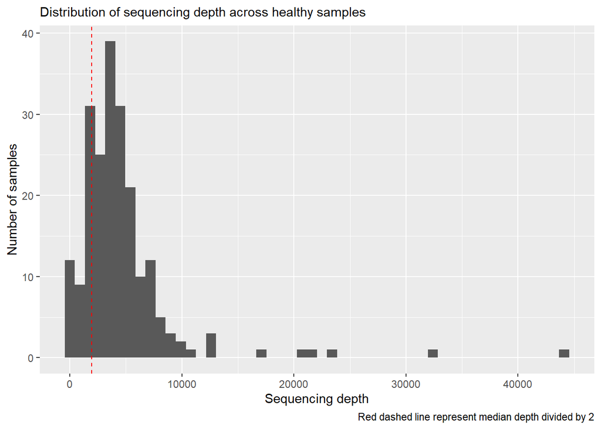

```r
tmp |>
  group_by(sample_id) |>
  summarise(depth = sum(count)) |>
  ggplot(aes(x = depth)) +
  geom_histogram(bins = 50) +
  geom_vline(aes(xintercept = median(depth)/2), color = "red", linetype = "dashed") +
  labs(x = "Sequencing depth", y = "Number of samples", caption = "Red dashed line represent median depth divided by 2",
       subtitle = "Distribution of sequencing depth across healthy samples")
```

We will rarefy at a depth of median(depth)/2; this is done in the chucks below, where we also filters out samples with depth < median(depth)/2.

```r
tmp_depth <- tmp |>
  group_by(sample_id) |>
  summarise(depth = sum(count), .groups = "drop")

min_depth <- median(tmp_depth$depth) / 2

samples_to_keep <- tmp_depth |>
  filter(depth >= min_depth) |>
  pull(sample_id)

cat("Removing", sum(tmp_depth$depth < min_depth), "samples below depth", round(min_depth))
```

```
Removing 39 samples below depth 1941
```

```r
tmp_rarefied <- tmp |>
    filter(sample_id %in% samples_to_keep) |>
    select(sample_id, taxon, count) |>
    pivot_wider(names_from = taxon, values_from = count) |>
    column_to_rownames("sample_id") |>
    rrarefy(sample = min_depth) |>
    as.data.frame() |>
    rownames_to_column("sample_id") |>
    pivot_longer(-sample_id, names_to = "taxon", values_to = "count") |>
    group_by(sample_id) |>
    mutate(rel_ab = count / sum(count)) |>
    ungroup()
```

```r
abundance <- tmp_rarefied |>
  select(sample_id, taxon, count) |>
  pivot_wider(names_from = taxon, values_from = count, values_fill = 0) |>
  column_to_rownames("sample_id")

abundance |> head() |> select(1:5)
```

```
           Acidovorax_caeni Acidovorax_delafieldii Acidovorax_wohlfahrtii
HMPv13_001                0                      0                      0
HMPv13_002                0                      0                      0
HMPv13_003                0                      0                      0
HMPv13_004                0                      0                      0
HMPv13_007                0                      0                      0
HMPv13_008                0                      0                      0
           Acinetobacter_guillouiae Acinetobacter_johnsonii
HMPv13_001                        0                       0
HMPv13_002                        0                       0
HMPv13_003                        0                       0
HMPv13_004                        0                       0
HMPv13_007                        0                       0
HMPv13_008                        0                       0
```

Since several samples have been removed after rarefaction, we also need to filter the metadata to keep only the samples for which we have abundance data after rarefaction.

```r
samples <- samples |>
  filter(sample_id %in% rownames(abundance))
```

Finally, we create a new `phyloseq` object using the subsetted abundance matrix, taxonomy dataset, and sample metadata.

```r
ps_hmpv13 <- phyloseq(
  otu_table(as.matrix(abundance), taxa_are_rows = FALSE),
  tax_table(as.matrix(taxonomy)),
  sample_data(samples)
)

ps_hmpv13
```

```
phyloseq-class experiment-level object
otu_table()   OTU Table:         [ 660 taxa and 171 samples ]
sample_data() Sample Data:       [ 171 samples by 5 sample variables ]
tax_table()   Taxonomy Table:    [ 660 taxa by 8 taxonomic ranks ]
```

### HMPv35 dataset

We visualize the structure of the `HMPv35` using the `phyloseq` function `sample_data` and `otu_table` in the chunks below.

```r
otu <- otu_table(HMPv35) |> as.data.frame()
sample_data <- sample_data(HMPv35) |> as_tibble()
tax_table <- tax_table(HMPv35) |> as.data.frame()
```

We first create a new column in the taxonomy dataset to represent the latest available taxonomic rank for each ASV, which will be used in the abundance matrix to aggregate the ASVs at the latest available taxonomic rank.

```r
taxonomy <-
  tax_table |>
  rownames_to_column(var = "ASV") |>
  mutate(
    taxon = case_when(
      !is.na(Species) ~ str_c(Genus, "_", Species),
      !is.na(Genus) ~ str_c("g_", Genus),
      !is.na(Family) ~ str_c("f_", Family),
      !is.na(Order) ~ str_c("o_", Order),
      !is.na(Class) ~ str_c("c_", Class),
      !is.na(Phylum) ~ str_c("p_", Phylum),
      TRUE ~ "Unclassified"),
    taxon_names = case_when(
      !is.na(Species) ~ str_c(Genus, " ", Species),
      !is.na(Genus) ~ str_c(Genus, " (g)"),
      !is.na(Family) ~ str_c(Family, " (f)"),
      !is.na(Order) ~ str_c(Order, " (o)"),
      !is.na(Class) ~ str_c(Class, " (c)"),
      !is.na(Phylum) ~ str_c(Phylum, " (p)"),
      TRUE ~ "Unclassified")
  )
```

We then aggregate the abundance matrix at the latest available taxonomic rank.

```r
abundance <-
  otu |>
  rownames_to_column(var = "ASV") |>
  left_join(taxonomy |> select(ASV, taxon), by = "ASV") |>
  group_by(taxon) |>
  summarise(across(-ASV, sum)) |>
  column_to_rownames(var = "taxon")
```

The taxonomy dataset is also aggregated to only contain one row per unique (latest available level) taxon.

```r
taxonomy <-
  taxonomy |>
  select(-ASV) |>
  group_by(taxon) |>
  summarise(across(everything(), ~ dplyr::first(na.omit(.x)))) |>
  ungroup() |>
  column_to_rownames(var = "taxon") |>
  clean_names()

taxonomy |> glimpse()
```

```
Rows: 1,179
Columns: 8
$ kingdom     <chr> "Bacteria", "Bacteria", "Bacteria", "Bacteria", "Bacteria"…
$ phylum      <chr> "Proteobacteria", "Proteobacteria", "Proteobacteria", "Pro…
$ class       <chr> "Betaproteobacteria", "Betaproteobacteria", "Gammaproteoba…
$ order       <chr> "Burkholderiales", "Burkholderiales", "Pseudomonadales", "…
$ family      <chr> "Comamonadaceae", "Comamonadaceae", "Moraxellaceae", "Mora…
$ genus       <chr> "Acidovorax", "Acidovorax", "Acinetobacter", "Acinetobacte…
$ species     <chr> "delafieldii", "facilis", "guillouiae", "johnsonii", "lwof…
$ taxon_names <chr> "Acidovorax delafieldii", "Acidovorax facilis", "Acinetoba…
```

The dataset pertains not only to stool microbiota data, but also to other microbiomes (oral, vaginal, etc.), but we will only focus on the stool microbiota data for the analyses. Therefore, we subset the abundance and sample metadata to only contain the samples pertaining to the stool microbiota. Also, we create a new column in the sample metadata to create a new sample ID that is more concise and easier to work with, while keeping the original sample names as well.

```r
samples <-
  sample_data |>
  filter(env == "Stool") |>
  clean_names() |>
  dplyr::rename(original_id = x_sample_id) |>
  select(original_id, env) |>
  arrange(original_id) |>
  mutate(
    sample_id = str_c("HMPv13_", str_pad(row_number(), width = 3, pad = "0")),
    subject_id = str_c("S", str_pad(ceiling(row_number() / 2), width = 3, pad = "0")),
    time = case_when(row_number() %% 2 == 1 ~ 1, TRUE ~ 2),
    sample_names = sample_id
  ) |>
  column_to_rownames(var = "sample_names")

samples |> glimpse()
```

```
Rows: 388
Columns: 5
$ original_id <fct> 1928.SRS011157.SRX020666.SRR044955, 1928.SRS011157.SRX0206…
$ env         <fct> Stool, Stool, Stool, Stool, Stool, Stool, Stool, Stool, St…
$ sample_id   <chr> "HMPv13_001", "HMPv13_002", "HMPv13_003", "HMPv13_004", "H…
$ subject_id  <chr> "S001", "S001", "S002", "S002", "S003", "S003", "S004", "S…
$ time        <dbl> 1, 2, 1, 2, 1, 2, 1, 2, 1, 2, 1, 2, 1, 2, 1, 2, 1, 2, 1, 2…
```

The abundance matrix is then subsetted to only contain the samples pertaining to the stool microbiota, and the column names are updated to reflect the new sample IDs.

```r
abundance <-
  abundance |>
  select(all_of(samples$original_id)) |>
  set_names(samples$sample_id)

abundance |> head() |> select(1:5)
```

```
                            HMPv13_001 HMPv13_002 HMPv13_003 HMPv13_004
Acidovorax_delafieldii               0          0          0          0
Acidovorax_facilis                   0          0          0          0
Acinetobacter_guillouiae             0          0          0          0
Acinetobacter_johnsonii              0          0          0          0
Acinetobacter_lwoffii                0          0          0          0
Acinetobacter_rhizosphaerae          0          0          0          0
                            HMPv13_005
Acidovorax_delafieldii               0
Acidovorax_facilis                   0
Acinetobacter_guillouiae             0
Acinetobacter_johnsonii              0
Acinetobacter_lwoffii                0
Acinetobacter_rhizosphaerae          0
```

```r
tmp <-
  abundance |>
  rownames_to_column("taxon") |>
  pivot_longer(-taxon, names_to = "sample_id", values_to = "count")
```

We show the distribution of sequencing depth across samples, to choose a rarefaction depth.

**Note**

Note that a classical rarefaction threshold would be to simply take the median depth, but in this case, we choose to take the median depth divided by 2, to keep more samples in the dataset.

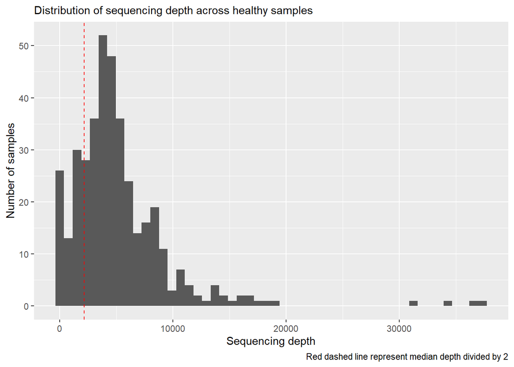

```r
tmp |>
  group_by(sample_id) |>
  summarise(depth = sum(count)) |>
  ggplot(aes(x = depth)) +
  geom_histogram(bins = 50) +
  geom_vline(aes(xintercept = median(depth)/2), color = "red", linetype = "dashed") +
  labs(x = "Sequencing depth", y = "Number of samples", caption = "Red dashed line represent median depth divided by 2",
       subtitle = "Distribution of sequencing depth across healthy samples")
```

We will rarefy at a depth of median(depth)/2; this is done in the chucks below, where we also filters out samples with depth < median(depth)/2.

```r
tmp_depth <- tmp |>
  group_by(sample_id) |>
  summarise(depth = sum(count), .groups = "drop")

min_depth <- median(tmp_depth$depth) / 2

samples_to_keep <- tmp_depth |>
  filter(depth >= min_depth) |>
  pull(sample_id)

cat("Removing", sum(tmp_depth$depth < min_depth), "samples below depth", round(min_depth))
```

```
Removing 80 samples below depth 2151
```

```r
tmp_rarefied <- tmp |>
    filter(sample_id %in% samples_to_keep) |>
    select(sample_id, taxon, count) |>
    pivot_wider(names_from = taxon, values_from = count) |>
    column_to_rownames("sample_id") |>
    rrarefy(sample = min_depth) |>
    as.data.frame() |>
    rownames_to_column("sample_id") |>
    pivot_longer(-sample_id, names_to = "taxon", values_to = "count") |>
    group_by(sample_id) |>
    mutate(rel_ab = count / sum(count)) |>
    ungroup()
```

```r
abundance <- tmp_rarefied |>
  select(sample_id, taxon, count) |>
  pivot_wider(names_from = taxon, values_from = count, values_fill = 0) |>
  column_to_rownames("sample_id")

abundance |> head() |> select(1:5)
```

```
           Acidovorax_delafieldii Acidovorax_facilis Acinetobacter_guillouiae
HMPv13_001                      0                  0                        0
HMPv13_002                      0                  0                        0
HMPv13_003                      0                  0                        0
HMPv13_004                      0                  0                        0
HMPv13_006                      0                  0                        0
HMPv13_007                      0                  0                        0
           Acinetobacter_johnsonii Acinetobacter_lwoffii
HMPv13_001                       0                     0
HMPv13_002                       0                     0
HMPv13_003                       0                     0
HMPv13_004                       0                     0
HMPv13_006                       0                     0
HMPv13_007                       0                     0
```

Since several samples have been removed after rarefaction, we also need to filter the metadata to keep only the samples for which we have abundance data after rarefaction.

```r
samples <- samples |> filter(sample_id %in% rownames(abundance))
```

Finally, we create a new `phyloseq` object using the subsetted abundance matrix, taxonomy dataset, and sample metadata.

```r
ps_hmpv35 <- phyloseq(
  otu_table(as.matrix(abundance), taxa_are_rows = FALSE),
  tax_table(as.matrix(taxonomy)),
  sample_data(samples)
)

ps_hmpv35
```

```
phyloseq-class experiment-level object
otu_table()   OTU Table:         [ 1179 taxa and 308 samples ]
sample_data() Sample Data:       [ 308 samples by 5 sample variables ]
tax_table()   Taxonomy Table:    [ 1179 taxa by 8 taxonomic ranks ]
```

## NIBIOHN and MORINAGA cohors datasets

Therefore, we have the following datasets at our disposal:

- `12866_2021_2215_MOESM7_ESM.xlsx`: This dataset contains the gut microbiota composition data for the NIBIOHN and MORINAGA cohorts, which can be used for the analyses. The dataset is in Excel format and contains two sheets, one for each cohort, with the abundance data for each ASV in each sample.

We import those datasets in the chunks below.

```r
data_NIBIOHN <- read_xlsx(file.path(data_dir(), "01-raw-data/05-NIBIOHN-MORINAGA", "12866_2021_2215_MOESM7_ESM.xlsx"), skip = 2, sheet = 1)
data_MORINAGA <- read_xlsx(file.path(data_dir(), "01-raw-data/05-NIBIOHN-MORINAGA", "12866_2021_2215_MOESM7_ESM.xlsx"), skip = 2, sheet = 2)
```

A first look at the dataset shows that the relative abundances are scaled from 0 to 100 instead of from 0 to 1, which is the standard for relative abundance data. We will check this below, and if this is the case, we will scale the abundances back to the 0-1 range by dividing the abundance values by 100.

```r
data_NIBIOHN |> column_to_rownames(var = names(data_NIBIOHN)[1]) |> rowSums()
```

```
N070860 N008998 N045463 N039640 N076437 N090317 N074345 N003836 N085422 N011145
  94.75   96.03   95.35   98.74   95.89   91.70   97.62   95.48   96.95   93.19
N020687 N069687 N012217 N045843 N087282 N004753 N049874 N069803 N034427 N064902
  93.86   97.94   97.12   92.44   92.13   92.03   94.18   97.17   96.61   96.24
N024068 N023486 N067533 N047144 N034854 N082114 N018972 N075890 N095889 N097585
  93.73   94.26   96.10   92.18   94.76   92.87   97.21   94.22   95.40   93.17
N016303 N038073 N088971 N059670 N037430 N099696 N067938 N077669 N025201 N093789
  94.69   98.87   93.52   92.45   97.18   95.22   97.23   97.52   96.11   96.30
N073106 N013679 N075386 N012257 N030632 N067820 N088083 N073026 N067950 N008550
  98.50   89.23   97.25   97.08   96.22   98.23   91.61   93.83   96.48   91.54
N040588 N058936 N064659 N077061 N018804 N060282 N056381 N048710 N050274 N083310
  96.04   96.67   97.86   96.90   90.32   95.50   97.81   92.56   96.87   94.42
N021032 N018011 N056955 N092119 N039861 N018616 N067241 N057538 N076830 N030226
  96.08   96.40   90.57   96.39   96.47   97.87   94.00   95.29   97.12   97.41
N042249 N004851 N066260 N008254 N067985 N060275 N016580 N064845 N089794 N073043
  98.07   91.57   94.49   96.16   91.07   85.27   90.41   92.11   98.66   93.19
N076543 N026604 N017776 N015656 N074493 N091819 N046036 N083047 N007672 N038188
  89.23   95.26   89.83   97.37   94.27   95.23   98.46   92.97   95.43   94.36
N090387 N014185 N066443 N064290 N067226 N054299 N040781 N061933 N081203 N026022
  96.13   96.36   97.42   94.89   98.39   98.93   94.70   93.72   93.79   94.85
N026538 N006603 N080878 N031214 N078768 N095905 N027751 N030993 N007877 N040013
  96.34   83.50   97.95   96.28   99.22   91.53   94.80   94.56   96.53   95.27
N091579 N036418 N040598 N092501 N022201 N007030 N010095 N080179 N081161 N059966
  99.26   94.98   95.47   94.73   97.85   91.08   95.23   96.01   96.48   94.64
N038748 N065914 N033869 N047592 N034483 N007674 N070358 N042500 N016394 N097279
  96.59   94.77   97.02   95.00   97.07   90.26   94.56   95.17   94.80   98.96
N077899 N019433 N089821 N038522 N042699 N000576 N059374 N031814 N075854 N056322
  91.83   93.58   95.38   96.07   98.81   97.20   96.11   94.94   97.36   94.94
N030074 N025720 N002868 N050831 N078629 N047117 N036492 N005657 N012517 N018473
  95.68   93.96   94.38   92.74   98.03   96.25   96.41   96.54   95.49   93.52
N076341 N022965 N063229 N026547 N003925 N046670 N086726 N022776 N038286 N092886
  94.07   93.15   97.80   92.31   96.78   92.40   97.02   97.07   94.45   99.73
N085471 N050774 N000885 N099222 N064502 N095367 N046599 N062816 N012899 N042735
  97.81   95.57   96.01   94.88   93.92   95.13   95.97   97.87   95.92   93.74
N077154 N020467 N008061 N051474 N013220 N090365 N038396 N056902 N011390 N070511
  91.83   93.87   92.29   96.60   92.26   97.54   93.94   94.66   99.08   87.60
N050458 N005799 N011797 N061180 N017381 N043084 N015910 N052174 N004781 N006660
  91.99   93.53   92.17   94.02   97.67   94.52   94.02   85.55   97.28   93.41
N046076 N088728 N025704 N022431 N053010 N018148 N030233 N064118 N055026 N060195
  93.35   95.81   93.86   94.60   96.75   89.29   92.16   95.51   94.83   95.42
```

[output cut: 137 more lines]

```
  97.21   95.50   98.48   94.48   92.80   99.28   97.77   96.24   97.66   96.98
N088716 N052439 N082289 N006651 N011370 N038737 N055613 N066505 N029541 N047452
  91.88   95.67   98.08   96.26   96.98   97.23   97.51   98.83   96.91   98.93
N058292 N024455 N056369 N038820 N073937 N002004 N017741 N048375 N051089 N007903
  97.93   98.44   95.51   94.41   96.68   99.12   98.06   96.34   98.19   98.24
N061982 N008023 N002403 N006861 N009953 N002148 N090638 N010345 N033013 N052945
  95.53   98.51   92.41   93.10   96.14   97.96   92.18   97.30   98.31   98.89
N034857 N097954 N037054 N069132 N002929 N022765 N024572 N028196 N010647 N040975
  94.33   98.08   97.84   97.36   97.76   98.42   97.62   98.03   95.50   97.56
N048818 N009571 N092710 N064314 N049685 N028108 N057354 N071267 N032171 N091966
  97.89   94.77   98.29   97.91   96.26   97.40   80.54   94.72   92.02   96.70
N004761 N019700 N096005 N005698 N044110 N080669 N030569 N079382 N072803 N024704
  97.13   96.59   96.51   96.82   93.40   89.58   98.16   99.48   97.56   95.99
N095007 N064726 N039362 N081625
  92.97   97.79   98.92   88.98
```

```r
data_MORINAGA |> column_to_rownames(var = names(data_MORINAGA)[1]) |> rowSums()
```

```
Nimo0001 Nimo0002 Nimo0003 Nimo0004 Nimo0005 Nimo0006 Nimo0009 Nimo0012
   96.58    97.78    95.46    94.96    95.34    93.92    91.42    88.60
Nimo0013 Nimo0017 Nimo0018 Nimo0020 Nimo0021 Nimo0023 Nimo0024 Nimo0025
   95.70    96.68    93.84    96.22    96.04    93.68    92.02    95.34
Nimo0026 Nimo0027 Nimo0030 Nimo0031 Nimo0033 Nimo0034 Nimo0035 Nimo0038
   99.06    97.34    98.26    93.70    95.44    95.58    94.80    96.84
Nimo0039 Nimo0040 Nimo0041 Nimo0042 Nimo0043 Nimo0044 Nimo0045 Nimo0046
   94.96    98.26    95.28    93.12    94.22    98.44    92.34    91.50
Nimo0047 Nimo0048 Nimo0049 Nimo0050 Nimo0051 Nimo0052 Nimo0053 Nimo0054
   95.58    90.26    93.12    93.54    95.56    91.34    92.06    96.14
Nimo0055 Nimo0057 Nimo0058 Nimo0059 Nimo0060 Nimo0061 Nimo0062 Nimo0064
   96.42    95.32    91.78    93.30    96.48    95.38    94.62    95.54
Nimo0065 Nimo0103 Nimo0104 Nimo0110 Nimo0111 Nimo0112 Nimo0114 Nimo0115
   93.00    96.94    94.72    98.22    92.58    95.70    95.56    93.76
Nimo0116 Nimo0117 Nimo0119 Nimo0121 Nimo1001 Nimo1002 Nimo1006 Nimo1010
   94.66    94.74    97.04    88.20    93.74    98.34    90.48    93.92
Nimo1023 Nimo1024 Nimo1027 Nimo1029 Nimo1038 Nimo1040 Nimo1042 Nimo1043
   98.26    93.08    93.48    96.90    96.30    97.84    96.04    89.50
Nimo1044 Nimo1045 Nimo1051 Nimo1059 Nimo1060 Nimo1061 Nimo1062 Nimo1063
   95.46    95.12    98.26    96.66    94.18    96.90    99.04    97.10
Nimo1064 Nimo1065 Nimo1066 Nimo1067 Nimo1069 Nimo1070 Nimo1071 Nimo1072
   96.06    89.06    94.60    93.18    97.42    95.86    98.06    97.88
Nimo1073 Nimo1074 Nimo1075 Nimo1076 Nimo1078 Nimo1080 Nimo1081 Nimo1082
   93.90    94.94    96.00    96.98    95.82    91.94    93.54    96.44
Nimo1083 Nimo1085 Nimo1086 Nimo1087 Nimo1089 Nimo1090 Nimo1091 Nimo1092
   94.56    95.76    95.52    97.94    83.68    89.00    93.84    95.02
Nimo1093 Nimo1094 Nimo1095 Nimo1097 Nimo1099 Nimo1100 Nimo1102 Nimo1103
   96.90    95.34    94.54    95.14    96.36    96.82    96.54    97.84
Nimo2002 Nimo2006 Nimo2007 Nimo2008 Nimo2009 Nimo2010 Nimo2011 Nimo2013
   93.80    98.44    95.34    93.28    94.38    92.04    97.58    97.18
Nimo2017 Nimo2019 Nimo2021 Nimo2023 Nimo2026 Nimo2027 Nimo2028 Nimo2029
   94.28    96.78    89.28    95.24    95.94    94.80    90.30    94.66
Nimo2030 Nimo2032 Nimo2033 Nimo2034 Nimo2037 Nimo2041 Nimo2042 Nimo2044
   95.28    96.26    93.74    95.72    93.08    96.98    97.12    97.78
Nimo2045 Nimo2048 Nimo2053 Nimo2059 Nimo2061 Nimo2066 Nimo2068 Nimo2069
   99.56    95.26    97.20    96.06    85.26    96.22    94.22    93.50
Nimo2075 Nimo2085 Nimo2086 Nimo2088 Nimo2093 Nimo2095 Nimo2096 Nimo2099
   96.20    95.84    93.12    98.12    89.56    95.44    92.24    97.96
Nimo2101 Nimo2102 Nimo2104 Nimo3001 Nimo3004 Nimo3007 Nimo3011 Nimo3012
   95.72    98.06    97.12    96.26    95.72    96.68    93.86    95.74
```

[output cut: 107 more lines]

```
   95.44    96.88    95.68    97.72    97.76    91.56    91.96    96.50
Nimo4885 Nimo4886 Nimo4887 Nimo4891 Nimo4892 Nimo4894 Nimo4895 Nimo4896
   95.94    96.00    95.34    95.90    96.12    95.64    94.98    97.38
Nimo4897 Nimo4899 Nimo4902 Nimo4906 Nimo4911 Nimo4912 Nimo4918 Nimo4919
   92.80    93.50    95.06    96.12    95.40    96.92    96.02    96.34
Nimo4920 Nimo4921 Nimo4924 Nimo4927 Nimo4928 Nimo4930 Nimo4933 Nimo4935
   96.36    95.80    96.46    95.90    95.12    98.26    98.12    95.56
Nimo4936 Nimo4937 Nimo4938 Nimo4939 Nimo4941 Nimo4951 Nimo4952 Nimo4953
   96.64    95.68    89.94    94.02    97.80    94.54    95.28    97.10
Nimo4957 Nimo4958 Nimo4960 Nimo4962 Nimo4963 Nimo4965 Nimo4969 Nimo4972
   95.32    96.74    94.48    94.96    97.44    93.22    96.30    96.22
Nimo4973 Nimo4981 Nimo4982 Nimo4984 Nimo4986 Nimo4987 Nimo4989 Nimo4992
   97.62    96.28    94.18    92.98    94.90    94.88    96.82    93.90
Nimo4997 Nimo4998
   96.92    96.14
```

Since the abundances are indeed scaled from 0 to 100, we will scale them back to the 0-1 range by dividing the abundance values by 100. We will also renormalize the abundances so that they sum to 1 for each sample, to ensure that the data is in the correct format for downstream analyses.

```r
renorm <- function(df) {
  df |>
    column_to_rownames(var = names(df)[1]) |>
    decostand(method = "total") |>
    rownames_to_column(var = names(df)[1])
}
```

```r
data_NIBIOHN <- renorm(data_NIBIOHN)
data_MORINAGA <- renorm(data_MORINAGA)
```

### NIBIOHN cohort dataset

We first create a taxonomy dataset for the NIBIOHN cohort dataset, which will be used to aggregate the abundance matrix at the latest available taxonomic rank.

```r
taxonomy <-
  tibble(full_names = names(data_NIBIOHN)[-1]) |>
  mutate(
    kingdom = "k_Bacteria",
    phylum  = str_extract(full_names, "(?<=D\\.1\\.\\.)[^_]+"),
    class   = str_extract(full_names, "(?<=D\\.2\\.\\.)[^_]+"),
    order   = str_extract(full_names, "(?<=D\\.3\\.\\.)[^_]+"),
    family  = str_extract(full_names, "(?<=D\\.4\\.\\.)[^_]+"),
    genus   = str_extract(full_names, "(?<=D\\.5\\.\\.)[^_]+"),
    species = str_extract(full_names, "(?<=D\\.6\\.\\.)[^_]+")
  ) |>
  mutate(
    taxon_names =
      case_when(
        !is.na(species) ~ str_c(genus, " ", species),
        !is.na(genus) ~ str_c(genus, " (g)"),
        !is.na(family) ~ str_c(family, " (f)"),
        !is.na(order) ~ str_c(order, " (o)"),
        !is.na(class) ~ str_c(class, " (c)"),
        !is.na(phylum) ~ str_c(phylum, " (p)"),
        TRUE ~ "Unclassified"),
    taxon = case_when(
      !is.na(species) ~ str_c(genus, "_", species),
      !is.na(genus) ~ str_c("g_", genus),
      !is.na(family) ~ str_c("f_", family),
      !is.na(order) ~ str_c("o_", order),
      !is.na(class) ~ str_c("c_", class),
      !is.na(phylum) ~ str_c("p_", phylum),
      TRUE ~ "Unclassified")
  )
```

We check if there are any duplicated taxa in the taxonomy dataset, which will affect the aggregation of the abundance matrix.

```r
taxonomy |> dplyr::count(taxon) |> filter(n > 1) |> gt(caption = "Duplicated taxa in the taxonomy dataset")
```

Duplicated taxa in the taxonomy dataset

| taxon | n |
| --- | --- |
| g_uncultured | 19 |
| g_uncultured.bacterium | 14 |
| g_uncultured.rumen.bacterium | 2 |

**Note**

The duplicates in the taxonomy dataset are exclusively uncultured bacteria at the genus level, for visualization purposes, these will be aggregated, but we will keep them separated for now.

We then aggregate the abundance matrix at the latest available taxonomic rank.

```r
abundance <-
  data_NIBIOHN |>
  column_to_rownames(var = names(data_NIBIOHN)[1]) |>
  t() |>
  as.data.frame() |>
  rownames_to_column(var = "full_names") |>
  left_join(taxonomy |> select(full_names, taxon), by = "full_names") |>
  group_by(taxon) |>
  summarise(across(-full_names, sum)) |>
  column_to_rownames(var = "taxon")
```

We also aggregate the taxonomy dataset to only contain one row per unique (latest available level) taxon. Note: All samples belong the the genus level.

```r
taxonomy <-
  taxonomy |>
  group_by(taxon) |>
  summarise(
    across(everything(), ~ dplyr::first(na.omit(.x)))
  ) |>
  ungroup() |>
  column_to_rownames(var = "taxon") |>
  select(-full_names)
```

**Warning**

Since no metadata is available for the NIBIOHN cohort dataset, we create a sample dataset with sample ID, and the samples’ type (stool samples in this case).

```r
samples <-
  tibble(
    sample_id = colnames(abundance),
    sample_type = "stool"
  ) |>
  column_to_rownames(var = "sample_id")
```

Finally, we create a new `phyloseq` object using the subsetted abundance matrix, taxonomy dataset, and sample metadata.

```r
ps_NIBIOHN <- phyloseq(
  otu_table(as.matrix(abundance), taxa_are_rows = TRUE),
  tax_table(as.matrix(taxonomy)),
  sample_data(samples)
)

ps_NIBIOHN
```

```
phyloseq-class experiment-level object
otu_table()   OTU Table:         [ 351 taxa and 954 samples ]
sample_data() Sample Data:       [ 954 samples by 1 sample variables ]
tax_table()   Taxonomy Table:    [ 351 taxa by 8 taxonomic ranks ]
```

### MORINAGA cohort dataset

We first create a taxonomy dataset for the MORINAGA cohort dataset, which will be used to aggregate the abundance matrix at the latest available taxonomic rank.

```r
taxonomy <-
  tibble(full_names = names(data_MORINAGA)[-1]) |>
  mutate(
    kingdom = "k_Bacteria",
    phylum  = str_extract(full_names, "(?<=D\\.1\\.\\.)[^_]+"),
    class   = str_extract(full_names, "(?<=D\\.2\\.\\.)[^_]+"),
    order   = str_extract(full_names, "(?<=D\\.3\\.\\.)[^_]+"),
    family  = str_extract(full_names, "(?<=D\\.4\\.\\.)[^_]+"),
    genus   = str_extract(full_names, "(?<=D\\.5\\.\\.)[^_]+"),
    species = str_extract(full_names, "(?<=D\\.6\\.\\.)[^_]+")
  ) |>
  mutate(
    taxon_names =
      case_when(
        !is.na(species) ~ str_c(genus, " ", species),
        !is.na(genus) ~ str_c(genus, " (g)"),
        !is.na(family) ~ str_c(family, " (f)"),
        !is.na(order) ~ str_c(order, " (o)"),
        !is.na(class) ~ str_c(class, " (c)"),
        !is.na(phylum) ~ str_c(phylum, " (p)"),
        TRUE ~ "Unclassified"),
    taxon = case_when(
      !is.na(species) ~ str_c(genus, "_", species),
      !is.na(genus) ~ str_c("g_", genus),
      !is.na(family) ~ str_c("f_", family),
      !is.na(order) ~ str_c("o_", order),
      !is.na(class) ~ str_c("c_", class),
      !is.na(phylum) ~ str_c("p_", phylum),
      TRUE ~ "Unclassified")
  )
```

We check if there are any duplicated taxa in the taxonomy dataset, which will affect the aggregation of the abundance matrix.

```r
taxonomy |> dplyr::count(taxon) |> filter(n > 1) |> gt(caption = "Duplicated taxa in the taxonomy dataset")
```

Duplicated taxa in the taxonomy dataset

| taxon | n |
| --- | --- |
| g_uncultured | 15 |
| g_uncultured bacterium | 12 |
| g_uncultured rumen bacterium | 2 |

**Note**

The duplicates in the taxonomy dataset are exclusively uncultured bacteria at the genus level, for visualization purposes, these will be aggregated, but we will keep them separated for now.

We then aggregate the abundance matrix at the latest available taxonomic rank.

```r
abundance <-
  data_MORINAGA |>
  column_to_rownames(var = names(data_MORINAGA)[1]) |>
  t() |>
  as.data.frame() |>
  rownames_to_column(var = "full_names") |>
  left_join(taxonomy |> select(full_names, taxon), by = "full_names") |>
  group_by(taxon) |>
  summarise(across(-full_names, sum)) |>
  column_to_rownames(var = "taxon")
```

We also aggregate the taxonomy dataset to only contain one row per unique (latest available level) taxon. Note: All samples belong the the genus level.

```r
taxonomy <-
  taxonomy |>
  group_by(taxon) |>
  summarise(
    across(everything(), ~ dplyr::first(na.omit(.x)))
  ) |>
  ungroup() |>
  column_to_rownames(var = "taxon") |>
  select(-full_names)
```

**Warning**

Since no metadata is available for the MORINAGA cohort dataset, we create a sample dataset with sample ID, and the samples’ type (stool samples in this case).

```r
samples <-
  tibble(
    sample_id = colnames(abundance),
    sample_type = "stool"
  ) |>
  column_to_rownames(var = "sample_id")
```

Finally, we create a new `phyloseq` object using the subsetted abundance matrix, taxonomy dataset, and sample metadata.

```r
ps_MORINAGA <- phyloseq(
  otu_table(as.matrix(abundance), taxa_are_rows = TRUE),
  tax_table(as.matrix(taxonomy)),
  sample_data(samples)
)

ps_MORINAGA
```

```
phyloseq-class experiment-level object
otu_table()   OTU Table:         [ 281 taxa and 642 samples ]
sample_data() Sample Data:       [ 642 samples by 1 sample variables ]
tax_table()   Taxonomy Table:    [ 281 taxa by 8 taxonomic ranks ]
```

## Dietary intervention cohort datasets

The study protocol involved fecal samples collected at different times, with control samples (C) and test samples (T). Specifically, fecal samples were collected at baseline (T1 and C1), after 2 weeks (T2 and C2), and after 4 weeks (T3 and C3) of the dietary intervention periods.

For the analyses, we have the following dataset at our disposal:

- `nutrients-1853911-supplementary_tables.xlsx`: This dataset contains stool microbiota composition data for this cohort. The dataset is in Excel format and contains several sheets, with the abundance data for each ASV in each sample.

```r
data <- read_xlsx(file.path(data_dir(), "01-raw-data/06-DIET", "nutrients-1853911-supplementary_tables.xlsx"), sheet = 6)
```

Since no metadata is available for this cohort dataset, we create a sample dataset with sample ID, the samples’ type (stool samples in this case), and the group and time point information for each sample (C1, C2, C3, T1, T2, T3).

```r
samples <-
  tibble(
    sample_id = names(data)[-1],
    sample_type = "stool",
    group = ifelse(str_detect(sample_id, "C"), "control", "test"),
    subgroup = case_when(
      str_detect(sample_id, "C1|T1") ~ "baseline",
      str_detect(sample_id, "C2|T2") ~ "2_weeks",
      str_detect(sample_id, "C3|T3") ~ "4_weeks",
      TRUE ~ NA_character_
    ),
    time = case_when(
      str_detect(sample_id, "C1|T1") ~ 1,
      str_detect(sample_id, "C2|T2") ~ 2,
      str_detect(sample_id, "C3|T3") ~ 3,
      TRUE ~ NA_real_
    )
  ) |>
  column_to_rownames(var = "sample_id")
```

The abundance matrix is created by setting the first column as row names.

```r
abundance <- data |> column_to_rownames(var = names(data)[1]) |> t() |> as.data.frame()
```

We check if the samples (rows) sum to 1, which is the standard for relative abundance data. If not, we will scale the abundances so that they sum to 1 for each sample.

```r
abundance |> rowSums()
```

```
01_C1 01_C2 01_C3 01_T1 01_T2 01_T3 02_T1 02_T2 02_T3 02_C1 02_C2 02_C3 03_C1
    1     1     1     1     1     1     1     1     1     1     1     1     1
03_C2 03_C3 03_T1 03_T2 03_T3 04_T1 04_T2 04_T3 04_C1 04_C2 04_C3 05_C1 05_C2
    1     1     1     1     1     1     1     1     1     1     1     1     1
05_C3 05_T1 05_T2 05_T3 06_C1 06_C2 06_C3 06_T1 06_T2 06_T3 07_T1 07_T2 07_T3
    1     1     1     1     1     1     1     1     1     1     1     1     1
07_C1 07_C2 07_C3 09_C1 09_C2 09_C3 09_T1 09_T2 09_T3 10_C1 10_C2 10_C3 10_T1
    1     1     1     1     1     1     1     1     1     1     1     1     1
10_T2 10_T3 12_C1 12_C2 12_C3 12_T1 12_T2 12_T3 14_C1 14_C2 14_C3 14_T1 14_T2
    1     1     1     1     1     1     1     1     1     1     1     1     1
14_T3 15_T1 15_T2 15_T3 15_C1 15_C2 15_C3 16_T1 16_T2 16_T3 16_C1 16_C2 16_C3
    1     1     1     1     1     1     1     1     1     1     1     1     1
17_C1 17_C2 17_C3 17_T1 17_T2 17_T3 19_C1 19_C2 19_C3 19_T1 19_T2 19_T3 20_T1
    1     1     1     1     1     1     1     1     1     1     1     1     1
20_T2 20_T3 20_C1 20_C2 20_C3 21_T1 21_T2 21_T3 21_C1 21_C2 21_C3 23_T1 23_T2
    1     1     1     1     1     1     1     1     1     1     1     1     1
23_T3 23_C1 23_C2 23_C3 24_T1 24_T2 24_T3 24_C1 24_C2 24_C3
    1     1     1     1     1     1     1     1     1     1
```

Since the samples sum to 1, we can proceed by creating the taxonomy annotation dataframe. After manually looking at the taxonomy annotation, we see that all taxa are annotated at the genus level.

```r
taxonomy <-
  tibble(
    full_names = colnames(abundance),
    kingdom = "k_Bacteria",
    phylum = NA,
    class = NA,
    order = NA,
    family = NA,
    genus = full_names,
    species = NA,
    taxon_names = str_c(full_names, " (g)"),
    taxon = str_c("g_", full_names)
  ) |>
  column_to_rownames(var = "full_names")
```

Finally, we create a new `phyloseq` object using the subsetted abundance matrix, taxonomy dataset, and sample metadata.

```r
ps_DIET <- phyloseq(
  otu_table(as.matrix(abundance), taxa_are_rows = FALSE),
  tax_table(as.matrix(taxonomy)),
  sample_data(samples)
)
```

# Supplementary cohorts

## IBD dataset from Fransoza et al. (2019)

### Importing raw data

```r
data <-
  read_xlsx(file.path(data_dir(), "01-raw-data/07-IBD-Franzosa", "41564_2018_306_MOESM6_ESM.xlsx"), skip = 1) |>
  clean_names() |>
  column_to_rownames("number_feature_sample")
```

### Constructing metadata table

```r
metadata <-
  data |>
  t() |>
  as_tibble(rownames = "uid") |>
  select(1:9) |>
  column_to_rownames("uid") |>
  clean_names()

metadata |> glimpse()
```

```
Rows: 220
Columns: 8
$ sra_metagenome_name <chr> "G36386", "G48796", "G48780", "G36390", "G36356", …
$ age                 <chr> "38", "50", "41", "51", "68", "67", "59", "52", "5…
$ diagnosis           <chr> "CD", "CD", "CD", "CD", "CD", "CD", "CD", "CD", "C…
$ fecal_calprotectin  <chr> "207.4844286", NA, "218.33451690000001", NA, "20.1…
$ antibiotic          <chr> "No", "No", "No", "No", "No", "Yes", "No", "No", "…
$ immunosuppressant   <chr> "Yes", "No", "Yes", "No", "No", "Yes", "No", "Yes"…
$ mesalamine          <chr> "No", "Yes", "No", "Yes", "No", "No", "Yes", "No",…
$ steroids            <chr> "No", "No", "No", "No", "No", "Yes", "No", "No", "…
```

We document below the number of samples per diagnosis group in the IBD dataset from Fransoza et al. (2019).

```r
metadata |>
  group_by(diagnosis) |>
  summarise(n = n()) |>
  ungroup() |>
  gt(caption = "Number of samples per diagnosis group in the IBD dataset from Fransoza et al. (2019)")
```

Number of samples per diagnosis group in the IBD dataset from Fransoza et al. (2019)

| diagnosis | n |
| --- | --- |
| CD | 88 |
| Control | 56 |
| UC | 76 |

### Constructing abundance table

```r
abundance <-
  data |>
  as_tibble(rownames = "uid") |>
  slice_tail(n = 201) |>
  column_to_rownames("uid") |>
  mutate(across(everything(), as.numeric)) |>
  t()
```

### Constructing taxonomy table based on abudance data

Since no taxonomy table is provided in the original dataset, we will construct a taxonomy table based on the abundance data.

```r
taxonomy <-
  tibble(
    taxon = colnames(abundance),
    kingdom = "k_Bacteria",
    phylum = NA,
    class = NA,
    order = NA,
    family = NA,
    genus = word(taxon, 1, sep = "_"),
    species = word(taxon, 2, sep = "_")
  ) |>
  mutate(
    species = case_when(
      species == "sp" ~ NA_character_,
      TRUE ~ species
    )
  ) |>
  column_to_rownames("taxon")
```

### Creating a `phyloseq` object and saving it for later use

```r
ps_ibd_franzosa <-
  phyloseq(
  otu_table(as.matrix(abundance), taxa_are_rows = FALSE),
  sample_data(metadata),
  tax_table(as.matrix(taxonomy))
)

ps_ibd_franzosa
```

```
phyloseq-class experiment-level object
otu_table()   OTU Table:         [ 201 taxa and 220 samples ]
sample_data() Sample Data:       [ 220 samples by 8 sample variables ]
tax_table()   Taxonomy Table:    [ 201 taxa by 7 taxonomic ranks ]
```

## CRC dataset from Zeller et al. (2014)

### Importing raw data

```r
data <- curatedMetagenomicData("ZellerG_2014.relative_abundance", dryrun = FALSE, counts = TRUE)[[1]]
```

### Extracting abundance data from the MAE object

The abundance matrix is a count matrix because we set `counts = TRUE` in the `curatedMetagenomicData` function.

```r
abundance <- assay(data, "relative_abundance")
```

### Extracting taxonomy data from the MAE object

```r
taxonomy <-
  data |>
  rowLinks() |>
  as_tibble() |>
  clean_names() |>
  select(taxon_name = node_lab) |>
  separate(taxon_name, into = c("kingdom", "phylum", "class", "order", "family", "genus", "species"), sep = "\\|") |>
  mutate(taxon = str_remove(species, "s__")) |>
  column_to_rownames("taxon")
```

We use taxonomy rownames and replace rownames in the abundance matrix.

```r
abundance <- abundance |> magrittr::set_rownames(rownames(taxonomy))
```

### Extracting metadata from the MAE object

```r
metadata <-
  data |>
  colData() |>
  as_tibble(rownames = "uid") |>
  clean_names() |>
  column_to_rownames("uid")

metadata |> glimpse()
```

```
Rows: 156
Columns: 24
$ study_name          <chr> "ZellerG_2014", "ZellerG_2014", "ZellerG_2014", "Z…
$ subject_id          <chr> "FR-726", "FR-060", "FR-568", "FR-828", "FR-027", …
$ body_site           <chr> "stool", "stool", "stool", "stool", "stool", "stoo…
$ study_condition     <chr> "control", "control", "control", "CRC", "control",…
$ disease             <chr> "healthy", "healthy", "healthy", "CRC", "healthy",…
$ age                 <int> 72, 53, 35, 67, 74, 29, 61, 65, 58, 63, 77, 62, 63…
$ age_category        <chr> "senior", "adult", "adult", "senior", "senior", "a…
$ gender              <chr> "female", "male", "male", "male", "male", "male", …
$ country             <chr> "FRA", "FRA", "FRA", "FRA", "FRA", "FRA", "FRA", "…
$ non_westernized     <chr> "no", "no", "no", "no", "no", "no", "no", "no", "n…
$ sequencing_platform <chr> "IlluminaHiSeq", "IlluminaHiSeq", "IlluminaHiSeq",…
$ dna_extraction_kit  <chr> "Gnome", "Gnome", "Gnome", "Gnome", "Gnome", "Gnom…
$ pmid                <chr> "25432777", "25432777", "25432777", "25432777", "2…
$ number_reads        <int> 76003628, 47190574, 87631061, 10574044, 73567419, …
$ number_bases        <dbl> 6512170482, 3298640533, 7846466205, 907920835, 619…
$ minimum_read_length <int> 45, 45, 45, 1, 1, 45, 1, 1, 45, 1, 45, 45, 1, 45, …
$ median_read_length  <int> 91, 69, 94, 90, 89, 91, 89, 89, 85, 89, 90, 91, 86…
$ ncbi_accession      <chr> "ERR480457;ERR480456;ERR480455;ERR480454;ERR478959…
$ curator             <chr> "Paolo_Manghi", "Paolo_Manghi", "Paolo_Manghi", "P…
$ bmi                 <dbl> 25, 32, 23, 28, 27, 24, 23, 24, 24, NA, 22, 21, 26…
$ disease_subtype     <chr> NA, NA, NA, "carcinoma", NA, NA, NA, NA, "carcinom…
$ tnm                 <chr> NA, NA, NA, "t1n0m0", NA, NA, NA, NA, "t3n1m1", NA…
$ fobt                <chr> "no", "no", "no", "yes", "yes", "no", "no", "no", …
$ ajcc                <chr> NA, NA, NA, "i", NA, NA, NA, NA, "iv", NA, NA, NA,…
```

We document below the number of samples per diagnosis group in the CRC dataset from Zeller et al. (2014).

```r
metadata |>
  group_by(disease, study_condition) |>
  summarise(n = n()) |>
  ungroup() |>
  gt(caption = "Number of samples per diagnosis group in the CRC dataset from Zeller et al. (2014)")
```

Number of samples per diagnosis group in the CRC dataset from Zeller et al. (2014)

| disease | study_condition | n |
| --- | --- | --- |
| CRC | CRC | 53 |
| adenoma | adenoma | 42 |
| healthy | control | 61 |

### Creating a `phyloseq` object and saving it for later use

```r
ps_crc_zeller <-
  phyloseq(
    otu_table(as.matrix(abundance), taxa_are_rows = TRUE),
    sample_data(metadata),
    tax_table(as.matrix(taxonomy))
  )

ps_crc_zeller
```

```
phyloseq-class experiment-level object
otu_table()   OTU Table:         [ 652 taxa and 156 samples ]
sample_data() Sample Data:       [ 156 samples by 24 sample variables ]
tax_table()   Taxonomy Table:    [ 652 taxa by 7 taxonomic ranks ]
```

## CDI dataset from Vincent et al. (2016)

### Importing raw dataset

```r
data <- curatedMetagenomicData("VincentC_2016.relative_abundance", dryrun = FALSE, counts = TRUE)[[1]]
```

### Extracting abundance data from the MAE object

```r
abundance <- assay(data, "relative_abundance")
```

### Extracting taxonomy data from the MAE object

```r
taxonomy <-
  data |>
  rowLinks() |>
  as_tibble() |>
  clean_names() |>
  select(taxon_name = node_lab) |>
  separate(taxon_name, into = c("kingdom", "phylum", "class", "order", "family", "genus", "species"), sep = "\\|") |>
  mutate(taxon = str_remove(species, "s__")) |>
  column_to_rownames("taxon")
```

We use taxonomy rownames and replace rownames in the abundance matrix.

```r
abundance <- abundance |> magrittr::set_rownames(rownames(taxonomy))
```

### Extracting metadata from the MAE object

```r
metadata <-
  data |>
  colData() |>
  as_tibble(rownames = "uid") |>
  clean_names() |>
  column_to_rownames("uid")

metadata |> glimpse()
```

```
Rows: 229
Columns: 23
$ study_name                 <chr> "VincentC_2016", "VincentC_2016", "VincentC…
$ subject_id                 <chr> "MM001", "MM001", "MM001", "MM001", "MM002"…
$ body_site                  <chr> "stool", "stool", "stool", "stool", "stool"…
$ antibiotics_current_use    <chr> "yes", "yes", "yes", "yes", "yes", "yes", "…
$ study_condition            <chr> "control", "control", "control", "control",…
$ disease                    <chr> "healthy", "healthy", "healthy", "healthy",…
$ age                        <int> 80, 80, 80, 80, 79, 79, 75, 75, 81, 81, 66,…
$ age_category               <chr> "senior", "senior", "senior", "senior", "se…
$ gender                     <chr> "female", "female", "female", "female", "ma…
$ country                    <chr> "CAN", "CAN", "CAN", "CAN", "CAN", "CAN", "…
$ non_westernized            <chr> "no", "no", "no", "no", "no", "no", "no", "…
$ sequencing_platform        <chr> "IlluminaHiSeq", "IlluminaHiSeq", "Illumina…
$ dna_extraction_kit         <chr> "QIAamp", "QIAamp", "QIAamp", "QIAamp", "QI…
$ pmid                       <chr> "26975510", "26975510", "26975510", "269755…
$ number_reads               <int> 4215921, 26930197, 27625587, 12638949, 1634…
$ number_bases               <dbl> 632388150, 4039529550, 4143838050, 18958423…
$ minimum_read_length        <int> 150, 150, 150, 150, 150, 150, 150, 150, 150…
$ median_read_length         <int> 150, 150, 150, 150, 150, 150, 150, 150, 150…
$ ncbi_accession             <chr> "SRR2565533", "SRR2565534", "SRR2565950", "…
$ treatment                  <chr> "no", "opioids;laxatives", "NSAID;opioids;l…
$ curator                    <chr> "Paolo_Manghi;Andrea_Zen", "Paolo_Manghi;An…
$ days_from_first_collection <int> 0, 6, 11, 18, 0, 6, 0, 6, 0, 4, 0, 3, 4, 0,…
$ antibiotics_family         <chr> "cephalosporins", "cephalosporins", "cephal…
```

We document below the number of samples per diagnosis group in the CDI dataset from Vincent et al. (2016).

```r
metadata |>
  group_by(disease, study_condition) |>
  summarise(n = n()) |>
  ungroup() |>
  gt(caption = "Number of samples per diagnosis group in the CDI dataset from Vincent et al. (2016)")
```

Number of samples per diagnosis group in the CDI dataset from Vincent et al. (2016)

| disease | study_condition | n |
| --- | --- | --- |
| CDI | CDI | 14 |
| CDI;cellulitis | CDI | 2 |
| CDI;osteoarthritis | CDI | 1 |
| CDI;pneumonia | CDI | 15 |
| CDI;ureteralstone | CDI | 1 |
| abdominalhernia | control | 2 |
| cellulitis | control | 6 |
| gangrene | control | 1 |
| healthy | control | 182 |
| osteoarthritis | control | 1 |
| pneumonia | control | 4 |

### Creating a `phyloseq` object and saving it for later use

```r
ps_cdi_vincent <-
  phyloseq(
    otu_table(as.matrix(abundance), taxa_are_rows = TRUE),
    sample_data(metadata),
    tax_table(as.matrix(taxonomy))
  )

ps_cdi_vincent
```

```
phyloseq-class experiment-level object
otu_table()   OTU Table:         [ 616 taxa and 229 samples ]
sample_data() Sample Data:       [ 229 samples by 23 sample variables ]
tax_table()   Taxonomy Table:    [ 616 taxa by 7 taxonomic ranks ]
```

## CDI dataset from Ianiro et al. (2022)

### Importing raw dataset

```r
data <- curatedMetagenomicData("IaniroG_2022.relative_abundance", dryrun = FALSE, counts = TRUE)[[1]]
```

### Extracting abundance data from the MAE object

```r
abundance <- assay(data, "relative_abundance")
```

### Extracting taxonomy data from the MAE object

```r
taxonomy <-
  data |>
  rowLinks() |>
  as_tibble() |>
  clean_names() |>
  select(taxon_name = node_lab) |>
  separate(taxon_name, into = c("kingdom", "phylum", "class", "order", "family", "genus", "species"), sep = "\\|") |>
  mutate(taxon = str_remove(species, "s__")) |>
  column_to_rownames("taxon")
```

We use taxonomy rownames and replace rownames in the abundance matrix.

```r
abundance <- abundance |> magrittr::set_rownames(rownames(taxonomy))
```

### Extracting metadata from the MAE object

```r
metadata <-
  data |>
  colData() |>
  as_tibble(rownames = "uid") |>
  clean_names() |>
  column_to_rownames("uid")

metadata |> glimpse()
```

```
Rows: 165
Columns: 22
$ study_name                 <chr> "IaniroG_2022", "IaniroG_2022", "IaniroG_20…
$ subject_id                 <chr> "FATHER", "UNIVERSAL DONOR", "FATHER", "UNI…
$ body_site                  <chr> "stool", "stool", "stool", "stool", "stool"…
$ antibiotics_current_use    <chr> "no", "no", "no", "no", "no", "no", "yes", …
$ study_condition            <chr> "donor", "donor", "donor", "donor", "donor"…
$ disease                    <chr> "healthy", "healthy", "healthy", "healthy",…
$ age                        <int> NA, NA, NA, NA, NA, NA, NA, NA, NA, NA, NA,…
$ age_category               <chr> "adult", "adult", "adult", "adult", "adult"…
$ country                    <chr> "ITA", "ITA", "ITA", "ITA", "ITA", "ITA", "…
$ location                   <chr> "Rome", "Rome", "Rome", "Rome", "Rome", "Ro…
$ non_westernized            <chr> "no", "no", "no", "no", "no", "no", "no", "…
$ pmid                       <chr> "36109637", "36109637", "36109637", "361096…
$ number_reads               <int> 61964376, 82779959, 24951969, 38466555, 448…
$ number_bases               <dbl> 9286688342, 12421677051, 3742683652, 576486…
$ minimum_read_length        <int> 75, 75, 75, 75, 75, 75, 75, 75, 75, 75, 75,…
$ median_read_length         <int> 151, 151, 151, 151, 151, 151, 151, 151, 151…
$ ncbi_accession             <chr> "ERR9707213", "ERR9708128", "ERR9707186", "…
$ curator                    <chr> "Paolo_Manghi;Michal_Puncochar", "Paolo_Man…
$ days_from_first_collection <int> NA, NA, NA, NA, NA, NA, 0, 7, 15, 30, 90, 0…
$ subcohort                  <chr> "IaniroG_2022_IBD", "IaniroG_2022_IBD", "Ia…
$ fmt_role                   <chr> "donor", "donor", "donor", "donor", "donor"…
$ fmt_id                     <chr> "IaniroG_2020_2022_294", "IaniroG_2020_2022…
```

```r
metadata |>
  group_by(disease, study_condition) |>
  summarise(n = n()) |>
  ungroup() |>
  gt(caption = "Number of samples per diagnosis group in the Ianiro et al. (2022) dataset")
```

Number of samples per diagnosis group in the Ianiro et al. (2022) dataset

| disease | study_condition | n |
| --- | --- | --- |
| CDI | CDI | 20 |
| CDI | FMT | 74 |
| IBD | FMT | 3 |
| IBD | IBD | 3 |
| MDRB | FMT | 6 |
| MDRB | MDRB | 5 |
| TKI_dependent_diarrhoea | FMT | 26 |
| TKI_dependent_diarrhoea | TKI_dependent_diarrhoea | 16 |
| healthy | control | 3 |
| healthy | donor | 9 |

### Creating a `phyloseq` object and saving it for later use

```r
ps_cdi_ianiro <-
  phyloseq(
    otu_table(as.matrix(abundance), taxa_are_rows = TRUE),
    sample_data(metadata),
    tax_table(as.matrix(taxonomy))
  )

ps_cdi_ianiro
```

```
phyloseq-class experiment-level object
otu_table()   OTU Table:         [ 637 taxa and 165 samples ]
sample_data() Sample Data:       [ 165 samples by 22 sample variables ]
tax_table()   Taxonomy Table:    [ 637 taxa by 7 taxonomic ranks ]
```

# MAE integration

In this section, we will integrate the different cohorts datasets using the `MultiAssayExperiment` (MAE) class from Bioconductor. This class provides a convenient way to manage and analyze the cohorts.

We first transform the datasets into `SummarizedExperiment` objects.

```r
# Diseased cohorts

se_ibd <- phyloseq_to_SE(ps_ibd)
se_ibs <- phyloseq_to_SE(ps_ibs)
se_cdi <- phyloseq_to_SE(ps_cdi)
se_crc <- phyloseq_to_SE(ps_crc)

# Alternative dysbiotic cohorts

se_ibd_alt <- phyloseq_to_SE(ps_ibd_alt)
se_ibs_alt <- phyloseq_to_SE(ps_ibs_alt)
se_cdi_alt <- phyloseq_to_SE(ps_cdi_alt)
se_crc_alt <- phyloseq_to_SE(ps_crc_alt)

# Healthy cohorts

se_hmpv13 <- phyloseq_to_SE(ps_hmpv13)
se_hmpv35 <- phyloseq_to_SE(ps_hmpv35)
se_NIBIOHN <- phyloseq_to_SE(ps_NIBIOHN)
se_MORINAGA <- phyloseq_to_SE(ps_MORINAGA)
se_DIET <- phyloseq_to_SE(ps_DIET)

# Supplementary cohorts

se_ibd_franzosa <- phyloseq_to_SE(ps_ibd_franzosa)
se_cdi_ianiro <- phyloseq_to_SE(ps_cdi_ianiro)
se_cdi_vincent <- phyloseq_to_SE(ps_cdi_vincent)
se_crc_zeller <- phyloseq_to_SE(ps_crc_zeller)
```

We create below a `MultiAssayExperiment` object that contains all the `SummarizedExperiment` objects.

```r
# Create a list of the SummarizedExperiment objects

se_list <- list(
  IBD = se_ibd,
  IBS = se_ibs,
  CDI = se_cdi,
  CRC = se_crc,
  IBD_ALT = se_ibd_alt,
  IBS_ALT = se_ibs_alt,
  CDI_ALT = se_cdi_alt,
  CRC_ALT = se_crc_alt,
  IBD_FRANZOSA = se_ibd_franzosa,
  CDI_IANIRO = se_cdi_ianiro,
  CDI_VINCENT = se_cdi_vincent,
  CRC_ZELLER = se_crc_zeller,
  HMPV13 = se_hmpv13,
  HMPV35 = se_hmpv35,
  NIBIOHN = se_NIBIOHN,
  MORINAGA = se_MORINAGA,
  DIET = se_DIET

)
```

```r
# Create the MultiAssayExperiment object

mae <- MultiAssayExperiment(experiments = se_list)

mae
```

```
A MultiAssayExperiment object of 17 listed
 experiments with user-defined names and respective classes.
 Containing an ExperimentList class object of length 17:
 [1] IBD: SummarizedExperiment with 432 rows and 1630 columns
 [2] IBS: SummarizedExperiment with 598 rows and 72 columns
 [3] CDI: SummarizedExperiment with 874 rows and 366 columns
 [4] CRC: SummarizedExperiment with 837 rows and 575 columns
 [5] IBD_ALT: SummarizedExperiment with 42871 rows and 382 columns
 [6] IBS_ALT: SummarizedExperiment with 11513 rows and 444 columns
 [7] CDI_ALT: SummarizedExperiment with 4619 rows and 534 columns
 [8] CRC_ALT: SummarizedExperiment with 57702 rows and 347 columns
 [9] IBD_FRANZOSA: SummarizedExperiment with 201 rows and 220 columns
 [10] CDI_IANIRO: SummarizedExperiment with 637 rows and 165 columns
 [11] CDI_VINCENT: SummarizedExperiment with 616 rows and 229 columns
 [12] CRC_ZELLER: SummarizedExperiment with 652 rows and 156 columns
 [13] HMPV13: SummarizedExperiment with 660 rows and 171 columns
 [14] HMPV35: SummarizedExperiment with 1179 rows and 308 columns
 [15] NIBIOHN: SummarizedExperiment with 351 rows and 954 columns
 [16] MORINAGA: SummarizedExperiment with 281 rows and 642 columns
 [17] DIET: SummarizedExperiment with 193 rows and 114 columns
Functionality:
 experiments() - obtain the ExperimentList instance
 colData() - the primary/phenotype DataFrame
 sampleMap() - the sample coordination DataFrame
 `$`, `[`, `[[` - extract colData columns, subset, or experiment
 *Format() - convert into a long or wide DataFrame
 assays() - convert ExperimentList to a SimpleList of matrices
 exportClass() - save data to flat files
```

# Saving the preprocessed MAE

We save the preprocessed MAE object as an RDS file for later use in the downstream analyses.

```r
saveRDS(mae, file.path(data_dir(), "02-processed-data", str_c("MAE_processed_", today() |> str_remove_all("-"), ".rds")))
```